# Flow-Based Generative Models: When Probability Flows Like a Fluid

How the 18th-century mathematics of Euler made generative models faster to sample and simpler to train.

fluid mechanics

continuity equation

optimal transport

diffusion models

normalizing flows

flow models

flow matching

conditional flow matching

probability-flow ODE

The normalizing flows of Tabak, the neural ODEs of Chen, and the flow matching of Lipman, built from first principles.

Author

Aja S.

Published

October 2026

This series — Continuous-Time Generative Models

| Part | Date | Title |
| --- | --- | --- |
| Part 1 | Aug 10, 2026 | Itô's Lemma: From Black-Scholes to Diffusion Models |
| Part 2 | Sep 10, 2026 | The Variational Bound (ELBO) and Score Matching: Two Routes to Denoising Diffusion |
| Part 3 | Oct 16, 2026 | SDE-Based Generative Models: The Unification of the Variational Bound and Score Matching |
| Part 4 | Oct 22, 2026 | Flow-Based Generative Models: When Probability Flows Like a Fluid — you are here |
| Part 5 | Oct 29, 2026 | Rectified Flow and Optimal Transport: Straight Paths from Noise to Data |

A reference such as P2:§3.8 points to Section 3.8 of post 2.

This is post #4 in the series **Continuous-Time Generative Models**. It builds directly on post #3, which derived the probability-flow ODE, the deterministic counterpart of the reverse-time SDE.

Diffusion models generate data by reversing a gradual transformation from data to noise. They learn the score of the intermediate distributions and use it to construct either a reverse-time stochastic differential equation (SDE) or a deterministic probability-flow ordinary differential equation (ODE). The score determines the drift of the reverse-time SDE and, together with the forward dynamics, the velocity field of the probability-flow ODE. The SDE combines this drift with stochastic noise, whereas the ODE generates samples using only its deterministic velocity field.

This raises a natural question: if generation with the probability-flow ODE requires only a velocity field, can we learn that field directly, by regression, without learning the score first?

Direct velocity learning is only part of the challenge. Diffusion models can require hundreds or thousands of network evaluations to generate a sample, their trajectories can curve and change speed, and the forward SDE fixes the path of distributions between data and noise. Generation also typically starts from Gaussian noise. We therefore want not just a way to learn velocity directly, but a simple and efficient way to learn a field whose trajectories are easy to solve.

We begin with normalizing flows, which transform a simple distribution into a data distribution through a sequence of invertible maps and provide exact likelihoods [1], [2]. Each map requires a tractable Jacobian determinant, restricting the choice of transformations and often requiring deep stacks to achieve sufficient expressiveness. Normalizing flows establish the idea of transporting probability distributions, but their discrete transformations can make the model cumbersome.

Flow models replace those transformations with an ODE [3]. Drawing their mathematics from Euler’s description of fluid motion [4], they represent generation through a time-dependent velocity field that transports noise toward data. Solving the ODE numerically generates samples, while the instantaneous change-of-variables formula gives their likelihoods.

This replaces a stack of maps with continuous dynamics, but maximum-likelihood training still requires solving the ODE at each training step. Methods such as FFJORD [5] and RNODE [6] reduce this computational burden without eliminating it. Moreover, likelihood training does not prescribe the path between noise and data, leaving the model to discover suitable dynamics while optimizing its objective.

Flow matching takes the next step: instead of learning the velocity indirectly through likelihood optimization, it specifies a path of intermediate distributions and learns the velocity field by regression [7], [8], [9]. Training no longer requires solving the ODE. This also offers a different way to view the probability-flow ODE from post #3: rather than deriving its velocity from a learned score, we can train a velocity field directly.

The continuity equation, which expresses conservation of probability, describes how this field transports distributions along the chosen path. The post re-derives post #3’s probability-flow ODE from this equation. Unlike diffusion, flow matching allows us to choose the path rather than inherit it from a prescribed forward SDE.

But specifying the path of distributions does not tell us how individual samples should move along it. The continuity equation constrains the velocity field to transport the distributions correctly, but does not uniquely determine it. The marginal velocity field we want to learn, the particular one that flow matching regresses onto, is intractable, because it depends on the intractable density of the path, leaving us without a direct regression target.

Lipman et al. resolve this by constructing the desired path from simpler conditional paths, one for each data point, whose velocity fields are known analytically. Each conditional path describes how noise moves toward a particular data point. The continuity equation shows that averaging these conditional velocity fields, weighted by the posterior probability of each data point given the current sample, produces a velocity field that transports the marginal distributions along the desired path.

This gives us a tractable regression target, but one question remains: does learning the conditional velocity fields learn the desired marginal velocity field? Lipman et al. prove that the conditional and marginal regression objectives have the same gradient and differ only by a constant. Minimizing the conditional objective therefore learns the desired marginal dynamics without ever requiring the unknown marginal velocity field itself.

To make these conditional paths easy to construct, Lipman et al. choose paths that are Gaussian at each time given the data point. This choice also connects flow matching back to diffusion: the perturbation kernels of the Variance-Preserving (VP) and Variance-Exploding (VE) SDEs, with time reversed, are examples of such Gaussian conditional paths. Diffusion is thus recovered, approximately, as a special case of a broader framework in which the path can be chosen freely.

The simplest Gaussian conditional path moves each noise sample along a straight line to the data point, at constant speed. Its velocity is the difference between the data point and the noise sample, making the regression target easy to compute. This completes the central construction of flow matching: we can learn a velocity field directly, without learning a score or solving an ODE during training, using regression targets that are available in closed form.

However, simple conditional paths do not guarantee simple marginal trajectories. Even when every conditional trajectory is straight, the learned marginal trajectories can still curve. Noise and data points are also paired independently, and the source distribution remains Gaussian. Flow matching therefore solves the problem of learning velocity directly, but not yet the problem of making the resulting flow maximally efficient to sample.

The next post builds on this foundation to address these remaining limitations by exploring straighter marginal trajectories, better endpoint pairings, and more flexible source distributions.

The presentation of flows, flow models and flow matching in Parts 3 to 6 follows Holderrieth and Erives’s MIT lecture notes [10], and Lipman et al.’s guide covers the same ground with code [11].

## Roadmap

- **Part 1:** Sets out the limits of the diffusion models of post #3 that led to flow matching, traces flow models to fluid mechanics, and places the landmark papers in a lineage diagram.
- **Part 2:** Develops normalizing flows, from the change of variables to planar flows, coupling layers and residual flows, and the determinant that restricts them.
- **Part 3:** Introduces flows and the ODEs behind them, with the flow maps between two times, and defines flow models, which Chen et al. call continuous normalizing flows. It samples from them with the Euler method, computes their exact likelihood and trains them by maximum likelihood, through FFJORD and RNODE, and ends with the two pitfalls of that training.
- **Part 4:** Builds paths of distributions from noise to data and the velocity fields that follow them, and proves through the continuity equation that one of these fields carries noise to data. It ends by relating the four forms of the change of variables, from one map to the Fokker-Planck equation.
- **Part 5:** Starts from the probability-flow ODE, the first flow model trained without solving its ODE, defines the flow-matching objective and conditional flow matching, the device that makes it tractable, and bounds the distance from the generated distribution to the data distribution by the flow-matching objective.
- **Part 6:** Develops the paths that Lipman et al. train on, which are Gaussian at each time, extends them to affine conditional flows, obtains the diffusion paths and the path whose mean and standard deviation change linearly as two instances, and ends with three pitfalls that these paths keep.
- **Part 7:** Summarizes how flow matching learns the velocity field directly and which pitfalls remain, and previews post #5.

# 1 From Diffusion Models to Flow Models

This Part starts where post #3 stopped, at the SDE framework of Song et al. [12]. It sets out the limits of that framework that led to flow matching (§1.1), traces flow models to their origin in fluid mechanics (§1.2), and draws the lineage of the landmark papers (§1.3).

## 1.1 The limits of diffusion models

Diffusion models in the SDE framework of Song et al. generate high-quality samples, but four limitations motivated flow matching:

- **Slow sampling:** A sample needs hundreds to thousands of network evaluations.
- **Curved and uneven trajectories:** The trajectories a sampler follows bend and change speed, which enlarges the error of each solver step.
- **A fixed probability path:** The forward SDE fixes the path of distributions that generation follows, so it cannot be chosen.
- **A restricted source distribution:** Generation starts from a Gaussian, so the model cannot carry one data distribution to another.

Lipman et al. [7] and Liu et al. [8] identify these limitations in the introductions to their papers.

Flow matching keeps the regression training of diffusion models, which never solves an ODE, and addresses the four limitations:

- **Straighter trajectories and faster sampling (Part 6 and post #5):** Straight segments between noise and data, and better pairings of the two, reduce the curvature of the trajectories, so generation needs fewer steps.
- **Flexible probability paths (Parts 4–6):** The path between the source and target distributions becomes a design choice rather than being fixed by the forward SDE.
- **Flexible source distributions (post #5):** The source can be any distribution, not only a Gaussian.

### 1.1.1 Slow sampling

A diffusion model generates a sample by solving the reverse-time SDE or the probability-flow ODE step by step, and each step evaluates the network once. Many steps are needed. Song et al.’s samplers use 1,000 to 2,000 evaluations per sample on CIFAR-10, a dataset of $32 \times 32$ colour images [12]. The probability-flow ODE needs fewer, because an adaptive solver takes larger steps where the solution changes slowly. On $256 \times 256$ face images it used 14 evaluations at a higher error tolerance and 548 at a lower one (Song et al.’s Figure 3).

Liu et al. identify the computational cost of inference as a key drawback of continuous-time models compared with generators that transform noise into data in a single evaluation [8]. Specialized samplers such as denoising diffusion implicit models (DDIM) [13] and DPM-Solver [14] reduce the number of evaluations [7].

### 1.1.2 Curved and uneven trajectories

How many steps a solver needs depends on the shape of the trajectories it follows. Each step of the Euler method [15] follows the velocity at the start of the step, so the step is exact only when that velocity stays fixed, that is, when the trajectory is a straight line traversed at constant speed. The more a trajectory bends or changes speed, the larger the error of each step, and the more steps a sampler needs to keep the error small.

Diffusion paths fall short of this. On the path of the VP SDE, the default for diffusion models, a noisy sample is a weighted sum of a data point and a noise sample, with weights whose squares sum to one, so with the data point and the noise sample held fixed its trajectory is an arc. On the path of the VE SDE the corresponding trajectory is a straight segment, but its speed changes over time.

Lipman et al. contrast these paths with the straight, constant-speed trajectories of an optimal-transport path [7], named after optimal transport, the least-cost way to rearrange one distribution into another [16], [17]. §6.4 draws the VP and optimal-transport trajectories side by side, and P5:§4.4 bounds the error of one Euler step by the trajectory’s acceleration.

A sampler, however, follows a velocity field that averages, at each point, the velocities of the trajectories through it, so its own trajectories bend even on the optimal-transport path (§6.5.1). They bend less there than on the VP path [8].

### 1.1.3 A fixed probability path

A diffusion model chooses its path of distributions by choosing a perturbation kernel from a short list, such as those of the VP, VE and sub-VP SDEs, and then learns the score along that path. Lipman et al. call this a confined space of probability paths, narrower than the range a flow can follow, and link it to very long training times and to the need for the specialized samplers above [7].

The path also reaches noise only in the limit. At the terminal time $T$ the VP marginal still depends on the data, because the weight of the data in the VP perturbation kernel is small but not zero, so generation starts from $\mathcal{N}(0, I)$, which is close to the terminal marginal but not equal to it [7].

The path is not the only choice made by hand. The weighting of the training loss over time, the cutoff near the data and the sampler are chosen too, and Karras et al. separated these choices and tuned each on its own [18]. Citing that study, Liu et al. still describe the design space of diffusion models as involved and poorly understood [8].

### 1.1.4 A restricted source distribution

The forward SDE carries each data distribution close to one fixed Gaussian, so a diffusion model generates only from noise. Carrying one data distribution to another, as image-to-image translation requires, needs separate constructions. Liu et al. note that generative modeling and domain transfer were treated as separate problems, and pose both as one problem of transporting one distribution to another [8].

## 1.2 The origin of flow models

Flow models derive both their name and their mathematics from fluid mechanics. Euler described a moving fluid by its velocity at each point and each time [4]. Each particle of the fluid follows that velocity, so its trajectory is determined by where it starts, and Euler wrote the position of each particle as a function of its starting point and of time [19]. Because the fluid’s mass is neither created nor destroyed, its density and its velocity obey a single partial differential equation, which Euler also derived, the continuity equation [4].

Probability behaves the same way. A cloud of samples is a fluid whose mass is probability, so a velocity field that moves each sample also moves the whole distribution, and the continuity equation describes how its density changes. A generative model of this form is a velocity field that carries a simple distribution, such as a Gaussian, into the data distribution. Following a noise sample from start to end then turns it into a data sample. The probability-flow ODE of post #3 is already a model of this kind, with a velocity field built from the score.

In machine learning, flow models arrived along two routes: normalizing flows for density estimation, which Chen et al. made continuous, and the probability-flow ODE of diffusion. The landmarks below follow both.

## 1.3 Landmark papers

The papers this post and post #5 develop descend from two independent lines of work, normalizing flows and diffusion models, rather than from a single chain. The two lines meet in three methods of 2023, and three branches grow from those methods. Figure 1 below draws these dependencies, with each line running from a work to one that builds on it.

[figure not shown]

Figure 1: Lineage of the papers this post and post #5 develop. The left column is the normalizing-flow lineage and the right column the diffusion lineage, each in order of publication, and each line runs downward from a work to one that builds on it. Both lineages feed the three methods of 2023, which a dashed line joins because they appeared independently in the same year. Three branches build on those methods: the unifying framework of stochastic interpolants, minibatch pairing, and Schrödinger bridge matching, which also builds on De Bortoli et al. Colour marks the thread, and the grey phrase under each entry states its contribution.

In the left column, Tabak and Turner [2], building on Tabak and Vanden-Eijnden [1], composed invertible maps into a normalizing flow, whose density stays exact because the change of variables tracks it through each map. Rezende and Mohamed used such flows for variational inference [20]. Each map must have a Jacobian determinant that is inexpensive to compute, since the change of variables evaluates one for each map, and this restricts the maps that can be used.

Chen et al. removed this restriction by letting a neural network define the velocity field of an ODE, so that a trace replaces the determinant [3]. Training such a flow model by maximum likelihood, however, solves the ODE at each step.

In the right column, Song et al. gave the SDE of each diffusion model a deterministic counterpart, an ODE whose velocity field is built from the score and whose solution has the marginals of the SDE’s solution, and named it the probability-flow ODE [12]. They credit the idea to Maoutsa et al., who simulated such ODEs with interacting particles and estimated the score by score matching [21]. Because denoising score matching (DSM) learns the score by regression, the velocity field of the probability-flow ODE is trained without solving the ODE, but only along the path that the forward SDE fixes.

De Bortoli et al. then used repeated diffusion training to solve the Schrödinger bridge problem [22], [23], the entropic form of optimal transport between two distributions [24].

The three methods of 2023 draw on both columns. The flows contribute the flow model, an ODE whose velocity field is a network, and diffusion contributes training by regression, which never solves the ODE. What the methods add is the freedom to choose the path.

Lipman et al. regress onto the velocity field of a probability path built from Gaussian conditional paths [7], Liu et al. onto the velocity along straight segments between paired points [8], and Albergo and Vanden-Eijnden onto the velocity field of an interpolant between the two distributions [9]. Liu et al. call their method rectified flow, and Albergo and Vanden-Eijnden call the interpolant a stochastic interpolant. The three were posted independently within a month of one another in 2022 and published in 2023, as the dashed line marks.

Three branches grow from the 2023 methods. Albergo, Boffi and Vanden-Eijnden extended stochastic interpolants with a Gaussian latent term into a framework that learns a velocity field and a score together, and so unifies flows with diffusion [25]. Pooladian et al. [26] and Tong et al. [27] kept flow matching but paired noise with data by solving an optimal-transport problem within each minibatch, which straightens the learned flow. Shi et al. returned to the Schrödinger bridge of De Bortoli et al. and solved it by bridge matching, which recovers rectified flow in the limit of zero noise [28].

The post also relies on classical results that it states without developing them in the body, each due to the authors cited with it.

- The change of variables, due to Euler [29], Lagrange [30] and Jacobi [31].
- The existence and uniqueness of ODE solutions under a Lipschitz condition, due to Lipschitz [32], with the proof by successive approximations due to Picard [33] and Lindelöf [34].
- The differentiable dependence of the solution on its initial condition, due to Grönwall [35].
- The formula for the derivative of a determinant, due to Jacobi [36].
- The stochastic trace estimator, due to Girard [37] and Hutchinson [38].
- The fixed-point theorem for contractions, due to Banach [39].
- The mimicking theorem, due to Gyöngy [40].
- The divergence theorem, stated by Lagrange [41], proved in special cases by Gauss [42] and in general by Ostrogradsky [43].
- The orders of accuracy of Heun’s method and the Runge-Kutta method, due to Heun [44] and Kutta [45].

The appendix proves two of these results, the change of variables in one dimension (§A.1) and the existence and uniqueness theorem (§A.2), and the post states the others, at most with a sketch, where it uses them.

Benamou and Brenier’s dynamic form of optimal transport [46] and the optimality of the conditional flow of the optimal-transport path [47] are stated where the post names them, and post #5 develops both.

# 2 Normalizing Flows

A **normalizing flow** carries a simple density, such as a Gaussian, through a sequence of invertible maps, and the change of variables tracks the density through each map, so the result is again a valid density with an exact likelihood [1], [2]. The name refers to the inverse direction, in which the flow normalizes the data by mapping it to a Gaussian, and goes back to Tabak and Vanden-Eijnden [1], and Rezende and Mohamed brought the construction to variational inference [20].

This Part states the change of variables (§2.1) and applies it to a sequence of maps, where the log-density of the result needs one Jacobian determinant per map (§2.2). Planar flows and coupling layers make that determinant inexpensive to compute, and residual flows replace its logarithm by a series. The Part ends with the restrictions those layers impose (§2.3).

## 2.1 Pushforward and change of variables

Each map of a normalizing flow transforms a sample, and the density of the result follows from the density of the sample. For a density $p: \mathbb{R}^d \to [0, \infty)$, a map $f: \mathbb{R}^d \to \mathbb{R}^d$ and a random point $X \sim p$, the **pushforward** $f_\# p$ is the distribution of $Y = f(X)$, with density $p_Y: \mathbb{R}^d \to [0, \infty)$. The change of variables, which Euler [29] and Lagrange [30] derived in two and three dimensions and Jacobi [31] in general, gives its density when $f$ is invertible and differentiable with a differentiable inverse,

$$\boxed{p_Y(y) = (f_\# p)(y) = p\big(f^{-1}(y)\big)\, \Big\lvert \det \frac{\partial f^{-1}}{\partial y}(y) \Big\rvert}
\tag{1}$$

The determinant measures how $f^{-1}$ scales volume near $y$, and so it corrects the density for the change of volume that $f$ applies. Where $f$ expands a region, the same probability spreads over a larger volume, and the density falls by the same factor. §A.1 derives the formula in one dimension, where the determinant is the derivative of the inverse map.

## 2.2 Normalizing flows

Let $f_1, \ldots, f_K: \mathbb{R}^d \to \mathbb{R}^d$ be invertible and differentiable with differentiable inverses, $h_0 \sim p^{(0)}$ a sample of a simple base density $p^{(0)}: \mathbb{R}^d \to [0, \infty)$, such as that of $\mathcal{N}(0, I)$, and $h_k = f_k(h_{k-1})$ for $k = 1, \ldots, K$, with density $p^{(k)}: \mathbb{R}^d \to [0, \infty)$, so that

$$h_K = f_K \circ \cdots \circ f_1(h_0)$$

Since $h_{k-1} \sim p^{(k-1)}$, the change of variables Eq. 1 with $f = f_k$ and $p = p^{(k-1)}$ gives the density of $h_k$ at $y = h_k$,

$$p^{(k)}(h_k) = p^{(k-1)}\big(f_k^{-1}(h_k)\big)\, \Big\lvert \det \frac{\partial f_k^{-1}}{\partial h}(h_k) \Big\rvert$$

Substituting $f_k^{-1}(h_k) = h_{k-1}$,

$$p^{(k)}(h_k) = p^{(k-1)}(h_{k-1})\, \Big\lvert \det \frac{\partial f_k^{-1}}{\partial h}(h_k) \Big\rvert$$

By the inverse function theorem, the Jacobian of $f_k^{-1}$ at $h_k$ is the inverse of the Jacobian of $f_k$ at $h_{k-1}$,

$$p^{(k)}(h_k) = p^{(k-1)}(h_{k-1})\, \Big\lvert \det \Big(\frac{\partial f_k}{\partial h}(h_{k-1})\Big)^{-1} \Big\rvert$$

Since the determinant of an inverse matrix is the reciprocal of its determinant,

$$p^{(k)}(h_k) = p^{(k-1)}(h_{k-1})\, \Big\lvert \det \frac{\partial f_k}{\partial h}(h_{k-1}) \Big\rvert^{-1}$$

Taking logarithms,

$$\log p^{(k)}(h_k) = \log p^{(k-1)}(h_{k-1}) - \log \Big\lvert \det \frac{\partial f_k}{\partial h}(h_{k-1}) \Big\rvert$$

Summing over $k = 1, \ldots, K$,

$$\sum_{k=1}^{K} \log p^{(k)}(h_k) = \sum_{k=1}^{K} \log p^{(k-1)}(h_{k-1}) - \sum_{k=1}^{K} \log \Big\lvert \det \frac{\partial f_k}{\partial h}(h_{k-1}) \Big\rvert$$

Telescoping, the intermediate log-densities cancel [20],

$$\boxed{\log p^{(K)}(h_K) = \log p^{(0)}(h_0) - \sum_{k=1}^{K} \log \Big\lvert \det \frac{\partial f_k}{\partial h}(h_{k-1}) \Big\rvert}
\tag{2}$$

$\square$

Evaluating Eq. 2 requires the determinant of a $d \times d$ Jacobian for each layer, which costs $O(d^3)$ operations for a general map, about $3 \times 10^{10}$ for one layer on a $32 \times 32$ colour image ($d = 3072$).

### 2.2.1 Planar flows

Rezende and Mohamed built the **planar layer** so that its Jacobian determinant is inexpensive to compute [20]. It is the map

$$f: \mathbb{R}^d \to \mathbb{R}^d, \qquad h \mapsto h + u \tanh(w^\top h + b)$$

with parameters $u, w \in \mathbb{R}^d$ and $b \in \mathbb{R}$ learned in training. The vector $w$ and the offset $b$ define the hyperplane $w^\top h + b = 0$, and the layer displaces each point $h$ along the direction $u$, by the amount $\tanh(w^\top h + b)$, which depends on the side of the hyperplane on which $h$ lies and on its distance from it, so the layer expands or contracts the density in a band around that hyperplane. A normalizing flow built from planar layers is a **planar flow**.

Differentiating $f$ with respect to $h$ by the chain rule,

$$\frac{\partial f}{\partial h}(h) = I + u\, \tanh'(w^\top h + b)\, w^\top$$

Writing $\psi: \mathbb{R}^d \to \mathbb{R}^d$, $h \mapsto \tanh'(w^\top h + b)\, w$, the Jacobian is a rank-one update of the identity,

$$\frac{\partial f}{\partial h}(h) = I + u\, \psi(h)^\top$$

Taking the determinant,

$$\det \frac{\partial f}{\partial h}(h) = \det\big(I + u\, \psi(h)^\top\big)$$

The matrix determinant lemma states that $\det(I + a\, b^\top) = 1 + a^\top b$ for $a, b \in \mathbb{R}^d$. It holds because $a\, b^\top$ has rank at most one, so $0$ is its eigenvalue with multiplicity at least $d - 1$ and its remaining eigenvalue is its trace $b^\top a$; the eigenvalues of $I + a\, b^\top$ are therefore $1$, $d - 1$ times, and $1 + b^\top a$, and the determinant is their product. Applying the lemma with $a = u$ and $b = \psi(h)$,

$$\det \frac{\partial f}{\partial h}(h) = 1 + u^\top \psi(h)$$

which costs $O(d)$ operations instead of $O(d^3)$.

The rank-one structure that makes the determinant inexpensive also limits the layer. It acts like a network with a single hidden unit, so each layer changes the density along one direction only. It is invertible only when $w^\top u \ge -1$ [20], and it has no inverse in closed form.

The lack of a closed-form inverse decides what a planar flow can be used for. Eq. 2 gives $\log p^{(K)}$ at a point $h_K$ through the points $h_0, \ldots, h_{K-1}$ that lead to it. For a sample the flow generates, those points are computed on the way forward, from $h_0 \sim p^{(0)}$ through each layer, so Eq. 2 needs no inverse. For a given $x \in \mathbb{R}^d$, such as a training image, only $h_K = x$ is known. Recovering $h_{K-1} = f_K^{-1}(x)$, and so on back to $h_0$, needs the inverse of each layer, which for a planar layer means solving a scalar equation for $w^\top h$ numerically [20].

Planar flows therefore suit variational inference, which fits a flow to an intractable target distribution, such as a Bayesian posterior, using the flow’s own samples, their densities and the unnormalized target density. They do not suit training on data, which needs the density at each training image and so a numerical solve for each layer at each training step [5], [20].

A few planar layers already turn a Gaussian into a density with several modes. Because Eq. 2 runs forward, plotting the density $p^{(k)}$ after $k$ layers needs no inverse either. A fine grid of base points $h_0$ is pushed through the first $k$ layers, and Eq. 2 gives $\log p^{(k)}$ at each image $h_k$. Figure 2 below shows the result for four planar layers in two dimensions, each with $w^\top u > -1$, a condition that makes the layer invertible with a differentiable inverse [20].

[figure not shown]

Figure 2: Exact densities of a planar flow in two dimensions: the base density $p^{(0)}$ of $\mathcal{N}(0, I)$ and the densities $p^{(1)}$, $p^{(2)}$ and $p^{(4)}$ of $h_1$, $h_2$ and $h_4$ after one, two and four planar layers, computed with Eq. 2 at the images of a grid of base points. Two layers with $w^\top u = 3.9$ split the Gaussian into two and then four modes, and two volume-preserving layers shear them. Shading is proportional to the density, scaled to each panel’s maximum.

The determinant $1 + u^\top \psi(h) = 1 + (w^\top u)\, \tanh'(w^\top h + b)$ explains each panel. The first two layers have $w^\top u = 3.9$, so the determinant exceeds one near the line $w^\top h + b = 0$, where $\tanh'$ is largest, and reaches $4.9$ on the line itself. The density is divided by the determinant, so it drops along that line. A trough opens along the vertical axis and splits the Gaussian into two modes, and a second trough along the horizontal axis splits them into four. The last two layers have $w^\top u = 0$, so their determinant is one. They preserve volume and only shear the four modes along lines parallel to the two diagonals.

### 2.2.2 Coupling layers

A **coupling layer** splits its input into two halves, keeps one and updates the other by an invertible map whose parameters depend on the kept half. Coupling layers have an inverse in closed form, so a flow built from them can be trained on data by maximum likelihood.

Dinh et al. introduced them on arXiv in 2014, before planar flows, in Non-linear Independent Components Estimation (NICE) [48]. NICE splits $h$ into two halves $h_a, h_b \in \mathbb{R}^{d/2}$, keeps $h_a$ and replaces $h_b$ by $h_b + m(h_a)$, where $m: \mathbb{R}^{d/2} \to \mathbb{R}^{d/2}$ is an arbitrary network. Because $h_a$ passes through unchanged, subtracting $m(h_a)$ undoes the update, so the inverse costs as much as the map itself. Its Jacobian is triangular with ones on the diagonal, so its determinant is one.

The real-valued non-volume-preserving (RealNVP) layer makes the update affine. It replaces $h_b$ by $h_b \odot \exp\big(s(h_a)\big) + t(h_a)$ with networks $s, t: \mathbb{R}^{d/2} \to \mathbb{R}^{d/2}$ and $\odot$ the elementwise product [49]. Its Jacobian is triangular, so its log-determinant is the sum of the entries of $s(h_a)$. Glow inserts a learned invertible $1 \times 1$ convolution, one linear map applied to the channels of each pixel, between coupling layers to mix the two halves. Writing its matrix as a permutation times triangular matrices (an LU factorization) makes the determinant, up to sign, the product of their diagonal entries [50].

These layers trained flows by maximum likelihood on images. On CIFAR-10, RealNVP [49] reaches 3.49 and Glow [50] 3.35 **bits per dimension**, the negative log-likelihood $-\log_2 p(x)/d$ of a test image averaged over the test set, where lower is better. Since a density depends on the scale of $x$, these figures use the pixel values, integers from 0 to 255, made continuous by adding uniform noise on $[0, 1)$.

### 2.2.3 Residual flows

A **residual layer** $f: \mathbb{R}^d \to \mathbb{R}^d$, $h \mapsto h + g(h)$, adds the output of a differentiable network $g: \mathbb{R}^d \to \mathbb{R}^d$ to its input, as in the residual networks of He et al. [51]. Behrmann et al. [52] showed that a general network can serve as $g$ in a flow when $g$ is a **contraction**, a map with

$$\lVert g(h) - g(h') \rVert \le L\, \lVert h - h' \rVert$$

for each pair of points and a constant $L < 1$.

They build $g$ from linear maps and from nonlinearities that increase no distance, and keep $L$ below one by keeping the operator norm $\lVert W \rVert$ of each weight matrix $W$, the largest factor by which $W$ stretches the length of a vector, below one. They rescale $W$ to $c\, W / \hat s$ whenever $\hat s > c$, where $\hat s$ is an estimate of $\lVert W \rVert$ and $c < 1$ is a chosen coefficient. This is a variant of the spectral normalization of Miyato et al. [53].

The layer is then invertible. For each $y \in \mathbb{R}^d$ the map $h \mapsto y - g(h)$ is a contraction with the same constant $L$, so by Banach’s fixed-point theorem it has exactly one fixed point, and the iteration $h \leftarrow y - g(h)$ converges to it from each starting point [39]. The fixed point satisfies $h + g(h) = y$, so it is $f^{-1}(y)$, and the iteration computes the inverse.

The log-determinant has a power series instead of a closed form. The Jacobian of the layer is $I + J_g$, with $J_g = \frac{\partial g}{\partial h}(h) \in \mathbb{R}^{d \times d}$ the Jacobian of $g$. Its operator norm $\lVert J_g \rVert$ is at most $L$, since for each $a \in \mathbb{R}^d$ the vector $J_g a$ is the limit of $\big(g(h + \varepsilon a) - g(h)\big)/\varepsilon$ as $\varepsilon \to 0$, whose length the contraction bounds by $L\, \lVert a \rVert$. An eigenvector is stretched by the modulus of its eigenvalue, so the eigenvalues $\lambda_1, \ldots, \lambda_d$ of $J_g$, counted with multiplicity, satisfy $\lvert \lambda_j \rvert \le L < 1$.

The eigenvalues $1 + \lambda_j$ of $I + J_g$ therefore have positive real parts. The real ones are positive, and the others come in conjugate pairs whose products $\lvert 1 + \lambda_j \rvert^2$ are positive, so the determinant, the product of the eigenvalues, is positive. The principal logarithms $\log(1 + \lambda_j)$, those with imaginary part in $(-\pi, \pi)$, of a conjugate pair are conjugate, so their imaginary parts cancel in the sum. Taking the logarithm of the product,

$$\log \det\big(I + J_g\big) = \sum_{j=1}^{d} \log(1 + \lambda_j)$$

Expanding each logarithm in its power series, which converges since $\lvert \lambda_j \rvert < 1$,

$$\log \det\big(I + J_g\big) = \sum_{j=1}^{d} \sum_{k=1}^{\infty} \frac{(-1)^{k+1}}{k}\, \lambda_j^k$$

Exchanging the two sums, which converge absolutely,

$$\log \det\big(I + J_g\big) = \sum_{k=1}^{\infty} \frac{(-1)^{k+1}}{k} \sum_{j=1}^{d} \lambda_j^k$$

Since the eigenvalues of $J_g^k$ are the $\lambda_j^k$, whose sum is its trace,

$$\boxed{\log \det\big(I + J_g\big) = \sum_{k=1}^{\infty} \frac{(-1)^{k+1}}{k}\, \operatorname{tr}\big(J_g^k\big)}
\tag{3}$$

$\square$

Behrmann et al. truncate the series after a fixed number of terms and estimate each trace stochastically, from products of the Jacobian with random vectors, each of which costs about as much as evaluating $g$, so no $d \times d$ determinant is formed. The truncation biases the estimate. The residual flows of Chen, Behrmann, Duvenaud and Jacobsen remove the bias by truncating at a random number of terms and reweighting the terms that remain [54]. A general network as $g$ thus comes with two requirements, the contraction constraint on each layer and an inverse computed by iteration rather than by a formula.

## 2.3 Pitfalls

Normalizing flows built from a finite sequence of maps give exact likelihoods, or, with residual layers, estimates of them, but the determinant in Eq. 2 restricts them in two ways.

### 2.3.1 Restricted architectures

Each map must have a Jacobian whose determinant is inexpensive to compute, such as a rank-one update of the identity or a triangular matrix, so a general network cannot serve as a layer [5]. Chen et al. name this restriction as their reason to make flows continuous [3]. Residual layers, which came later, admit a general network only as a contraction, and their log-determinant is then a series that must be estimated (§2.2.3).

### 2.3.2 Deep stacks

To keep its Jacobian triangular, each coupling layer applies only an elementwise affine update to half the coordinates, conditioned on the other half. Two alternating layers already transform each coordinate [48], but a flow needs many such layers to be expressive. Glow uses 3 levels of 32 steps on CIFAR-10, each step a coupling layer with its $1 \times 1$ convolution and a normalization, and 5 levels of 64 steps on $128 \times 128$ images [50], and memory limits such deep stacks at high resolution [49], [50].

# 3 Flow Models

Flow models remove the pitfalls of Part 2 by replacing the sequence of maps with the flow of an ODE, along whose trajectories the log-density of the transported distribution changes by a trace instead of a determinant [3].

This Part defines trajectories, velocity fields, ODEs and their flows, which the vortex of a viscous fluid illustrates, the flow maps between two times, and flow models, whose velocity field is computed by a neural network and whose distributions form a probability path. It samples from a flow model with the Euler method, derives the model’s exact likelihood and relates it to the residual layers of Part 2, and trains the model by maximum likelihood with the adjoint method. It then presents FFJORD and RNODE, which lowered the cost of that training, and the two pitfalls that remain.

## 3.1 ODEs and flows

An ODE describes how a point moves through space over time, and three objects make this precise. All three come from Euler’s mechanics of fluids, which describes a fluid by its velocity field over space [4] and by the trajectories of its particles as functions of their initial positions and time, the flow below [19]. Lie later studied the maps that a velocity field fixed in time generates as a group of transformations [55].

**Trajectory ($X_t$):** A function that assigns a position in space $\mathbb{R}^d$ to each time,

$$X: [0, 1] \to \mathbb{R}^d, \qquad t \mapsto X_t$$

**Velocity field ($v_t(x)$):** A function that assigns a velocity, a vector in $\mathbb{R}^d$, to each point of space at each time,

$$v: \mathbb{R}^d \times [0, 1] \to \mathbb{R}^d, \qquad (x, t) \mapsto v_t(x)$$

An ODE requires a trajectory $X$ to start at an initial condition $x_0 \in \mathbb{R}^d$ and to have, at each time $t$, the velocity $v_t(X_t)$ of the point it occupies. A trajectory that meets both requirements is a solution of the ODE,

$$\boxed{X_0 = x_0, \qquad \frac{d}{dt}\, X_t = v_t(X_t)}
\tag{4}$$

**Flow ($\phi_t(x)$):** The trajectories that solve the ODE Eq. 4, as a function of the initial condition and the time,

$$\phi: \mathbb{R}^d \times [0, 1] \to \mathbb{R}^d, \qquad (x, t) \mapsto \phi_t(x)$$

whose value $\phi_t(x_0)$ is the position at time $t$ of the trajectory $X$ with the initial condition $X_0 = x_0$. Substituting $X_t = \phi_t(x_0)$ into Eq. 4, the flow $\phi_t(x_0)$ solves

$$\boxed{\phi_0(x_0) = x_0, \qquad \frac{d}{dt}\, \phi_t(x_0) = v_t\big(\phi_t(x_0)\big)}
\tag{5}$$

for each initial condition $x_0$. By the Picard-Lindelöf theorem [33], [34], [56], the flow $\phi_t(x)$ exists and is unique on $[0, 1]$ when $v_t(x)$ is continuous in $t$ and Lipschitz [32] in $x$ uniformly in $t$, that is, when $\lVert v_t(x) - v_t(y) \rVert \le K\, \lVert x - y \rVert$ $\forall\, x, y \in \mathbb{R}^d,\ t \in [0, 1]$ for some constant $K$. §A.2 proves the theorem by Picard’s successive approximations.

### 3.1.1 A linear velocity field

The simplest velocity field whose flow has a closed form is linear. For a constant $c > 0$, let the velocity field be, the same at each time $t$,

$$v_t(x) = -c\, x$$

At each point the field is directed toward the origin, with a speed proportional to the distance from it. Its flow is

$$\phi_t(x_0) = e^{-c t}\, x_0$$

The initial condition of Eq. 5 holds, since $e^{0} = 1$ gives $\phi_0(x_0) = x_0$. Differentiating the flow in $t$,

$$\frac{d}{dt}\, \phi_t(x_0) = -c\, e^{-c t}\, x_0$$

Substituting $e^{-c t}\, x_0 = \phi_t(x_0)$,

$$\frac{d}{dt}\, \phi_t(x_0) = -c\, \phi_t(x_0)$$

which is $v_t\big(\phi_t(x_0)\big)$, so the flow solves Eq. 5. The velocity field is Lipschitz with the constant $K = c$, so by the Picard-Lindelöf theorem no other flow solves it. For $x_0 \ne 0$, each trajectory runs along the segment from $x_0$ toward the origin and approaches the origin exponentially, without reaching it in finite time. Holderrieth and Erives give this example (their Example 1) [10].

### 3.1.2 Lamb-Oseen vortex: an example of a flow

Fluid dynamics gives these objects a direct physical meaning. In a moving fluid the velocity field $v_t(x)$ is the fluid’s velocity at each point $x$, a trajectory $X$ is the path of one fluid particle, and the flow $\phi_t(x)$ carries each particle from its position $x$ at $t = 0$ to its position at time $t$.

Here we draw the flow $\phi_t(x)$ of a **Lamb-Oseen vortex** [57], [58], [59], the standard model of a viscous vortex such as a whirlpool. The fluid circles the origin counterclockwise, and at distance $r$ from the origin its angular speed is

$$\omega: (0, \infty) \to (0, \infty), \qquad r \mapsto \frac{\kappa}{r^2}\big(1 - e^{-r^2/r_c^2}\big)$$

where $\kappa > 0$ sets the vortex’s strength and $r_c$ is the radius of its core, which we hold fixed. In Cartesian coordinates its velocity field is, the same at each time $t$,

$$v_t(x) = \omega(\lVert x \rVert)\, R\, x \quad (x \neq 0), \qquad v_t(0) = 0$$

with the counterclockwise rotation by a right angle

$$R = \begin{pmatrix} 0 & -1 \\ 1 & 0 \end{pmatrix} \in \mathbb{R}^{2 \times 2}$$

In polar coordinates $(r, \vartheta)$, the trajectory $(r_t, \vartheta_t)$ of a fluid particle of the Lamb-Oseen vortex solves the ODE,

$$(r_0, \vartheta_0) = (r, \vartheta), \qquad \frac{d}{dt}\, (r_t, \vartheta_t) = \big(0,\ \omega(r_t)\big)$$

Since $\frac{d}{dt}\, r_t = 0$, the radius stays $r_t = r$ and the angle grows at the constant rate $\omega(r)$, so the solution of this ODE is the flow, in polar coordinates,

$$\phi_t(r, \vartheta) = \big(r,\ \vartheta + \omega(r)\, t\big)$$

which rotates a particle at a distance $r$ from the origin by the angle $\omega(r)\, t$ in time $t$ while keeping the distance from the origin fixed.

Figure 3 below shows the flow as a deformed square grid, a device of D’Arcy Thompson [60]. The grid is made of fluid particles. It starts as a square at $t = 0$, and the flow deforms it as time passes. Each panel shows where the grid is at time $t$, which is $\phi_t(x)$ for each point $x$ of the initial grid. The arrows are the fluid velocity $v_t(x)$ at the points $x$ of a fixed lattice, the same in each panel.

[figure not shown]

Figure 3: The flow $\phi_t(x)$ at $t = 0$ (**left**), $t = 0.5$ (**middle**) and $t = 1$ (**right**) for the velocity field $v_t(x)$ of a Lamb-Oseen vortex. The grid shows where fluid particles that start on a square grid are at time $t$, and the arrows are the fluid velocity $v_t(x)$. The grid winds into a spiral.

Particles near the core turn faster than those farther out, so the straight grid lines wind into a spiral that is tightest at the core.

In Figure 4 below, we follow fluid particles, drawn as dots, through the same vortex for $t \in [0, 1]$. Each dot carries an arrow along the fluid velocity $v_t(x)$ at its position $x$, which is tangent to the circle the particle travels on and proportional in length to its speed.

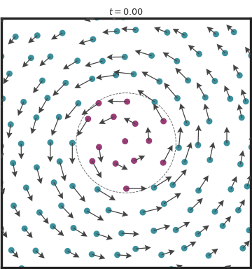

Figure 4: Fluid particles, drawn as dots, carried by the Lamb-Oseen vortex of Figure 3 for $t \in [0, 1]$, after which the animation restarts. Each arrow is the fluid velocity $v_t(x)$ at its dot $x$, tangent to the dot’s circle about the origin and proportional in length to the speed. Dots that start inside the core (dashed circle) have their own colour.

Each dot moves along its arrow, and the arrow stays tangent to the dot’s circle about the origin as the dot circles it. Near the center the angular speed is almost constant, $\omega(r) \approx \kappa / r_c^2$, so the dots there turn together like points of a rigid disk and keep their arrangement. Farther out the angular speed falls off with distance, so the inner dots pull ahead of the outer ones and the initial lattice winds into a spiral. The speed $\omega(r)\, r$ peaks at $r \approx 1.12\, r_c$, just outside the core, where the arrows are longest, and decays like $\kappa / r$ beyond it.

### 3.1.3 Flow maps between two times

The flow $\phi_t(x)$ starts each trajectory at $t = 0$, but the Picard-Lindelöf theorem gives a trajectory through each point at each time. Under its conditions, for each $s \in [0, 1]$ and $x \in \mathbb{R}^d$, exactly one solution of $\frac{d}{dt}\, X_t = v_t(X_t)$ has $X_s = x$, and it exists on all of $[0, 1]$, solved forward and backward from $s$ (§A.2). Its value at a time $t$ defines the **flow map** from $s$ to $t$,

$$\phi_{s \to t}: \mathbb{R}^d \to \mathbb{R}^d, \qquad x \mapsto X_t$$

the position at time $t$ of the trajectory that occupies $x$ at time $s$, for each $s, t \in [0, 1]$. The flow is the case $s = 0$, $\phi_t = \phi_{0 \to t}$.

Following a trajectory from $s$ to $r$ and then from $r$ to $t$ ends where following it from $s$ to $t$ ends. This is the **semigroup property** of the flow maps,

$$\boxed{\phi_{r \to t} \circ \phi_{s \to r} = \phi_{s \to t}, \qquad \phi_{s \to s} = \mathrm{id} \qquad \forall\, s, r, t \in [0, 1]}
\tag{6}$$

**NoteProof: the semigroup property**

For $s, r, t \in [0, 1]$ and $x \in \mathbb{R}^d$, let $X$ be the solution with $X_s = x$. At time $r$ it occupies $X_r = \phi_{s \to r}(x)$, so $X$ is also a solution whose value at time $r$ is $\phi_{s \to r}(x)$. By uniqueness it is the solution that defines $\phi_{r \to t}$ at that point, so $\phi_{r \to t}\big(\phi_{s \to r}(x)\big) = X_t$. By the definition of the flow map, $X_t = \phi_{s \to t}(x)$. The second identity holds because $\phi_{s \to s}(x) = X_s = x$. $\square$

Setting $t = s$ in Eq. 6 gives $\phi_{r \to s} \circ \phi_{s \to r} = \mathrm{id}$, and exchanging $s$ and $r$ gives $\phi_{s \to r} \circ \phi_{r \to s} = \mathrm{id}$, so each flow map is invertible, with the inverse $\phi_{r \to s}$, and the flow $\phi_t$ has the inverse $\phi_{t \to 0}$. For a velocity field fixed in time, $\phi_{s \to t}$ depends only on $t - s$, and Eq. 6 becomes the group property of the transformations that Lie studied [55]. For a velocity field that changes with time it follows from uniqueness alone [56]. Post #10 trains a network to approximate $\phi_{s \to t}$ directly, so that one evaluation of the network replaces a numerical solve.

## 3.2 Generation using flow models

This section builds a generative model from the ODE of §3.1 by learning its velocity field [3]. The field is learned so that a point sampled at $t = 0$ from a simple initial distribution, independent of the data distribution, follows the field to a point at $t = 1$ that is a random sample from the data distribution.

Chen et al. combined two earlier ideas. Tabak and Vanden-Eijnden had estimated densities with a map built as a flow that carries the samples toward a Gaussian [1]. E proposed treating deep networks as dynamical systems [61], and Lu et al. [62], Haber and Ruthotto [63], and Ruthotto and Haber [64] viewed residual networks as Euler steps of an ODE.

### 3.2.1 Definitions

The generative model built here has no forward process to reverse, so its time axis runs in the generative direction, from noise at $t = 0$ to data at $t = 1$, whereas the rest of the series has $t = 0$ as data. The model uses these objects, besides the trajectory $X$, velocity field $v_t(x)$ and flow $\phi_t(x)$ of §3.1.

- **Initial distribution $p_{\mathrm{init}}$:** A simple distribution on $\mathbb{R}^d$, such as $\mathcal{N}(0, I)$, from which the initial condition is sampled, with density $p_{\mathrm{init}}: \mathbb{R}^d \to [0, \infty)$.
- **Data distribution $p_{\mathrm{data}}$:** The distribution on $\mathbb{R}^d$ that generated samples should follow, with density $p_{\mathrm{data}}: \mathbb{R}^d \to [0, \infty)$.
- **Probability path $p_t$:** A probability distribution on $\mathbb{R}^d$ for each time $t \in [0, 1]$, with a density for each $t \in [0, 1)$; the distribution at $t = 1$ may be concentrated at one point and then has no density. At a fixed $x \in \mathbb{R}^d$, the path gives how the density at $x$ changes over time,
  $$p: [0, 1) \times \mathbb{R}^d \to [0, \infty), \qquad (t, x) \mapsto p_t(x)$$
- **Parameters $\theta$:** The weights of a neural network.
- **Network velocity field $v_\theta(x, t)$:** The velocity field the network represents,
  $$v_\theta: \mathbb{R}^d \times [0, 1] \to \mathbb{R}^d, \qquad (x, t) \mapsto v_\theta(x, t)$$
- **Flow $\phi^\theta_t(x)$:** The flow of $v_\theta(x, t)$, $\phi^\theta: \mathbb{R}^d \times [0, 1] \to \mathbb{R}^d$, $(x, t) \mapsto \phi^\theta_t(x)$, with $\phi^\theta_t(x_0)$ the position at time $t$ of the trajectory of $v_\theta(x, t)$ with the initial condition $X_0 = x_0$.

### 3.2.2 Flow model

Generated samples must be random, but the solution of an ODE is deterministic for a given initial condition. The randomness therefore enters through the initial condition, sampled from $p_{\mathrm{init}}$. A **flow model** is the ODE Eq. 4 with this random initial condition $X_0$ and the network velocity field $v_\theta(x, t)$,

$$\boxed{X_0 \sim p_{\mathrm{init}}, \qquad \frac{d}{dt}\, X_t = v_\theta(X_t, t)}
\tag{7}$$

The model is trained to make its solution at $t = 1$ follow the data distribution $p_{\mathrm{data}}$,

$$X_1 \sim p_{\mathrm{data}} \quad\Longleftrightarrow\quad \phi^\theta_1(X_0) \sim p_{\mathrm{data}}$$

so that solving the ODE from the initial condition $X_0 \sim p_{\mathrm{init}}$ produces a sample of $p_{\mathrm{data}}$. The distribution $p^\theta_t$ of $X_t$, a probability path $p^\theta: [0, 1] \times \mathbb{R}^d \to [0, \infty)$, $(t, x) \mapsto p^\theta_t(x)$, starts at $p^\theta_0 = p_{\mathrm{init}}$, so the learned field $v_\theta(x, t)$ *transports* the initial distribution $p_{\mathrm{init}}$ along a path of intermediate marginals $p^\theta_t$, ending at $p_{\mathrm{data}}$.

Since $X_t = \phi^\theta_t(X_0)$, the distribution $p^\theta_t$ is the pushforward (§2.1) of $p_{\mathrm{init}}$ under the flow, the distribution of $\phi^\theta_t(x)$ for $x \sim p_{\mathrm{init}}$, written $p^\theta_t = (\phi^\theta_t)_\# p_{\mathrm{init}}$. For a velocity field that is continuously differentiable in $x$ and Lipschitz as in the Picard-Lindelöf theorem above, the flow is invertible, with the inverse $\phi^\theta_{t \to 0}$, where $\phi^\theta_{s \to t}$ denotes the flow maps of $v_\theta$ (§3.1.3). The flow and its inverse are also differentiable in $x$, because the solution of an ODE with a continuously differentiable velocity field depends differentiably on its initial condition [35], [56]. So Eq. 1 gives the density of the pushforward,

$$p^\theta_t(x) = p_{\mathrm{init}}\big((\phi^\theta_t)^{-1}(x)\big)\, \Big\lvert \det \frac{\partial (\phi^\theta_t)^{-1}}{\partial x}(x) \Big\rvert$$

Chen et al. call this model a continuous normalizing flow [3], and Lipman et al. state flow matching in these terms [7].

The network computes the velocity field $v_\theta(x, t)$ and never the flow $\phi^\theta_t(x)$ that names the model, so producing a sample requires solving the ODE numerically (§3.3).

## 3.3 Sampling with the Euler method

A flow model generates a sample by solving Eq. 7 from the initial condition $X_0 \sim p_{\mathrm{init}}$ and returning $X_1$. The ODE is solved numerically, and the simplest scheme is the **Euler method** [15], which replaces the derivative in Eq. 7 by a forward difference over a step $\Delta t$. On the grid $t_i = i\, \Delta t$ with $\Delta t = 1/n$, and with $x_i$ the approximation of $X_{t_i}$, sampling runs as follows.

**Algorithm 7 — Sampling from a flow model with the Euler method** [15]:

1: $x_0 \sim p_{\mathrm{init}}$  
2: **for** $i = 0, \ldots, n - 1$ **do**  
3: $x_{i+1} = x_i + v_\theta(x_i, t_i)\, \Delta t$  
4: **end for**  
5: **return** $x_n$

Each step moves the sample along the network velocity field $v_\theta(x, t)$ for a time $\Delta t$, and the returned $x_n$ approximates $X_1 = \phi^\theta_1(x_0)$, a sample of the model’s distribution $p^\theta_1$.

The Euler method is a first-order method. Its error over one step, the **local error**, is of order $\Delta t^2$ when the solution is twice continuously differentiable, and the $n = 1/\Delta t$ steps accumulate an error of order $\Delta t$ at $t = 1$, the **global error**, when $v_\theta(x, t)$ is also Lipschitz in $x$. §A.3 proves both orders and surveys methods of higher order, which evaluate the velocity field more than once per step or reuse earlier evaluations.

## 3.4 Exact likelihood via the instantaneous change of variables

A flow model also gives the exact likelihood of each point, which the stochastic samplers of the reverse-time SDE cannot. The likelihood comes from the **instantaneous change of variables**, the continuous-time form of the change of variables Eq. 1. Along each trajectory of a velocity field $v_t(x)$, the log-density of the pushforward $p_t = (\phi_t)_\# p_0$ changes at the rate $-\nabla_x \cdot v_t$. This rate follows from Euler’s equation for the density of a moving fluid [4], and Chen et al. named the result and used it to compute likelihoods [3]. The derivation below applies Eq. 1 to the flow $\phi_t$ and differentiates the result in time.

We assume that $v_t(x)$ is continuously differentiable in $x$ and Lipschitz, as in §3.2.2, and that $p_0 > 0$. Applying Eq. 1 with $f = \phi_t$, $p = p_0$ and $y = \phi_t(x)$, so that $f^{-1}(y) = x$,

$$p_t\big(\phi_t(x)\big) = p_0(x)\, \Big\lvert \det \frac{\partial \phi_t^{-1}}{\partial x}\big(\phi_t(x)\big) \Big\rvert$$

By the inverse function theorem, the Jacobian of $\phi_t^{-1}$ at $\phi_t(x)$ is the inverse of the Jacobian $J_t(x) = \frac{\partial \phi_t}{\partial x}(x) \in \mathbb{R}^{d \times d}$ of $\phi_t$ at $x$,

$$p_t\big(\phi_t(x)\big) = p_0(x)\, \big\lvert \det J_t(x)^{-1} \big\rvert$$

Since the determinant of an inverse matrix is the reciprocal of its determinant,

$$p_t\big(\phi_t(x)\big) = p_0(x)\, \big\lvert \det J_t(x) \big\rvert^{-1}$$

The determinant $\det J_t(x)$ equals $\det I = 1$ at $t = 0$, depends continuously on $t$ and never vanishes, because $J_t(x)$ has an inverse, the Jacobian of $\phi_t^{-1}$ at $\phi_t(x)$, so it stays positive. Dropping the absolute value,

$$p_t\big(\phi_t(x)\big) = \frac{p_0(x)}{\det J_t(x)}$$

Taking logarithms,

$$\log p_t\big(\phi_t(x)\big) = \log p_0(x) - \log \det J_t(x)$$

Differentiating in $t$, where $p_0(x)$ does not depend on $t$,

$$\frac{d}{dt}\, \log p_t\big(\phi_t(x)\big) = -\frac{d}{dt}\, \log \det J_t(x)$$

By Jacobi’s formula for the derivative of a determinant [36], $\frac{d}{dt} \log \det J = \operatorname{tr}\big(J^{-1}\, \frac{d}{dt} J\big)$,

$$\frac{d}{dt}\, \log p_t\big(\phi_t(x)\big) = -\operatorname{tr}\Big(J_t(x)^{-1}\, \frac{d}{dt} J_t(x)\Big)$$

Differentiating the flow ODE Eq. 5 with respect to $x$, by the chain rule, shows that the Jacobian evolves as $\frac{d}{dt} J_t(x) = \frac{\partial v_t}{\partial x}\big(\phi_t(x)\big)\, J_t(x)$. Substituting it,

$$\frac{d}{dt}\, \log p_t\big(\phi_t(x)\big) = -\operatorname{tr}\Big(J_t(x)^{-1}\, \frac{\partial v_t}{\partial x}\big(\phi_t(x)\big)\, J_t(x)\Big)$$

By the cyclic property of the trace, $\operatorname{tr}(ABC) = \operatorname{tr}(BCA)$,

$$\frac{d}{dt}\, \log p_t\big(\phi_t(x)\big) = -\operatorname{tr}\Big(\frac{\partial v_t}{\partial x}\big(\phi_t(x)\big)\, J_t(x)\, J_t(x)^{-1}\Big)$$

Since $J_t(x)\, J_t(x)^{-1} = I$,

$$\frac{d}{dt}\, \log p_t\big(\phi_t(x)\big) = -\operatorname{tr}\Big(\frac{\partial v_t}{\partial x}\big(\phi_t(x)\big)\Big)$$

Since the trace of the Jacobian of $v_t$ is its **divergence**, $\operatorname{tr}\big(\frac{\partial v_t}{\partial x}\big) = \sum_{j=1}^{d} \frac{\partial v_t^{j}}{\partial x^{j}} = \nabla_x \cdot v_t$, with $x^j$ and $v_t^j$ the $j$-th coordinates of $x$ and $v_t$,

$$\frac{d}{dt}\, \log p_t\big(\phi_t(x)\big) = -(\nabla_x \cdot v_t)\big(\phi_t(x)\big)$$

Integrating both sides from $0$ to $t$, with $s$ as the integration variable,

$$\log p_t\big(\phi_t(x)\big) - \log p_0\big(\phi_0(x)\big) = -\int_0^t (\nabla_x \cdot v_s)\big(\phi_s(x)\big)\, ds$$

Since $\phi_0(x) = x$ by Eq. 5,

$$\log p_t\big(\phi_t(x)\big) - \log p_0(x) = -\int_0^t (\nabla_x \cdot v_s)\big(\phi_s(x)\big)\, ds$$

Adding $\log p_0(x)$ to both sides,

$$\boxed{\log p_t\big(\phi_t(x)\big) = \log p_0(x) - \int_0^t (\nabla_x \cdot v_s)\big(\phi_s(x)\big)\, ds}
\tag{8}$$

$\square$

### 3.4.1 Exact likelihood of a flow model

For the flow model, $p_0 = p_{\mathrm{init}}$ and the velocity field is $v_\theta$, so Eq. 8 at $t = 1$ gives the exact log-likelihood of each point $x_1 \in \mathbb{R}^d$ [3]. Applying it with $x = x_0$, where $x_0 = (\phi^\theta_1)^{-1}(x_1)$ is the point that $\phi^\theta_1$ maps to $x_1$,

$$\log p^\theta_1(x_1) = \log p_{\mathrm{init}}(x_0) - \int_0^1 (\nabla_x \cdot v_\theta)\big(\phi^\theta_s(x_0),\, s\big)\, ds$$

Solving the flow ODE of $v_\theta$ backward, from $x_1$ at $t = 1$ to $t = 0$, gives $x_0$, and the same solve accumulates the integral of the divergence along the trajectory.

Compared with Eq. 2, the continuous form differs in two respects [3].

- **A trace instead of a determinant:** The sum of log-determinants becomes the integral of a divergence, the trace of the Jacobian $\frac{\partial v_t}{\partial x}$. The trace needs only the $d$ diagonal entries of that Jacobian, while a determinant costs $O(d^3)$, so the velocity field needs no triangular Jacobian of the kind coupling layers build. The exact trace still costs $d$ backward passes of reverse-mode automatic differentiation, one for each diagonal entry (P2:§3.3.3.4), a cost that §3.6 reduces.
- **No invertible building blocks:** The flow needs no invertible maps as building blocks, since any velocity field that meets the Picard-Lindelöf conditions gives an invertible flow (§3.2.2).

The first difference appears in the discrete formula itself when its layers are small residual layers. One step of Algorithm 7, $x \mapsto x + \Delta t\, v_\theta(x, t_i)$, is a residual layer (§2.2.3) with $g = \Delta t\, v_\theta(\cdot, t_i)$, a contraction with the constant $K\, \Delta t$ once $K\, \Delta t < 1$, where $K$ is the Lipschitz constant of $v_\theta$, so that $\lVert J_g \rVert \le K\, \Delta t$ as in §2.2.3. In Eq. 3 the Jacobian is

$$J_g = \Delta t\, \frac{\partial v_\theta}{\partial x}(x, t_i)$$

so its $k$-th term is of order $\Delta t^k$. Separating the first term, $\operatorname{tr}(J_g) = \Delta t\, (\nabla_x \cdot v_\theta)(x, t_i)$, from the others,

$$\log \det\Big(I + \Delta t\, \frac{\partial v_\theta}{\partial x}(x, t_i)\Big) = \Delta t\, (\nabla_x \cdot v_\theta)(x, t_i) + \sum_{k=2}^{\infty} \frac{(-1)^{k+1}}{k}\, \operatorname{tr}\big(J_g^k\big)$$

Bounding the remaining terms by the geometric series $d\, K^2 \Delta t^2 / (1 - K\, \Delta t)$, since $\operatorname{tr}(J_g^k)$ is the sum of the $d$ values $\lambda_j^k$ of §2.2.3, each of modulus at most $\lVert J_g \rVert^k \le (K\, \Delta t)^k$,

$$\log \det\Big(I + \Delta t\, \frac{\partial v_\theta}{\partial x}(x, t_i)\Big) = \Delta t\, (\nabla_x \cdot v_\theta)(x, t_i) + O(\Delta t^2)$$

This bound is the same at each $x$ and $t_i$, so the constant in $O(\Delta t^2)$ is the same for each layer. The sum of the log-determinants of $n = 1/\Delta t$ such layers in Eq. 2 is then the Riemann sum $\sum_i \Delta t\, (\nabla_x \cdot v_\theta)(x_i, t_i)$ of the divergence at the layers’ inputs, up to $n \cdot O(\Delta t^2) = O(\Delta t)$. The exact log-likelihood above has, in place of this sum, the integral of the divergence along the trajectory $\phi^\theta_s(x_0)$, where the sum evaluates the divergence at the Euler iterates $x_i$.

## 3.5 Maximum-likelihood training and the adjoint method

Since Eq. 8 gives the exact log-likelihood $\log p^\theta_1(x_1)$ of each point, Chen et al. train a flow model by maximum likelihood [3]. The parameters $\theta$ maximize the average log-likelihood of the data,

$$\max_\theta\ \mathbb{E}_{p_{\mathrm{data}}(x_1)}\big[\log p^\theta_1(x_1)\big]$$

Each training step therefore evaluates $\log p^\theta_1(x_1)$ for each $x_1 \sim p_{\mathrm{data}}$ in a minibatch, by the backward solve of §3.4. Writing $L_t = -\int_t^1 \nabla_x \cdot v_\theta(X_s, s)\, ds \in \mathbb{R}$ for the integral accumulated from $t = 1$ back to $t$, the trajectory and the integral solve one joint ODE [3], [5],

$$\frac{d}{dt}\, X_t = v_\theta(X_t, t), \qquad \frac{d}{dt}\, L_t = \nabla_x \cdot v_\theta(X_t, t), \qquad X_1 = x_1,\ L_1 = 0$$

Solving it from $t = 1$ back to $t = 0$ gives $x_0 = X_0$ and $L_0$, so $\log p^\theta_1(x_1) = \log p_{\mathrm{init}}(x_0) + L_0$ by Eq. 8 at $t = 1$ for the flow model.

Backpropagating through the solver would store each of its internal steps, so the memory of a training step would grow with their number. The **adjoint method** computes the gradient with constant memory instead, by solving a second ODE from the end of the first solve back to its start. It comes from the optimal control of Pontryagin et al. [65], and Chen et al. brought it to neural ODEs, ODEs whose right-hand side is a neural network [3].

The method applies to any ODE

$$\frac{d}{dt}\, Z_t = f(Z_t, t, \theta)$$

with a state $Z_t \in \mathbb{R}^m$, parameters $\theta \in \mathbb{R}^P$ and a right-hand side $f: \mathbb{R}^m \times \mathbb{R} \times \mathbb{R}^P \to \mathbb{R}^m$, $(z, t, \theta) \mapsto f(z, t, \theta)$, solved from $t_0$ to $t_1$. The joint ODE above is one, with $Z_t = (X_t, L_t)$, $m = d + 1$, $t_0 = 1$ and $t_1 = 0$. For a loss $\mathcal{L}$ that depends on the final state $Z_{t_1}$, the **adjoint** is the row vector

$$a(t) = \frac{\partial \mathcal{L}}{\partial Z_t} \in \mathbb{R}^{1 \times m}$$

It is the sensitivity of the loss to the state at time $t$. Since $\mathcal{L}$ depends on $Z_t$ only through $Z_{t+\varepsilon}$, for a short step $\varepsilon$ toward $t_1$, by the chain rule,

$$a(t) = a(t + \varepsilon)\, \frac{\partial Z_{t+\varepsilon}}{\partial Z_t}$$

Expanding the solution to first order in $\varepsilon$,

$$Z_{t+\varepsilon} = Z_t + \varepsilon f(Z_t, t, \theta) + O(\varepsilon^2)$$

Differentiating it in $Z_t$ gives the Jacobian of the step,

$$\frac{\partial Z_{t+\varepsilon}}{\partial Z_t} = I + \varepsilon\, \frac{\partial f}{\partial z}(Z_t, t, \theta) + O(\varepsilon^2)$$

Substituting it,

$$a(t) = a(t + \varepsilon)\, \Big[I + \varepsilon\, \frac{\partial f}{\partial z}(Z_t, t, \theta) + O(\varepsilon^2)\Big]$$

Expanding the product,

$$a(t) = a(t + \varepsilon) + \varepsilon\, a(t + \varepsilon)\, \frac{\partial f}{\partial z}(Z_t, t, \theta) + O(\varepsilon^2)$$

Moving $a(t + \varepsilon)$ to the left-hand side,

$$a(t) - a(t + \varepsilon) = \varepsilon\, a(t + \varepsilon)\, \frac{\partial f}{\partial z}(Z_t, t, \theta) + O(\varepsilon^2)$$

Dividing by $-\varepsilon$,

$$\frac{a(t + \varepsilon) - a(t)}{\varepsilon} = -\,a(t + \varepsilon)\, \frac{\partial f}{\partial z}(Z_t, t, \theta) + O(\varepsilon)$$

Letting $\varepsilon \to 0$,

$$\boxed{\frac{d}{dt}\, a(t) = -\,a(t)\, \frac{\partial f}{\partial z}(Z_t, t, \theta)}
\tag{9}$$

$\square$

The gradient with respect to $\theta$ follows from the same argument, with $\theta$ as a second state that does not change in time, $\frac{d}{dt}\, \theta_t = 0$ [3]. Its adjoint is the row vector

$$a_\theta(t) = \frac{\partial \mathcal{L}}{\partial \theta_t} \in \mathbb{R}^{1 \times P}$$

It is the sensitivity of the loss to the value of $\theta$ used from time $t$ on. The augmented state $(Z_t, \theta_t)$ has the right-hand side $(f, 0)$, whose Jacobian is

$$\begin{pmatrix} \partial f / \partial z & \partial f / \partial \theta \\ 0 & 0 \end{pmatrix}$$

So the $\theta$-component of Eq. 9 for the augmented state is

$$\frac{d}{dt}\, a_\theta(t) = -\,a(t)\, \frac{\partial f}{\partial \theta}(Z_t, t, \theta)$$

Integrating from $t_1$ to $t_0$,

$$a_\theta(t_0) - a_\theta(t_1) = -\int_{t_1}^{t_0} a(t)\, \frac{\partial f}{\partial \theta}(Z_t, t, \theta)\, dt$$

The adjoint $a_\theta$ starts at $a_\theta(t_1) = 0$, because no time is left after $t_1$ for $\theta$ to act. It ends at $a_\theta(t_0) = d\mathcal{L}/d\theta$, because the value of $\theta$ used from $t_0$ on is $\theta$ itself. Substituting both values,

$$\boxed{\frac{d\mathcal{L}}{d\theta} = -\int_{t_1}^{t_0} a(t)\, \frac{\partial f}{\partial \theta}(Z_t, t, \theta)\, dt}$$

$\square$

### 3.5.1 The adjoint solve and its cost

The state $Z_t$, recomputed from its final value, and the adjoints $a(t)$ and $a_\theta(t)$ solve one joint ODE from $t_1$ back to $t_0$. It starts from $Z_{t_1}$, $a(t_1) = \partial \mathcal{L} / \partial Z_{t_1}$ and $a_\theta(t_1) = 0$ (Chen et al.’s Algorithm 1) [3]. The right-hand sides of the adjoint ODEs are vector-Jacobian products, a row vector times a Jacobian. Reverse-mode automatic differentiation computes each at about the cost of one evaluation of $f$.

This solve recomputes the state instead of storing the steps of the first solve, so the memory does not grow with the number of steps. The time does grow, since it is proportional to the **number of function evaluations (NFE)**, the evaluations of $f$ that a solve needs. Chen et al. use adaptive solvers, which choose their step sizes to meet an error tolerance, and in their experiments this number grew as training proceeded (their Figure 3d, for a classifier of MNIST, a dataset of $28 \times 28$ images of handwritten digits).

## 3.6 Free-form flows: FFJORD

Grathwohl et al.’s Free-form Jacobian of Reversible Dynamics (FFJORD) replaces the exact divergence in Eq. 8 with a stochastic estimate [5]. Chen et al. had kept the cost of the exact divergence low by restricting the velocity field. They built it from sums of simple terms, each with a trace in closed form, and the trace of the sum is the sum of these traces [3].

The divergence is the trace of the $d \times d$ Jacobian $\frac{\partial v_t}{\partial x}$, and computing it exactly costs the $d$ backward passes of §3.4. The trace is also an expectation over a random probe $\eta \sim \mathcal{N}(0, I)$. For a constant matrix $A \in \mathbb{R}^{d \times d}$, writing the scalar $\eta^\top A\, \eta$ as its own trace and using the cyclic property of the trace,

$$\mathbb{E}\big[\eta^\top A\, \eta\big] = \mathbb{E}\big[\operatorname{tr}(A\, \eta \eta^\top)\big]$$

Exchanging the trace and the expectation, both linear, with $A$ constant,

$$\mathbb{E}\big[\eta^\top A\, \eta\big] = \operatorname{tr}\big(A\, \mathbb{E}[\eta \eta^\top]\big)$$

Since $\mathbb{E}[\eta \eta^\top] = I$,

$$\mathbb{E}\big[\eta^\top A\, \eta\big] = \operatorname{tr}(A)$$

Applying it with $A = \frac{\partial v_t}{\partial x}(x)$, whose trace is $\nabla_x \cdot v_t(x)$,

$$\nabla_x \cdot v_t(x) = \mathbb{E}_{\eta \sim \mathcal{N}(0, I)}\Big[\eta^\top\, \frac{\partial v_t}{\partial x}(x)\, \eta\Big]$$

The **Hutchinson trace estimator** [37], [38] replaces this expectation with its value at one sample of $\eta$. Each such value costs one backward pass, which computes the vector-Jacobian product $\eta^\top \frac{\partial v_t}{\partial x}$, and then a dot product with $\eta$. Grathwohl et al. brought the estimator to flow models [5], Behrmann et al. used it for the traces in Eq. 3, and it is the same single-probe technique that makes Song et al.’s sliced score matching inexpensive [66].

Holding one probe $\eta$ fixed for each solve keeps the ODE deterministic, as an adaptive solver requires. The estimate of $\log p^\theta_1(x_1)$ stays unbiased, since the expectation over $\eta$ can be taken outside the time integral [5]. The cost of the divergence falls from $d$ backward passes to one, which Grathwohl et al. state as $O(d^2)$ against $O(d)$ time, so the velocity field $v_\theta$ can be any network.

FFJORD reached 0.99 bits per dimension on MNIST, ahead of Glow’s 1.05 with less than 2% of Glow’s parameters, and 3.40 on CIFAR-10, against Glow’s 3.35 [5]. Its image models took about five days to train on six graphics processing units (GPUs).

Grathwohl et al. name two limitations. The NFE “tends to grow as the models trains and can become prohibitively large”, and general-purpose solvers restrict the flow to non-stiff dynamics. A stiff ODE has components that change on time scales differing by orders of magnitude, and an explicit solver stays stable on it only with steps on the shortest of those scales.

## 3.7 Regularized flows: RNODE

Finlay et al. attributed the growing NFE to the learned velocity field itself [6]. The velocity field that maximizes the likelihood is not unique, because maximum likelihood constrains only the distribution at $t = 1$. Training can converge to a field whose trajectories turn sharply and change speed, which an adaptive solver follows only in small steps. Training FFJORD on CIFAR-10, they found the NFE strongly correlated with the Frobenius norm of the Jacobian of $v_\theta$, the square root of the sum of its squared entries.

Their method, the regularized neural ODE (RNODE), adds two penalties to FFJORD’s negative log-likelihood [6]. The first is the kinetic energy, the integral of the squared speed $\lVert v_\theta \rVert^2$ along a trajectory. The second is the integral of the squared Frobenius norm of the Jacobian $\frac{\partial v_\theta}{\partial x}$ along it. With $X_t$ the trajectory of $v_\theta$ that ends at $X_1 = x_1$, and weights $\lambda_K, \lambda_J > 0$, the objective is

$$\min_\theta\ \mathbb{E}_{p_{\mathrm{data}}(x_1)}\Big[-\log p^\theta_1(x_1) + \lambda_K \int_0^1 \big\lVert v_\theta(X_s, s) \big\rVert^2\, ds + \lambda_J \int_0^1 \Big\lVert \frac{\partial v_\theta}{\partial x}(X_s, s) \Big\rVert_F^2\, ds\Big]$$

The kinetic term favours trajectories that run in straight lines at constant speed. Among the velocity fields that carry one distribution to another, those of least kinetic energy have such trajectories, by the dynamic formulation of optimal transport that Benamou and Brenier introduced and post #5 develops [46]. The kinetic term straightens only the trajectories that the training data follow, however, which is one reason Finlay et al. add the Jacobian term.

The Jacobian term needs no extra backward pass. Its integrand is an expectation over the same probe $\eta$ as the divergence estimate, since

$$\lVert A \rVert_F^2 = \operatorname{tr}(A A^\top) = \mathbb{E}_{\eta \sim \mathcal{N}(0, I)}\lVert \eta^\top A \rVert^2$$

The vector-Jacobian product $\eta^\top \frac{\partial v_\theta}{\partial x}$ it needs is the one that estimate already computes.

With $\lambda_K = \lambda_J = 0.01$, RNODE trained about 2.8 times faster than FFJORD on MNIST and on CIFAR-10, at comparable bits per dimension [6]. On CIFAR-10 it reached 3.38, against 3.36 for Finlay et al.’s own FFJORD run and 3.40 as Grathwohl et al. reported. It also trained on ImageNet, a dataset of about 1.3 million natural images, downsampled to $64 \times 64$ pixels, reaching 3.83, where their FFJORD run failed to train.

## 3.8 Pitfalls

Maximum-likelihood training of flow models works, but it has two pitfalls, and flow matching, the subject of Parts 4 to 6, removes both.

### 3.8.1 Training solves the ODE

Each training step of §3.5 solves the ODE backward, from $t = 1$ to $t = 0$, for each $x_1 \sim p_{\mathrm{data}}$ in the minibatch, and then solves the adjoint ODE from $t = 0$ back to $t = 1$. Both solves use an adaptive solver, whose NFE grows as training proceeds (§3.6). A training step therefore costs at least two solves of the ODE for each point of the minibatch, where generating a sample costs one. This cost is why FFJORD’s image models took days to train, and a stiff flow, which forces small steps, would raise it further.

### 3.8.2 The path is not specified

Maximum likelihood leaves the probability path from $p_{\mathrm{init}}$ to $p^\theta_1$ to the optimizer, since the likelihood depends only on the distribution $p^\theta_1$ at $t = 1$ (§3.7). Many probability paths connect the same two distributions. Along each of them the velocity field is not unique either, since a field that moves mass without changing the intermediate distributions can be added, which Part 4 makes precise. The optimizer’s choice among them can be irregular.

Liu et al. call the maximum-likelihood problem for neural ODEs under-specified for this reason, as it leaves the paths “for the algorithm to figure out implicitly” [8]. RNODE’s penalties favour straighter paths but still leave the choice to the optimizer, whereas flow matching fixes the path before training.

# 4 Probability Paths and the Continuity Equation

Flow matching removes both pitfalls of §3.8. It fixes the path first, so the path is specified, and it trains by regression onto a velocity field constructed for the path, so training never solves the ODE.

Training seeks parameters $\theta$ such that solving Eq. 7 with the initial condition $X_0 \sim p_{\mathrm{init}}$ ends at $X_1 \sim p_{\mathrm{data}}$. **Flow matching** [7], [8], [9] does it in three steps: fixing a probability path $p_t$ from noise to data (§4.1), constructing a velocity field whose trajectories follow it (§4.2), and regressing the network onto that field (§5.2).

This Part carries out the first two steps. It defines conditional and marginal probability paths, with a Gaussian path to a spiral as the running example, and their conditional and marginal velocity fields.

The Part then states the continuity equation, proves that a probability path satisfies it with a velocity field if and only if the path is the distribution of that field’s ODE solution, and uses this to prove that the ODE solution of the marginal velocity field has the marginal path as its distribution. It shows that the continuity equation does not determine the velocity field, and it ends by relating the four forms of the change of variables (§4.6). Part 5 carries out the third step.

## 4.1 Conditional and marginal probability paths

A **conditional probability path** [7] is, for each $x_1 \in \mathbb{R}^d$, a probability density at each time $t \in [0, 1)$,

$$p_t(\cdot \mid x_1): \mathbb{R}^d \to [0, \infty), \qquad x \mapsto p_t(x \mid x_1), \qquad t \in [0, 1)$$

that starts at the initial distribution $p_{\mathrm{init}}$ and ends, at $t = 1$, concentrated at $x_1$,

$$\boxed{p_0(\cdot \mid x_1) = p_{\mathrm{init}}, \qquad p_1(\cdot \mid x_1) = \delta(\cdot - x_1)}
\tag{10}$$

The **Dirac delta** $\delta(\cdot - a)$ [67] at a point $a \in \mathbb{R}^d$ is the distribution that puts all its probability on $a$, so that each sample of it is $a$. It is written as a density that is zero away from $a$ and integrates to $1$, although it has no density in the ordinary sense, and it acts on a continuous function $f: \mathbb{R}^d \to \mathbb{R}$ by the sifting property $\int \delta(x - y)\, f(y)\, dy = f(x)$.

The **marginal probability path** $p_t$ is the distribution of a point sampled from the conditional path $p_t(\cdot \mid x_1)$ with $x_1 \sim p_{\mathrm{data}}$,

$$\boxed{x_1 \sim p_{\mathrm{data}}, \quad x \sim p_t(\cdot \mid x_1) \quad\Longrightarrow\quad x \sim p_t}
\tag{11}$$

so its density is the mixture

$$\boxed{p_t(x) = \int p_t(x \mid x_1)\, p_{\mathrm{data}}(x_1)\, dx_1}
\tag{12}$$

The integral over the data makes this density intractable, but Eq. 11 samples from $p_t$ without it.

The marginal path $p_t$ runs from the initial distribution $p_{\mathrm{init}}$ to the data distribution $p_{\mathrm{data}}$,

$$\boxed{p_0 = p_{\mathrm{init}}, \qquad p_1 = p_{\mathrm{data}}}
\tag{13}$$

**NoteProof: the endpoints of the marginal path**

Setting $t = 0$ in Eq. 12,

$$p_0(x) = \int p_0(x \mid x_1)\, p_{\mathrm{data}}(x_1)\, dx_1$$

Substituting the boundary condition $p_0(\cdot \mid x_1) = p_{\mathrm{init}}$ of Eq. 10,

$$p_0(x) = \int p_{\mathrm{init}}(x)\, p_{\mathrm{data}}(x_1)\, dx_1$$

Taking $p_{\mathrm{init}}(x)$, which does not depend on $x_1$, out of the integral,

$$p_0(x) = p_{\mathrm{init}}(x) \int p_{\mathrm{data}}(x_1)\, dx_1$$

Since $p_{\mathrm{data}}$ integrates to $1$,

$$p_0(x) = p_{\mathrm{init}}(x)$$

Setting $t = 1$ in Eq. 12,

$$p_1(x) = \int p_1(x \mid x_1)\, p_{\mathrm{data}}(x_1)\, dx_1$$

Substituting the boundary condition $p_1(\cdot \mid x_1) = \delta(\cdot - x_1)$ of Eq. 10,

$$p_1(x) = \int \delta(x - x_1)\, p_{\mathrm{data}}(x_1)\, dx_1$$

By the sifting property of the Dirac delta,

$$p_1(x) = p_{\mathrm{data}}(x)$$

Together with the value at $t = 0$, this is Eq. 13. $\square$

### 4.1.1 Gaussian conditional path to a spiral

A two-dimensional example after Holderrieth and Erives [10] shows the two paths, with a Gaussian $p_{\mathrm{init}}$ and a $p_{\mathrm{data}}$ shaped into a spiral by a Lamb-Oseen vortex.

**Initial distribution $p_{\mathrm{init}}$:** The standard Gaussian $\mathcal{N}(0, I)$ on $\mathbb{R}^2$.

**Data distribution $p_{\mathrm{data}}$:** A spiral built from a disk using a Lamb-Oseen vortex, as Figure 5 and Figure 6 show below. The disk has radius $\rho = 1.2$ and center $c = (1.5, 0)$ (left panel of Figure 5). Each of its points is carried by the flow $\phi_1$ of the Lamb-Oseen vortex of §3.1.2, with $\kappa = 40.5$ and $r_c = 1.2$, which turns a point at distance $r$ from the origin by the angle $\omega(r)$.

[figure not shown]

Figure 5: The support of $p_{\mathrm{data}}$ as a disk turned into a spiral. **Left:** The disk of radius $\rho = 1.2$ centered at $c = (1.5, 0)$; the dashed lines mark $c$ and the disk’s edges $1.5 \pm \rho$, and the curved arrow shows the counterclockwise rotation by $\omega(r)$. **Right:** Its image under the rotation $(r, \vartheta) \mapsto (r, \vartheta + \omega(r))$ in polar coordinates, with $\kappa = 40.5$ and $r_c = 1.2$, on which $p_{\mathrm{data}}$ is uniform; the dashed circle is the vortex core of radius $r_c$.

The angle $\omega(r)$ is largest near the origin and falls off with distance, so the side of the disk nearest the origin winds into the inner turns of the spiral and the far side forms its outer end (right panel).

Figure 6 below animates the construction, turning each point of the disk by the fraction $s$ of its angle $\omega(r)$ as $s$ runs from $0$ to $1$.

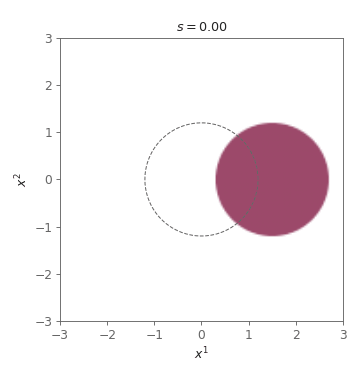

Figure 6: The construction of $p_{\mathrm{data}}$: each point of the disk of Figure 5 (left) is turned about the origin by the angle $s\, \omega(r)$, for $s$ from $0$ to $1$, ending at the spiral (right), after which the animation restarts. The dashed circle is the vortex core of radius $r_c$.

The resulting $p_{\mathrm{data}}$ is uniform on the spiral. With $D$ the disk of radius $\rho$ centered at $c$, and $p_{\mathrm{data}}(r, \vartheta)$ its density at the point with polar coordinates $(r, \vartheta)$,

$$p_{\mathrm{data}}(r, \vartheta) = \begin{cases} 1 / (\pi \rho^2), & (r,\ \vartheta - \omega(r)) \in D \\ 0, & \text{otherwise} \end{cases}$$

The spiral is the set of points that turning back by $\omega(r)$, $(r, \vartheta) \mapsto (r, \vartheta - \omega(r))$, sends into $D$. That turn preserves the area element $r\, dr\, d\vartheta$, so the spiral has the area $\pi \rho^2$ of $D$ and $p_{\mathrm{data}}$ integrates to $1$.

**Conditional path:** The example uses a conditional probability path of Lipman et al. that is Gaussian at each time [7],

$$p_t(\cdot \mid x_1) = \mathcal{N}\big(t\, x_1,\ (1 - t)^2 I\big)$$

At $t = 0$ it is $\mathcal{N}(0, I) = p_{\mathrm{init}}$. At $t = 1$ its variance is zero, and a Gaussian with zero variance is the Dirac delta $\delta(\cdot - x_1)$, so both boundary conditions of Eq. 10 hold. A sample of it is $t\, x_1 + (1 - t)\, \epsilon$ with $\epsilon \sim \mathcal{N}(0, I)$. The path contracts the Gaussian onto $x_1$, as its mean $t\, x_1$ runs along the segment from the origin to $x_1$ and its standard deviation $1 - t$ falls from one to zero. The left animation of Figure 7 below shows this path for one fixed $x_1$, marked by the star, and the right animation the marginal path $p_t$.

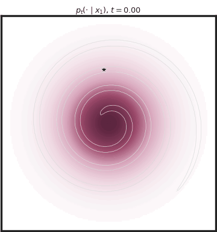

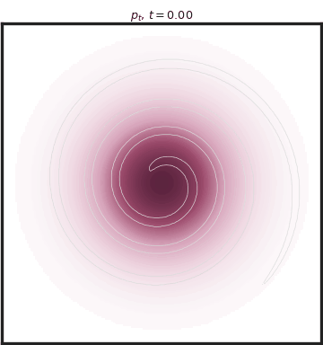

Figure 7: The conditional probability path $p_t(\cdot \mid x_1) = \mathcal{N}(t\, x_1, (1 - t)^2 I)$ for one fixed $x_1$ on the spiral, marked by the star (**left**), and the marginal path $p_t$ for a data distribution $p_{\mathrm{data}}$ uniform on a spiral (**right**), for $t \in [0, 1]$, after which the animations restart. The faint outline marks the support of $p_{\mathrm{data}}$, and each frame shows the density scaled to its own maximum. After Holderrieth and Erives [10], whose example uses a checkerboard for $p_{\mathrm{data}}$.

**Marginal path:** By Eq. 11, sampling $x_1 \sim p_{\mathrm{data}}$ and then $t\, x_1 + (1 - t)\, \epsilon$ gives a sample of the marginal path $p_t$, so $p_t$ is the distribution of $t\, x_1$, the spiral contracted toward the origin by the factor $t$, convolved with $\mathcal{N}(0, (1 - t)^2 I)$. The right animation shows it. At $t = 0$ it starts at the same Gaussian as the conditional path does, but at $t = 1$, instead of at a single point $x_1$, it ends at $p_{\mathrm{data}}$, the spiral.

## 4.2 Conditional and marginal velocity fields

A probability path prescribes the distribution that the solution $X_t$ of an ODE should have at each time. This section defines the velocity fields of such ODEs, first for the conditional probability path $p_t(\cdot \mid x_1)$ of each $x_1 \in \mathbb{R}^d$ (§4.2.1) and then, by averaging these fields over $x_1$, for the marginal probability path $p_t$ (§4.2.2). §4.5 proves that the solution of the averaged field’s ODE has $p_t$ as its distribution at each time. Lipman et al. [7] and Holderrieth and Erives [10] call the two fields defined below the conditional and marginal vector fields.

### 4.2.1 Conditional velocity field

For each $x_1 \in \mathbb{R}^d$, a **conditional velocity field** $u(\cdot \mid x_1): \mathbb{R}^d \times [0, 1) \to \mathbb{R}^d$, $(x, t) \mapsto u_t(x \mid x_1)$, is a velocity field whose ODE solution, with the initial condition $X_0 \sim p_{\mathrm{init}}$ and with $X_1 = \lim_{t \to 1} X_t$, has the conditional probability path $p_t(\cdot \mid x_1)$ of §4.1 as its distribution at each time $t$,

$$\boxed{X_0 \sim p_{\mathrm{init}}, \quad \frac{d}{dt}\, X_t = u_t(X_t \mid x_1) \ \ (t < 1) \quad\Longrightarrow\quad X_t \sim p_t(\cdot \mid x_1) \quad \forall t \in [0, 1]}
\tag{14}$$

By Eq. 14 and the endpoint $\delta(\cdot - x_1)$ of Eq. 10, the ODE solution of the conditional velocity field $u_t(\cdot \mid x_1)$ ends at $X_1 = x_1$. In isolation, the conditional velocity field is of little use, as it carries a distribution to a single point, but taking a weighted average of these conditional fields over $x_1$ gives a marginal velocity field that carries $p_{\mathrm{init}}$ to $p_{\mathrm{data}}$.

### 4.2.2 Marginal velocity field

Averaging the conditional velocity fields over $x_1 \sim p_{\mathrm{data}}$, weighted by how likely each $x_1$ is to have produced the point $x$, gives the **marginal velocity field** $u: \mathbb{R}^d \times [0, 1) \to \mathbb{R}^d$, $(x, t) \mapsto u_t(x)$,

$$\boxed{u_t(x) = \int u_t(x \mid x_1)\, \frac{p_t(x \mid x_1)\, p_{\mathrm{data}}(x_1)}{p_t(x)}\, dx_1 \qquad p_t(x) > 0}
\tag{15}$$

By Bayes’ rule [68], the weight in Eq. 15 is the **posterior** $p_t(\cdot \mid x): \mathbb{R}^d \to [0, \infty)$, $x_1 \mapsto p_t(x_1 \mid x)$,

$$\frac{p_t(x \mid x_1)\, p_{\mathrm{data}}(x_1)}{p_t(x)} = p_t(x_1 \mid x)$$

Substituting it into Eq. 15,

$$u_t(x) = \int u_t(x \mid x_1)\, p_t(x_1 \mid x)\, dx_1$$

The integral is the expectation over the posterior,

$$\boxed{u_t(x) = \mathbb{E}_{p_t(x_1 \mid x)}\big[\, u_t(x \mid x_1) \,\big]}
\tag{16}$$

$\square$

#### 4.2.2.1 The marginal velocity as a posterior average

For the spiral example of §4.1.1, the conditional path $\mathcal{N}\big(t\, x_1, (1 - t)^2 I\big)$ is the distribution of $X_t = t\, x_1 + (1 - t)\, X_0$ with $X_0 \sim p_{\mathrm{init}}$. This $X_t$ satisfies

$$\frac{d}{dt} X_t = x_1 - X_0 = \frac{x_1 - X_t}{1 - t}$$

so

$$u_t(x \mid x_1) = \frac{x_1 - x}{1 - t}$$

is a conditional velocity field of the path, since the ODE has a unique solution (§3.1).

By Eq. 16, the marginal velocity field at a point $x$ is the average of these fields under the posterior

$$p_t(x_1 \mid x) \propto \mathcal{N}\big(x;\ t\, x_1, (1 - t)^2 I\big)\, p_{\mathrm{data}}(x_1)$$

As a function of $x_1$, the Gaussian factor is proportional to

$$\mathcal{N}\big(x_1;\ x / t,\ ((1 - t)/t)^2 I\big)$$

so the posterior is $p_{\mathrm{data}}$ reweighted by a Gaussian centered at $x / t$ with standard deviation $(1 - t)/t$. The average at one point $x$ and two times is drawn as arrows, as Figure 8 shows below.

[figure not shown]

Figure 8: The marginal velocity field $u_t$ as a posterior average for the spiral example, at the point $x = (1, -0.8)$ (black dot) at $t = 0.25$ (**left**) and $t = 0.8$ (**right**). The thin arrows, each shaded by its posterior weight $p_t(x_1 \mid x)$, are the conditional velocities $u_t(x \mid x_1)$ toward 200 of 4000 points $x_1 \sim p_{\mathrm{data}}$, over the support of $p_{\mathrm{data}}$ in grey. The thick arrow is the posterior average of the conditional velocities toward all 4000 points, an estimate of the marginal velocity $u_t(x)$. All arrows are scaled by $1 - t$, so each thin arrow ends at its $x_1$ and the thick arrow at the posterior mean of $x_1$. After Lipman et al.’s guide (their Figure 3) [11] and Lai et al. (their Figure 5.7) [69].

At $t = 0.25$ the standard deviation is $3$, wider than the spiral, so the posterior spreads over the whole spiral and the conditional velocities point in all directions. They largely cancel in the average, and the thick arrow ends at the posterior mean $(0.72, -0.27)$, between the arms, where $p_{\mathrm{data}}$ has no mass.

At $t = 0.8$ the standard deviation is $0.25$, so the posterior concentrates on the part of the arm just outside $x$ near $x / t = (1.25, -1)$, and the average follows the few arrows that carry its weight. As $(1 - t)/t$ falls from infinity to zero, $u_t$ at each point averages over the whole spiral early and over the nearby data late.

## 4.3 The continuity equation

The **continuity equation**, first written by Euler for the density of a fluid [4], is a partial differential equation that relates a probability path $p_t$ to a velocity field $v_t(x)$,

$$\boxed{\partial_t p_t(x) + \nabla_x \cdot \big( p_t(x)\, v_t(x) \big) = 0}
\tag{17}$$

The product $p_t(x)\, v_t(x)$ is the **probability flux**, the probability mass that crosses a unit area per unit time. In a time $\Delta t$, the probability that crosses a unit area perpendicular to $v_t(x)$ is the mass of the particles within the length $\lVert v_t(x) \rVert\, \Delta t$ behind it, $p_t(x)\, \lVert v_t(x) \rVert\, \Delta t$, so per unit time the flux is $p_t(x)\, \lVert v_t(x) \rVert$, along $v_t(x)$. Figure 9 below shows this flux (left) and its net outflow from a small box (right).

[figure not shown]

Figure 9: The probability flux and its divergence. **Left:** The particles that cross a unit area (shaded) in a time $\Delta t$ are those in the cylinder of length $\lVert v_t(x) \rVert\, \Delta t$ behind it. **Right:** The net outflow from a small box of width $h$, per unit volume.

Here $\nabla_x \cdot$ is the divergence, defined in §3.4. The divergence of the flux is its net outflow per unit volume, as the right panel shows. For a box of width $h$, the flux out through its faces minus the flux in, divided by its volume, tends to $\nabla_x \cdot \big(p_t(x)\, v_t(x)\big)$ as $h \to 0$. So Eq. 17 states that the density at a point changes only by the net outflow of the flux, which is conservation of probability. §A.4 derives Eq. 17 twice more, from one step of the flow and from the flux through the boundary of a region.

The continuity equation is the deterministic special case of the $d$-dimensional Fokker-Planck equation, P1:Eq. 45, which for an SDE $dx = f(x, t)\,dt + g(t)\,dW$, with drift $f$, diffusion coefficient $g$ and $W$ a Brownian motion, is

$$\partial_t p_t = -\nabla_x \cdot (f\, p_t) + \tfrac{1}{2}\, g^2\, \Delta_x p_t$$

where $\Delta_x = \nabla_x \cdot \nabla_x$ is the Laplacian. Setting $g \equiv 0$ and $f(x, t) = v_t(x)$ turns the SDE into the ODE of $v_t(x)$ and the Fokker-Planck equation into Eq. 17.

Along each trajectory, the continuity equation gives the rate of change of the log-density of §3.4 without Jacobi’s formula. Let $v_t(x)$ be continuously differentiable in $x$ and Lipschitz, as in §3.4, let $p_t$ be positive, continuously differentiable in $(t, x)$ and satisfy Eq. 17, and let $\phi_t$ be the flow of $v_t$ (Eq. 5). By the chain rule,

$$\frac{d}{dt}\, \log p_t\big(\phi_t(x)\big) = \frac{(\partial_t p_t)\big(\phi_t(x)\big) + \frac{d}{dt}\phi_t(x) \cdot (\nabla_x p_t)\big(\phi_t(x)\big)}{p_t\big(\phi_t(x)\big)}$$

Substituting $\frac{d}{dt}\, \phi_t(x) = v_t\big(\phi_t(x)\big)$ from Eq. 5,

$$\frac{d}{dt}\, \log p_t\big(\phi_t(x)\big) = \frac{\partial_t p_t + v_t \cdot \nabla_x p_t}{p_t}\big(\phi_t(x)\big)$$

Substituting $\partial_t p_t = -\nabla_x \cdot (p_t\, v_t)$ from Eq. 17,

$$\frac{d}{dt}\, \log p_t\big(\phi_t(x)\big) = \frac{-\nabla_x \cdot (p_t\, v_t) + v_t \cdot \nabla_x p_t}{p_t}\big(\phi_t(x)\big)$$

Expanding the divergence of the product, $\nabla_x \cdot (p_t\, v_t) = v_t \cdot \nabla_x p_t + p_t\, \nabla_x \cdot v_t$,

$$\frac{d}{dt}\, \log p_t\big(\phi_t(x)\big) = \frac{-v_t \cdot \nabla_x p_t - p_t\, \nabla_x \cdot v_t + v_t \cdot \nabla_x p_t}{p_t}\big(\phi_t(x)\big)$$

Cancelling the two terms with $\nabla_x p_t$,

$$\frac{d}{dt}\, \log p_t\big(\phi_t(x)\big) = \frac{-p_t\, \nabla_x \cdot v_t}{p_t}\big(\phi_t(x)\big)$$

Cancelling the factor $p_t$, which is positive,

$$\frac{d}{dt}\, \log p_t\big(\phi_t(x)\big) = -(\nabla_x \cdot v_t)\big(\phi_t(x)\big)$$

which is the rate that §3.4 derived from the Jacobian of the flow, and integrating it gives Eq. 8.

## 4.4 Distribution of an ODE’s solution ⟺ continuity equation

This section states and proves the equivalence between the continuity equation Eq. 17 and the distribution of the solution of an ODE, on a time interval $(0, T]$ with $T > 0$. Its proofs adapt those of the Fokker-Planck equivalence in P3:§2.1 to an equation with no diffusion term.

That equivalence, with zero diffusion, already covers an ODE whose velocity field is infinitely differentiable with bounded derivatives and whose initial condition is at $t = 0$. The theorem below needs only a continuously differentiable Lipschitz velocity field and allows the initial condition at a time $t_0 \in (0, T]$, with the ODE solved in both directions. Part 5 needs this generality, since generation there solves the probability-flow ODE backward from $t_0 = T$.

In the theorem, the velocity field and the probability path are defined for $t \in (0, T]$ instead of $[0, 1]$, the interval of §3.1 and §3.2.1.

**Definitions:**

- A velocity field $v_t(x)$ satisfies the **Lipschitz and linear-growth conditions** when it is Lipschitz in $x$ uniformly in $t$ with a constant $K$, as defined in §3.1 with $(0, T]$ in place of $[0, 1]$, and $\lVert v_t(x) \rVert \le K\, (1 + \lVert x \rVert)$ for each $x \in \mathbb{R}^d$ and $t \in (0, T]$.
- A function of $x$ **decays at infinity** when it and its first two derivatives tend to zero as $\lVert x \rVert \to \infty$ fast enough to leave no boundary terms when it is integrated by parts against a bounded function with bounded derivatives. This must hold also after the function is multiplied by one that grows at most linearly in $x$, such as a velocity field that satisfies the linear-growth condition.
- A probability path $p_t$ is **dominated** when, on each interval $[a, b]$ with $0 < a \le b \le T$, the functions $(1 + \lVert x \rVert)\, p_t(x)$ and $\lvert \partial_t p_t(x) \rvert$, for $t \in [a, b]$, are bounded by one integrable function of $x$.

**Assumptions:**

1. The velocity field $v_t(x)$ is continuously differentiable and satisfies the Lipschitz and linear-growth conditions. So exactly one trajectory passes through each point at each time.
2. The ODE $\frac{d}{dt}\, X_t = v_t(X_t)$ has the initial condition $X_{t_0} \sim p_{t_0}$ at a time $t_0 \in (0, T]$ and is solved forward and backward in time from there. Its solution is $X_t$.
3. The probability path $p_t$ is continuously differentiable in $t$ and twice continuously differentiable in $x$, decays at infinity for each $t$ and is dominated.

**Theorem:**

Under these assumptions,

$$\boxed{\begin{aligned}
&X_t \sim p_t \ \forall t \in (0, T] \\[4pt]
\Longleftrightarrow\quad &\partial_t p_t(x) + \nabla_x \cdot \big( p_t(x)\, v_t(x) \big) = 0 \ \forall x \in \mathbb{R}^d,\ t \in (0, T]
\end{aligned}}
\tag{18}$$

The left side of Eq. 18 states that $p_t$ is the distribution of $X_t$ at each time, and the right side is the continuity equation Eq. 17. So the continuity equation is a necessary and sufficient condition for $p_t$ to be the distribution of $X_t$.

- **Necessity ($\Rightarrow$):** If the solution $X_t$ of the ODE of $v_t(x)$ has $X_t \sim p_t$ for each $t$, then $p_t$ and $v_t(x)$ satisfy Eq. 17.
- **Sufficiency ($\Leftarrow$):** If $p_t$ and $v_t(x)$ satisfy Eq. 17, then the solution $X_t$ of the ODE of $v_t(x)$ with the initial condition $X_{t_0} \sim p_{t_0}$ has $X_t \sim p_t$ for each $t$.

### 4.4.1 Proof of necessity (⇒)

The ODE is the SDE with drift $v_t$ and diffusion coefficient $g = 0$. The derivation of the Fokker-Planck equation in P1:§8.3 applies Itô’s lemma to a **test function**, a function $\psi: \mathbb{R}^d \to \mathbb{R}$ that is infinitely differentiable and zero outside a bounded set, and integrates by parts. It holds for $g = 0$, where Itô’s lemma reduces to the chain rule, with the time integrals taken from $t_0$ instead of $0$, which the chain rule allows in either direction of time.

The derivation’s hypotheses hold here, since assumption 3 makes $p_t$ continuously differentiable in $t$ and twice in $x$, and assumptions 1 and 3 make $v_t$ continuous and $v_t\, p_t$ continuously differentiable in $x$. So $p_t$, the distribution of $X_t$ by the left side of Eq. 18, satisfies the Fokker-Planck equation with the drift $v_t$ and with $g = 0$,

$$\partial_t p_t = -\nabla_x\!\cdot\!\big(p_t\, v_t\big) + \tfrac{1}{2} \cdot 0 \cdot \Delta_x p_t$$

Dropping the zero diffusion term,

$$\partial_t p_t = -\nabla_x\!\cdot\!\big(p_t\, v_t\big)$$

Moving the divergence to the left-hand side,

$$\boxed{\partial_t p_t + \nabla_x\!\cdot\!\big(p_t\, v_t\big) = 0}$$

which is Eq. 17. $\square$

### 4.4.2 Proof of sufficiency (⇐)

The proof is the argument of P3:§2.1.2, which proves the sufficiency part of the Fokker-Planck equivalence, with $g = 0$ and the initial condition at $t_0$. It is outlined here and given in full below. The solution of the ODE is deterministic, which changes the first two steps.

1. The function $U(x, t) = \psi(Y_s)$, the value of a test function $\psi$ at time $s$ along the trajectory $Y$ through $x$ at time $t$, carries the test function along the trajectories.
2. $U$ is constant along each trajectory, so by the chain rule it satisfies the **transport equation** $\partial_t U + v_t\cdot\nabla_x U = 0$, the backward Kolmogorov equation with $g = 0$.
3. When $p_t$ satisfies the continuity equation, $\int U\, p_t\, dx$ is constant in time, as in post #3.
4. Comparing its values at $t = t_0$, where $X_{t_0} \sim p_{t_0}$, and at $t = s$ gives $\int \psi\, p_s\, dx = \mathbb{E}[\psi(X_s)]$ for each test function, so $p_s$ is the density of $X_s$.

**NoteProof: sufficiency of the continuity equation**

Let $p_t$ satisfy the continuity equation, and fix $s \in (0, T]$ and a test function $\psi$.

**Step 1 — a function that carries the test function along the trajectories:**

Let $\mathcal{T}$ be the closed interval between $s$ and $t_0$. For $x \in \mathbb{R}^d$ and $t \in \mathcal{T}$, let $Y: \mathcal{T} \to \mathbb{R}^d$, $r \mapsto Y_r$, be the trajectory with $Y_t = x$. With $g = 0$, the function of post #3’s proof becomes $U: \mathbb{R}^d \times \mathcal{T} \to \mathbb{R}$,

$$U(x, t) = \psi(Y_s)$$

the value of $\psi$ at time $s$ along the trajectory through $x$ at time $t$. At $t = s$, $Y_s = x$, so $U(x, s) = \psi(x)$.

Step 3 needs $U$ to be bounded with a bounded gradient. It is bounded because $\psi$ is. Under assumption 1, the trajectory depends continuously differentiably on $x$ and $t$ [35], [56], so $U$ is continuously differentiable, and its gradient is bounded once nearby trajectories separate at a bounded rate.

For two trajectories $Y$ and $Y'$, the rate of change of $\chi: \mathcal{T} \to [0, \infty)$, $r \mapsto \lVert Y_r - Y'_r \rVert^2$, is

$$\chi'(r) = 2\,(Y_r - Y'_r) \cdot \big(v_r(Y_r) - v_r(Y'_r)\big)$$

which is at most $2K\chi(r)$ in absolute value, where $K$ is the Lipschitz constant of $v_t$. Grönwall’s inequality [35] states that

$$\lvert \chi' \rvert \le 2K\chi \;\Longrightarrow\; \chi(s) \le \chi(t)\, e^{2K\lvert s - t \rvert}$$

Applied to $\chi$, it shows that the trajectories $Y$, $Y'$ through two points $x$, $y$ at time $t$ are at most $\lVert x - y \rVert\, e^{K\lvert t - s \rvert}$ apart at time $s$.

So, with $C$ the Lipschitz constant of the test function $\psi$, $\lvert U(x, t) - U(y, t) \rvert = \lvert \psi(Y_s) - \psi(Y'_s) \rvert \le C\, \lVert x - y \rVert\, e^{K\lvert t - s \rvert}$. The gradient of $U$ is therefore bounded by $C\, e^{K\lvert t - s \rvert}$.

**Step 2 — $U$ satisfies the transport equation:**

Let $x \in \mathbb{R}^d$ and $t \in \mathcal{T}$ be fixed, with $Y$ the trajectory of Step 1. For each $r \in \mathcal{T}$, the trajectory through $Y_r$ at time $r$ is $Y$ itself, because exactly one trajectory passes through each point at each time (assumption 1). By the definition of $U$,

$$U(Y_r, r) = \psi(Y_s)$$

Differentiating both sides in $r$, the left by the chain rule with $dY_r/dr = v_r(Y_r)$ and the right, which does not depend on $r$, to zero,

$$\partial_t U(Y_r, r) + v_r(Y_r)\cdot\nabla_x U(Y_r, r) = 0$$

Setting $r = t$, where $Y_t = x$,

$$\partial_t U(x, t) + v_t(x)\cdot\nabla_x U(x, t) = 0$$

This holds for each $x$ and each $t \in \mathcal{T}$. Together with $U(x, s) = \psi(x)$ from Step 1, $U$ satisfies the transport equation, the backward Kolmogorov equation of post #3’s proof with $g = 0$,

$$\partial_t U + v_t\cdot\nabla_x U = 0, \qquad U(x, s) = \psi(x)$$

**Step 3 — the integral of $U$ against $p_t$ is constant on $\mathcal{T}$:**

Differentiating $\int U\, p_t\, dx$ in $t$ under the integral, for $t$ in the interior of $\mathcal{T}$, which the domination of assumption 3 permits because $U$ is bounded and $\partial_t U = -v_t\cdot\nabla_x U$ grows at most linearly in $x$ (Steps 1 and 2, assumption 1),

$$\frac{d}{dt}\int U\, p_t\, dx = \int \partial_t U\, p_t\, dx + \int U\, \partial_t p_t\, dx$$

Substituting the continuity equation for $\partial_t p_t$,

$$\frac{d}{dt}\int U\, p_t\, dx = \int \partial_t U\, p_t\, dx - \int U\, \nabla_x\!\cdot\!\big(p_t\, v_t\big)\, dx$$

Integrating the second term by parts, with no boundary term because $p_t$ decays at infinity (assumption 3), $v_t$ grows at most linearly (assumption 1) and $U$ is bounded with a bounded gradient (Step 1),

$$\frac{d}{dt}\int U\, p_t\, dx = \int \partial_t U\, p_t\, dx + \int v_t\cdot\nabla_x U\; p_t\, dx$$

Combining the two integrals,

$$\frac{d}{dt}\int U\, p_t\, dx = \int \big(\partial_t U + v_t\cdot\nabla_x U\big)\, p_t\, dx$$

Substituting the transport equation of Step 2,

$$\frac{d}{dt}\int U\, p_t\, dx = 0$$

This holds for each $t$ in the interior of $\mathcal{T}$, and $\int U\, p_t\, dx$ is continuous on $\mathcal{T}$ by the same domination, so it is constant on $\mathcal{T}$.

**Step 4 — $\int \psi\, p_s\, dx$ equals $\mathbb{E}[\psi(X_s)]$:**

Using $U(x, s) = \psi(x)$ from Step 1,

$$\int \psi\, p_s\, dx = \int U(x, s)\, p_s(x)\, dx$$

By Step 3, the integral takes the same value at $t = t_0$,

$$\int \psi\, p_s\, dx = \int U(x, t_0)\, p_{t_0}(x)\, dx$$

Since $X_{t_0} \sim p_{t_0}$ (assumption 2),

$$\int \psi\, p_s\, dx = \mathbb{E}\big[U(X_{t_0}, t_0)\big]$$

Substituting $U(X_{t_0}, t_0) = \psi(X_s)$, since $X_s$ lies on the trajectory through $X_{t_0}$ at time $t_0$,

$$\int \psi\, p_s\, dx = \mathbb{E}\big[\psi(X_s)\big]$$

A density that gives each test function its expected value under $X_s$ is the density of $X_s$, so $X_s \sim p_s$. As $s \in (0, T]$ was arbitrary, $X_t \sim p_t$ for each $t \in (0, T]$. $\square$

## 4.5 Marginal velocity field ⟹ marginal path

This section applies Eq. 18 to the conditional and the marginal velocity fields.

**Assumptions:**

1. On each interval $[0, T]$ with $T < 1$, each conditional pair $\big(p_t(\cdot \mid x_1), u_t(\cdot \mid x_1)\big)$ and the marginal pair $(p_t, u_t)$ meet assumptions 1 and 3 of §4.4, with the domination of assumption 3 holding on each interval $[a, b]$ with $0 \le a \le b \le T$. §4.4 places the initial condition at a time $t_0 \in (0, T]$, and its proofs use only the interval between $t_0$ and the time considered, so Eq. 18 holds here with the initial condition at $t_0 = 0$.
2. For $t \in [0, 1)$, the functions $\partial_t p_t(x \mid x_1)$ and the first $x$-derivatives of $u_t(x \mid x_1)\, p_t(x \mid x_1)$ are bounded, locally uniformly in $(x, t)$, by a $p_{\mathrm{data}}$-integrable function of $x_1$.
3. The conditional path $p_t(\cdot \mid x_1)$ converges in distribution to $\delta(\cdot - x_1)$ as $t \to 1$.
4. The solution of the ODE of $u_t$ with the initial condition $X_0 \sim p_{\mathrm{init}}$ exists on $[0, 1]$.

Assumption 1 lets Eq. 18 apply to the conditional and the marginal pairs, and assumption 2 lets derivatives pass under the integral over $x_1$. Both stop short of $t = 1$, where the conditional path is the Dirac delta $\delta(\cdot - x_1)$, which has no derivatives in the ordinary sense, and a conditional velocity field can grow without bound. For the Gaussian path of §4.1.1, the conditional velocity field $u_t(x \mid x_1) = (x_1 - x)/(1 - t)$ of §4.2.2.1 is unbounded near $t = 1$ at each $x \neq x_1$. Assumptions 3 and 4 handle $t = 1$.

**Theorem:**

Under these assumptions, the ODE solution of the marginal velocity field $u_t$, with the initial condition $X_0 \sim p_{\mathrm{init}}$, has the marginal probability path $p_t$ as its distribution at each time $t \in [0, 1]$,

$$\boxed{X_0 \sim p_{\mathrm{init}}, \quad \frac{d}{dt}\, X_t = u_t(X_t) \ \ (t < 1) \quad\Longrightarrow\quad X_t \sim p_t \quad \forall t \in [0, 1]}
\tag{19}$$

In particular $X_1 \sim p_1 = p_{\mathrm{data}}$ by Eq. 13, so $u_t$ carries the initial distribution $p_{\mathrm{init}}$ to the data distribution $p_{\mathrm{data}}$.

The theorem is the flow counterpart of Gyöngy’s mimicking theorem for Itô processes [40], in which a diffusion whose drift and diffusion matrix are the conditional expectations, given the current state, of another Itô process’s drift and diffusion matrix has the same distribution at each time. Brigo stated the mixture form for diffusions [70] and Peluchetti in general [71], and Lipman et al. note that their Theorem 1, the statement above for flows, also follows from Peluchetti’s result [7].

**Proof:**

For $t \in [0, 1)$, Eq. 14 states that the solution of the ODE of $u_t(\cdot \mid x_1)$ has $X_t \sim p_t(\cdot \mid x_1)$. So by the necessity part of Eq. 18, which applies by assumption 1, each conditional pair satisfies Eq. 17,

$$\partial_t p_t(x \mid x_1) = -\nabla_x \!\cdot\! \big[u_t(x \mid x_1)\, p_t(x \mid x_1)\big]$$

Integrating both sides against $p_{\mathrm{data}}(x_1)$,

$$\int \partial_t p_t(x \mid x_1)\, p_{\mathrm{data}}(x_1)\, dx_1 = -\int \nabla_x \!\cdot\! \big[u_t(x \mid x_1)\, p_t(x \mid x_1)\big]\, p_{\mathrm{data}}(x_1)\, dx_1$$

Taking $\partial_t$ outside the integral on the left, which assumption 2 allows,

$$\partial_t \int p_t(x \mid x_1)\, p_{\mathrm{data}}(x_1)\, dx_1 = -\int \nabla_x \!\cdot\! \big[u_t(x \mid x_1)\, p_t(x \mid x_1)\big]\, p_{\mathrm{data}}(x_1)\, dx_1$$

Substituting the marginal path Eq. 12,

$$\partial_t p_t(x) = -\int \nabla_x \!\cdot\! \big[u_t(x \mid x_1)\, p_t(x \mid x_1)\big]\, p_{\mathrm{data}}(x_1)\, dx_1$$

Taking $\nabla_x\cdot$ outside the integral, which assumption 2 also allows,

$$\partial_t p_t(x) = -\nabla_x \!\cdot\! \Big[\int u_t(x \mid x_1)\, p_t(x \mid x_1)\, p_{\mathrm{data}}(x_1)\, dx_1\Big]$$

By Eq. 15, the bracketed integral is $u_t(x)\, p_t(x)$,

$$\partial_t p_t(x) = -\nabla_x \!\cdot\! \big[u_t(x)\, p_t(x)\big]$$

So the marginal pair $(p_t, u_t)$ satisfies Eq. 17 on $(0, 1)$, and the marginal path starts at $p_0 = p_{\mathrm{init}}$ by Eq. 13. By the sufficiency part of Eq. 18 on $(0, T]$ for each $T < 1$, with the initial condition at $t_0 = 0$, which applies by assumption 1, the solution of the ODE of $u_t$ with the initial condition $X_0 \sim p_{\mathrm{init}}$ has $X_t \sim p_t$ for each $t \in [0, 1)$.

As $t \to 1$, $X_t \to X_1$ along each trajectory, because the solution exists on $[0, 1]$ (assumption 4). Each conditional path converges in distribution to $\delta(\cdot - x_1)$ (assumption 3), so by dominated convergence over $x_1$ their mixture $p_t$ converges in distribution to $\int \delta(\cdot - x_1)\, p_{\mathrm{data}}(x_1)\, dx_1 = p_1$. A limit in distribution is unique, so $X_1 \sim p_1$ as well, which is Eq. 19. $\square$

### 4.5.1 Generated paths and the non-uniqueness of the velocity field

A velocity field $v_t(x)$ **generates** a probability path $p_t$ when the two satisfy Eq. 17, so the proof above shows that the marginal velocity field $u_t$ generates the marginal path $p_t$ on $(0, 1)$.

The continuity equation does not determine the velocity field that generates a probability path. A field $w: \mathbb{R}^d \times [0, 1) \to \mathbb{R}^d$, $(x, t) \mapsto w_t(x)$, is **divergence-free** when $\nabla_x \cdot w_t = 0$ for each $t$. For a divergence-free $w$, adding $w_t / p_t$ to $u_t$ adds $w_t$ to the flux $p_t\, u_t$ without changing its divergence, so $u_t + w_t / p_t$ also generates $p_t$. Eq. 15 is one choice among these, the one the flow-matching loss of §5.2 regresses onto.

## 4.6 Four forms of the change of variables

The change of variables of §2.1 has now appeared in three forms, and the Fokker-Planck equation adds a fourth. Each describes how a density changes when its samples are transported, and each extends the one before it, a sequence that Lai et al. call the change-of-variable hierarchy [69].

- **One invertible map:** Eq. 1 gives the density of the pushforward $f_\# p$ from $p$ and the Jacobian determinant of $f^{-1}$.
- **A composition of maps:** The log-density of a normalizing flow subtracts the log-determinants of its layers one after another, Eq. 2.
- **A flow:** For layers of the form $x \mapsto x + \Delta t\, v_t(x)$, which are steps of the Euler method, the sum of the log-determinants is a Riemann sum of the divergence up to $O(\Delta t)$ (§3.4.1). The exact flow replaces it by the integral of the divergence along each trajectory, Eq. 8. At a fixed point, the same conservation law is the continuity equation Eq. 17, and Eq. 18 shows that it determines the distribution of the ODE’s solution.
- **A flow with noise:** An SDE adds a diffusion term to the ODE, and the continuity equation becomes the Fokker-Planck equation, P1:Eq. 45, which reduces to Eq. 17 when $g \equiv 0$ (§4.3). P3:§2.1 proves its equivalence with the distribution of the SDE’s solution, the counterpart of Eq. 18.

# 5 Flow Matching

This Part carries out the third step. It begins with the probability-flow ODE of diffusion, the first flow model trained without solving its ODE, whose fixed path motivated flow matching, and derives it a second way, through the continuity equation (§5.1). It then defines the flow-matching objective, which is intractable, and proves that the conditional flow matching objective has the same gradient (§5.2). It ends with conditioning on any latent variable, the training algorithm and sampling, and bounds the 2-Wasserstein distance from the generated distribution to the data distribution by the flow-matching objective (§5.2.2.3). Part 6 makes the procedure concrete for Gaussian conditional paths.

## 5.1 The probability-flow ODE: training without solving the ODE

Song et al. gave the first flow model trained without solving its ODE [12]. Its velocity field is built from a diffusion model’s score, which DSM learns by regression (P3:§4), so training never solves the ODE.

The solution of the probability-flow ODE of post #3 has the diffusion marginals, which post #3 proves through the Fokker-Planck equation and §5.1.1 below proves a second way, through the continuity equation of §4.4.

Here $f(x,t)$ and $g(t)$ are the drift and diffusion coefficients of the forward SDE $dx = f\,dt + g\,dW$ (P3:Eq. 1). The field below is stated in the diffusion’s own time, where $t = 0$ is data and $t$ increases toward noise up to the terminal time $T$, the reverse of this post’s convention. In this section $p_t$ likewise denotes the diffusion marginals, which start at $p_0 = p_{\mathrm{data}}$. From §5.2 on, $t$ is again the time of this post’s convention and $p_t$ the marginal path of Part 4.

The probability-flow ODE is $dx_t/dt = \tilde f(x_t, t)$, with the velocity field $\tilde f: \mathbb{R}^d \times (0, T] \to \mathbb{R}^d$,

$$\boxed{\tilde f(x, t) = f(x, t) - \tfrac{1}{2} g(t)^2\, \nabla_x \log p_t(x)}
\tag{20}$$

As written it transports data to noise.

The path, however, is fixed by the forward SDE, and three pitfalls follow, the first two pointed out by Lipman et al. [7] and Liu et al. [8]. The marginals reach the noise distribution only as the diffusion time goes to infinity, so the initial distribution of generation is an approximation (§6.2). The VP trajectories are curved and move slowly at first (§6.4). And the velocity is available only through the score, whose regression target, the conditional score, diverges where the noise vanishes (P3:§4.2.3). Flow matching keeps the regression and frees the path.

### 5.1.1 Deriving the probability-flow ODE using the continuity equation

The derivation, for data supported in a bounded set, has three steps. Step 1 shows that the diffusion marginals $p_t$ satisfy a continuity equation, with the velocity field $\tilde f$ of Eq. 20. Step 2 checks that $v_t = \tilde f(\cdot, t)$ and $p_t$ meet the assumptions of the equivalence of §4.4. Step 3 combines the two. By the sufficiency part of that equivalence, $p_t$ is the distribution of the solution of the ODE with the velocity field $\tilde f$, the probability-flow ODE. P3:§A.4 treats the general SDE.

**Step 1 — $p_t$ satisfies a continuity equation:**

Starting from the Fokker-Planck equation of the forward SDE, which $p_t$ satisfies by the necessity part of P3:Eq. 20,

$$\partial_t p_t = -\nabla_x\!\cdot\!\big(f\, p_t\big) + \tfrac{1}{2} g^2\, \Delta_x p_t$$

Substituting the log-derivative identity $\Delta_x p_t = \nabla_x\!\cdot\!\big(p_t\, \nabla_x \log p_t\big)$ of P3:Eq. 21, which follows from $\nabla_x \log p_t = \nabla_x p_t / p_t$,

$$\partial_t p_t = -\nabla_x\!\cdot\!\big(f\, p_t\big) + \tfrac{1}{2} g^2\, \nabla_x\!\cdot\!\big(p_t\, \nabla_x \log p_t\big)$$

Writing $\tfrac{1}{2} g^2$, which depends on $t$ only, inside the divergence,

$$\partial_t p_t = -\nabla_x\!\cdot\!\big(f\, p_t\big) + \nabla_x\!\cdot\!\Big(\tfrac{1}{2} g^2\, p_t\, \nabla_x \log p_t\Big)$$

Combining into one divergence,

$$\partial_t p_t = -\nabla_x\!\cdot\!\Big[\Big(f - \tfrac{1}{2} g^2\, \nabla_x \log p_t\Big)\, p_t\Big]$$

Substituting the velocity field $\tilde f = f - \tfrac{1}{2} g^2\, \nabla_x \log p_t$ of Eq. 20,

$$\partial_t p_t = -\nabla_x\!\cdot\!\big(\tilde f\, p_t\big)
\tag{21}$$

So the diffusion marginals $p_t$, which satisfy the Fokker-Planck equation, also satisfy the continuity equation with the velocity field $\tilde f$.

**Step 2 — the assumptions of the equivalence hold:**

The equivalence of §4.4 has three assumptions, and each holds for $v_t = \tilde f(\cdot, t)$ and $p_t$ on each interval $[t_{\min}, T]$ with $t_{\min} > 0$, in place of $(0, T]$.

*Assumption 1 — Lipschitz velocity field:* The drift $f$ is affine in $x$ for each SDE of post #3, so it is Lipschitz. For data supported in a solid sphere of radius $R$ centered at the origin, P3:Eq. 23 bounds each derivative of $\log p_t$ of order two or more uniformly in time,

$$\sup_{x \in \mathbb{R}^d,\, t \in [t_{\min}, T]} \lVert \nabla_x^k \log p_t(x) \rVert < \infty \quad \text{for each } k \ge 2$$

where $\nabla_x^k$ is the $k$-th derivative in $x$. With order two it bounds the Hessian of $\log p_t$, so the score $\nabla_x \log p_t$ is Lipschitz in $x$. Both terms of $\tilde f$ are continuously differentiable and Lipschitz, so $\tilde f$ is too, and hence of at most linear growth.

*Assumption 2 — initial condition:* The ODE $dx_t/dt = \tilde f(x_t, t)$ has the initial condition $x_{t_0} \sim p_{t_0}$ at a time $t_0 \in [t_{\min}, T]$, and $x_t$ denotes its solution. Solving forward from a $t_0$ near $0$ maps data to noise, and solving backward from $t_0 = T$ generates samples.

*Assumption 3 — regularity and decay at infinity:* The marginal $p_t$ is a Gaussian convolution of data with bounded support, so it is smooth in $t$ and $x$, decays at infinity and is dominated, because its Gaussian tails, and those of $\partial_t p_t$, are uniform in $t$ on each $[a, b] \subset (0, T]$.

**Step 3 — the sufficiency part applies:**

By Step 1, $p_t$ satisfies the continuity equation Eq. 21 with $v_t = \tilde f(\cdot, t)$, and by Step 2 the assumptions of Eq. 18 hold. Its sufficiency part therefore makes $p_t$ the distribution of $x_t$ for each $t \in [t_{\min}, T]$, where $x_t$ is the solution of the ODE $dx_t/dt = \tilde f(x_t, t)$ with the initial condition $x_{t_0} \sim p_{t_0}$ at a time $t_0 \in [t_{\min}, T]$. As $t_{\min} > 0$ is arbitrary, this holds for each $t_0 \in (0, T]$ and each $t \in (0, T]$. Writing $\tilde f$ out, the ODE is

$$\boxed{\frac{dx_t}{dt} = f(x_t, t) - \tfrac{1}{2}\, g(t)^2\, \nabla_x \log p_t(x_t)}$$

which is the probability-flow ODE with the velocity field Eq. 20. $\square$

## 5.2 Flow-matching loss

The network is trained to equal the marginal velocity field $u_t$, since its trajectories then follow the marginal path $p_t$ by Eq. 19.

### 5.2.1 The objective we wish we could optimize

The natural objective regresses the network onto the marginal velocity field $u_t$ of Eq. 15,

$$\boxed{\mathcal{L}_{\mathrm{FM}}(\theta) = \mathbb{E}_{t \sim \mathcal{U}[0,1]}\, \mathbb{E}_{p_t} \big[\, \| v_\theta(x, t) - u_t(x) \|^2 \,\big]}
\tag{22}$$

This objective is **simulation-free**, which means that training with it never solves the ODE, unlike maximum-likelihood training of a flow model [3]. The obstacle is that the density $p_t$ is intractable, and with it $u_t$, which divides by it.

### 5.2.2 Conditional flow matching

The **conditional flow matching** objective regresses the network onto the conditional velocity field $u_t(\cdot \mid x_1)$, which the choice of conditional path makes known in closed form, at points sampled by Eq. 11,

$$\boxed{\mathcal{L}_{\mathrm{CFM}}(\theta) = \mathbb{E}_{t \sim \mathcal{U}[0,1]}\, \mathbb{E}_{p_{\mathrm{data}}(x_1)}\, \mathbb{E}_{p_t(x \mid x_1)} \big[\, \| v_\theta(x, t) - u_t(x \mid x_1) \|^2 \,\big]}
\tag{23}$$

The central theorem of flow matching is Lipman et al.’s Theorem 2 [7].

**Assumptions:**

1. The marginal path is positive, $p_t(x) > 0$ for each $x \in \mathbb{R}^d$ and each $t \in [0, 1)$, so that the posterior $p_t(x_1 \mid x)$ of §4.2.2 is defined.
2. Under $t \sim \mathcal{U}[0, 1]$, $x_1 \sim p_{\mathrm{data}}$ and $x \sim p_t(\cdot \mid x_1)$, the second moments $\mathbb{E}\lVert v_\theta(x, t) \rVert^2$, for each $\theta$, and $\mathbb{E}\lVert u_t(x \mid x_1) \rVert^2$ are finite, which makes both objectives and each term of their expanded squares finite.

**Theorem:**

Under these assumptions, the conditional flow matching objective Eq. 23 and the objective Eq. 22 differ by a constant that does not depend on $\theta$, so they have the same gradient,

$$\boxed{\nabla_\theta \mathcal{L}_{\mathrm{CFM}}(\theta) = \nabla_\theta \mathcal{L}_{\mathrm{FM}}(\theta)}
\tag{24}$$

Minimizing the tractable conditional flow matching objective Eq. 23 therefore trains $v_\theta(x, t)$ to match the intractable marginal velocity field $u_t$.

This equivalence is the flow-matching analogue of Vincent’s equivalence between explicit and denoising score matching [72], which P2:§4.8 proves.

**Proof:**

The identity Eq. 16, derived in §4.2.2, gives the gradient equality.

By the definition Eq. 23,

$$\mathcal{L}_{\mathrm{CFM}}(\theta) = \mathbb{E}_{t, x_1, x}\big[\, \| v_\theta(x, t) - u_t(x \mid x_1) \|^2 \,\big]$$

Expanding the square, into three expectations that are finite by assumption 2, the cross term because $\lvert a \cdot b \rvert \le \tfrac{1}{2} \lVert a \rVert^2 + \tfrac{1}{2} \lVert b \rVert^2$,

$$\mathcal{L}_{\mathrm{CFM}}(\theta) = \mathbb{E}_{t, x_1, x}\big[\|v_\theta(x, t)\|^2\big] - 2\, \mathbb{E}_{t, x_1, x}\big[v_\theta(x, t) \cdot u_t(x \mid x_1)\big] + \mathbb{E}_{t, x_1, x}\big[\|u_t(x \mid x_1)\|^2\big]$$

The last term carries no $\theta$; naming it $C_1$,

$$\mathcal{L}_{\mathrm{CFM}}(\theta) = \mathbb{E}_{t, x_1, x}\big[\|v_\theta(x, t)\|^2\big] - 2\, \mathbb{E}_{t, x_1, x}\big[v_\theta(x, t) \cdot u_t(x \mid x_1)\big] + C_1$$

Averaging over $x_1$ then $x \sim p_t(\cdot \mid x_1)$ reproduces the marginal $p_t$; for the first term, whose integrand has no $x_1$,

$$\mathcal{L}_{\mathrm{CFM}}(\theta) = \mathbb{E}_{t}\, \mathbb{E}_{p_t}\big[\|v_\theta(x, t)\|^2\big] - 2\, \mathbb{E}_{t, x_1, x}\big[v_\theta(x, t) \cdot u_t(x \mid x_1)\big] + C_1$$

Writing the joint density of $(x_1, x)$ in the cross term as $p_t(x)\, p_t(x_1 \mid x)$, by Bayes’ rule (§4.2.2) with the posterior defined by assumption 1,

$$\mathcal{L}_{\mathrm{CFM}}(\theta) = \mathbb{E}_{t}\, \mathbb{E}_{p_t}\big[\|v_\theta(x, t)\|^2\big] - 2\, \mathbb{E}_{t}\, \mathbb{E}_{p_t}\Big[\mathbb{E}_{p_t(x_1 \mid x)}\big[v_\theta(x, t) \cdot u_t(x \mid x_1)\big]\Big] + C_1$$

Taking $v_\theta(x, t)$, which does not depend on $x_1$, out of the inner expectation,

$$\mathcal{L}_{\mathrm{CFM}}(\theta) = \mathbb{E}_{t}\, \mathbb{E}_{p_t}\big[\|v_\theta(x, t)\|^2\big] - 2\, \mathbb{E}_{t}\, \mathbb{E}_{p_t}\Big[v_\theta(x, t) \cdot \mathbb{E}_{p_t(x_1 \mid x)}\big[u_t(x \mid x_1)\big]\Big] + C_1$$

Substituting the identity Eq. 16,

$$\mathcal{L}_{\mathrm{CFM}}(\theta) = \mathbb{E}_{t}\, \mathbb{E}_{p_t}\big[\|v_\theta(x, t)\|^2\big] - 2\, \mathbb{E}_{t}\, \mathbb{E}_{p_t}\big[v_\theta(x, t) \cdot u_t(x)\big] + C_1$$

The constant

$$C_2 = \mathbb{E}_{t}\, \mathbb{E}_{p_t}\big[\|u_t(x)\|^2\big]$$

is free of $\theta$ and finite, since Eq. 16 gives

$$\lVert u_t(x) \rVert^2 \le \mathbb{E}_{p_t(x_1 \mid x)}\lVert u_t(x \mid x_1) \rVert^2$$

Their difference is the conditional variance $\mathbb{E}_{p_t(x_1 \mid x)}\lVert u_t(x \mid x_1) - u_t(x) \rVert^2 \ge 0$. Averaging over $x \sim p_t$ and $t$ then gives $C_2 \le C_1$, which is finite by assumption 2. Adding and subtracting $C_2$,

$$\mathcal{L}_{\mathrm{CFM}}(\theta) = \mathbb{E}_{t}\, \mathbb{E}_{p_t}\big[\|v_\theta(x, t)\|^2\big] - 2\, \mathbb{E}_{t}\, \mathbb{E}_{p_t}\big[v_\theta(x, t) \cdot u_t(x)\big] + C_2 + (C_1 - C_2)$$

Completing the square,

$$\mathcal{L}_{\mathrm{CFM}}(\theta) = \mathbb{E}_{t}\, \mathbb{E}_{p_t}\big[\, \| v_\theta(x, t) - u_t(x) \|^2 \,\big] + (C_1 - C_2)$$

By the definition Eq. 22,

$$\mathcal{L}_{\mathrm{CFM}}(\theta) = \mathcal{L}_{\mathrm{FM}}(\theta) + (C_1 - C_2)$$

The two objectives therefore differ only by the $\theta$-independent constant $C_1 - C_2$, so they have the same minimizers, and if the family $\{v_\theta\}$ contains $u_t$, the minimizer satisfies $v_\theta(x, t) = u_t(x)$ for $p_t$-almost every $x$, at almost every $t$. Taking the gradient in $\theta$, which annihilates the constant,

$$\boxed{\nabla_\theta \mathcal{L}_{\mathrm{CFM}}(\theta) = \nabla_\theta \mathcal{L}_{\mathrm{FM}}(\theta)}$$

which is Eq. 24. $\square$

#### 5.2.2.1 General conditioning

Neither the proof of Eq. 19 in §4.5 nor the proof above uses that the conditioning variable is $x_1 \sim p_{\mathrm{data}}$. The conditioning variable can be any latent variable $z \sim q$, with $q$ a distribution on $\mathbb{R}^k$, conditional paths $p_t(x \mid z)$ and conditional velocity fields $u_t(x \mid z)$. Both proofs then carry over when the conditional paths have densities. Integrals against $q$ replace those against $p_{\mathrm{data}}$, the marginal velocity field $u_t$ is defined by Eq. 15 with $z$ and $q$ in place of $x_1$ and $p_{\mathrm{data}}$, and the tower property of conditional expectation, that the expectation of a conditional expectation is the unconditional expectation, applies as before.

The boundary conditions do not carry over, since $p_0(\cdot \mid z)$ need no longer equal the initial distribution $p_{\mathrm{init}}$. What must be checked instead is that the mixtures satisfy $\int p_0(x \mid z)\, q(z)\, dz = p_{\mathrm{init}}$ and $\int p_1(x \mid z)\, q(z)\, dz = p_{\mathrm{data}}$. Post #5 uses this with $z = (x_0, x_1)$ sampled from a **coupling**, a joint distribution $\gamma(x_0, x_1)$ whose marginals are $p_{\mathrm{init}}$ and $p_{\mathrm{data}}$, so $q$ is the coupling $\gamma$, with $k = 2d$. The conditional paths there are Dirac deltas, which have no densities, and post #5 extends the gradient equality to them.

#### 5.2.2.2 Training and sampling

By Eq. 24, flow-matching training minimizes the conditional flow matching objective Eq. 23. It needs samples $x_1 \sim p_{\mathrm{data}}$, $t \sim \mathcal{U}[0, 1]$ and $x \sim p_t(\cdot \mid x_1)$, and the conditional velocity field $u_t(\cdot \mid x_1)$ in closed form, and it never solves the ODE.

**Algorithm 8 — Flow-matching training** [7]:

1: **repeat**  
2: $x_1 \sim p_{\mathrm{data}}$, $t \sim \mathcal{U}[0, 1]$, $x \sim p_t(\cdot \mid x_1)$  
3: $\mathcal{L}(\theta) = \lVert v_\theta(x, t) - u_t(x \mid x_1) \rVert^2$  
4: take a gradient step on $\mathcal{L}(\theta)$  
5: **until** converged

In practice line 2 samples a minibatch and line 3 averages the loss over it.

If the network equals the marginal velocity field $u_t$, its trajectories follow the marginal path $p_t$ by Eq. 19, so solving Eq. 7 with the initial condition $X_0 \sim p_{\mathrm{init}}$ ends at $X_1 \sim p_{\mathrm{data}}$. A trained network only approximates $u_t$, and §5.2.2.3 bounds how far the distribution $p^\theta_1$ of its $X_1$ then lies from $p_{\mathrm{data}}$. Training by Algorithm 8 followed by sampling with Algorithm 7 is the flow-matching pipeline. §6 makes the procedure concrete for Gaussian conditional paths.

#### 5.2.2.3 The flow-matching loss bounds the distance to the data distribution

Training stops at a loss above its minimum, so the distribution $p^\theta_1$ of the generated $X_1$ can differ from $p_{\mathrm{data}}$. Albergo and Vanden-Eijnden’s Proposition 3 [9] bounds the difference by the flow-matching objective. It measures the difference by the 2-Wasserstein distance [17], [73] of P1:§4.1.2,

$$W_2^2(p, q) = \inf_{\gamma}\ \mathbb{E}_{(X, Y) \sim \gamma} \lVert X - Y \rVert^2$$

where the infimum runs over the couplings $\gamma$ of $p$ and $q$ (§5.2.2.1).

**Assumptions:**

1. The assumptions of §4.5 hold, so the solution $X_t$ of the ODE of $u_t$ with the initial condition $X_0 \sim p_{\mathrm{init}}$ has $X_t \sim p_t$ for each $t \in [0, 1]$, by Eq. 19.
2. The network velocity field $v_\theta(x, t)$ is continuously differentiable in $(t, x)$ and Lipschitz in $x$ uniformly in $t \in [0, 1]$, with a constant $K_\theta$.

**Theorem:**

Under these assumptions,

$$\boxed{W_2^2\big(p_{\mathrm{data}}, p^\theta_1\big) \le e^{1 + 2K_\theta}\, \mathcal{L}_{\mathrm{FM}}(\theta)}
\tag{25}$$

Under the assumptions of §5.2.2 as well, substituting $\mathcal{L}_{\mathrm{FM}}(\theta) = \mathcal{L}_{\mathrm{CFM}}(\theta) - (C_1 - C_2)$ from the proof of Eq. 24, the bound is in terms of the objective that Algorithm 8 minimizes,

$$W_2^2\big(p_{\mathrm{data}}, p^\theta_1\big) \le e^{1 + 2K_\theta}\, \big(\mathcal{L}_{\mathrm{CFM}}(\theta) - C_1 + C_2\big)$$

The proof follows two trajectories from one initial point, the exact one of $u_t$ and the generated one of $v_\theta$, in three steps:

1. The squared distance $\chi$ between them satisfies $\chi' \le (1 + 2K_\theta)\, \chi + \delta$, where $\delta$ is the squared error of $v_\theta$ along the exact trajectory.
2. An integrating factor bounds $\chi$ at $t = 1$ by $e^{1 + 2K_\theta}$ times the integral of $\delta$.
3. Averaging over the initial point turns the integral of $\delta$ into $\mathcal{L}_{\mathrm{FM}}(\theta)$. The pair of endpoints is a coupling of $p_{\mathrm{data}}$ and $p^\theta_1$, so its mean squared distance is at least $W_2^2$.

**NoteProof: the flow-matching loss bounds the 2-Wasserstein distance**

Fixing $x_0 \in \mathbb{R}^d$, let $X_t$ and $X^\theta_t$ be the solutions of the ODE of $u_t$ and of Eq. 7 with $X_0 = X^\theta_0 = x_0$. The first exists on $[0, 1]$ for $p_{\mathrm{init}}$-almost every $x_0$ by assumption 4 of §4.5. The second exists on $[0, 1]$ by the Picard-Lindelöf theorem and assumption 2, and $X^\theta_1 \sim p^\theta_1$ when $x_0 \sim p_{\mathrm{init}}$. Their squared distance is $\chi: [0, 1] \to [0, \infty)$, $t \mapsto \lVert X_t - X^\theta_t \rVert^2$, and for $t \in [0, 1)$ its rate of change is

$$\chi'(t) = 2\,(X_t - X^\theta_t) \cdot \big(u_t(X_t) - v_\theta(X^\theta_t, t)\big)$$

Adding and subtracting $v_\theta(X_t, t)$ inside the second factor,

$$\chi'(t) = 2\,(X_t - X^\theta_t) \cdot \big(u_t(X_t) - v_\theta(X_t, t)\big) + 2\,(X_t - X^\theta_t) \cdot \big(v_\theta(X_t, t) - v_\theta(X^\theta_t, t)\big)$$

Bounding the first term by $2\, a \cdot b \le \lVert a \rVert^2 + \lVert b \rVert^2$,

$$\chi'(t) \le \chi(t) + \big\lVert u_t(X_t) - v_\theta(X_t, t) \big\rVert^2 + 2\,(X_t - X^\theta_t) \cdot \big(v_\theta(X_t, t) - v_\theta(X^\theta_t, t)\big)$$

Bounding the last term by the Cauchy-Schwarz inequality,

$$\chi'(t) \le \chi(t) + \big\lVert u_t(X_t) - v_\theta(X_t, t) \big\rVert^2 + 2\, \lVert X_t - X^\theta_t \rVert\, \big\lVert v_\theta(X_t, t) - v_\theta(X^\theta_t, t) \big\rVert$$

Applying the Lipschitz bound $\lVert v_\theta(X_t, t) - v_\theta(X^\theta_t, t) \rVert \le K_\theta\, \lVert X_t - X^\theta_t \rVert$ of assumption 2,

$$\chi'(t) \le \chi(t) + \big\lVert u_t(X_t) - v_\theta(X_t, t) \big\rVert^2 + 2K_\theta\, \chi(t)$$

Writing $\delta: [0, 1) \to [0, \infty)$, $\delta(t) = \lVert v_\theta(X_t, t) - u_t(X_t) \rVert^2$, for the squared error of the network along the exact trajectory,

$$\chi'(t) \le \chi(t) + \delta(t) + 2K_\theta\, \chi(t)$$

Collecting the terms in $\chi$,

$$\chi'(t) \le (1 + 2K_\theta)\, \chi(t) + \delta(t)$$

Multiplying by $e^{-(1 + 2K_\theta) t} > 0$,

$$e^{-(1 + 2K_\theta) t}\, \chi'(t) \le (1 + 2K_\theta)\, e^{-(1 + 2K_\theta) t}\, \chi(t) + e^{-(1 + 2K_\theta) t}\, \delta(t)$$

Subtracting $(1 + 2K_\theta)\, e^{-(1 + 2K_\theta) t}\, \chi(t)$ from both sides,

$$e^{-(1 + 2K_\theta) t}\, \chi'(t) - (1 + 2K_\theta)\, e^{-(1 + 2K_\theta) t}\, \chi(t) \le e^{-(1 + 2K_\theta) t}\, \delta(t)$$

Recognizing the left side as the derivative of a product,

$$\frac{d}{dt}\Big(e^{-(1 + 2K_\theta) t}\, \chi(t)\Big) \le e^{-(1 + 2K_\theta) t}\, \delta(t)$$

Integrating from $0$ to $\tau < 1$, with $\chi(0) = 0$ because both trajectories start at $x_0$,

$$e^{-(1 + 2K_\theta) \tau}\, \chi(\tau) \le \int_0^\tau e^{-(1 + 2K_\theta) t}\, \delta(t)\, dt$$

Multiplying by $e^{(1 + 2K_\theta) \tau}$,

$$\chi(\tau) \le \int_0^\tau e^{(1 + 2K_\theta)(\tau - t)}\, \delta(t)\, dt$$

Bounding $e^{(1 + 2K_\theta)(\tau - t)}$ by $e^{1 + 2K_\theta}$, since $0 \le \tau - t \le 1$,

$$\chi(\tau) \le e^{1 + 2K_\theta} \int_0^\tau \delta(t)\, dt$$

Extending the integral to $[0, 1)$, since $\delta \ge 0$,

$$\chi(\tau) \le e^{1 + 2K_\theta} \int_0^1 \delta(t)\, dt$$

Letting $\tau \to 1$, where $X_\tau \to X_1$ along the trajectory (assumption 4 of §4.5) and $X^\theta_\tau \to X^\theta_1$ by continuity,

$$\lVert X_1 - X^\theta_1 \rVert^2 \le e^{1 + 2K_\theta} \int_0^1 \delta(t)\, dt$$

Averaging over $x_0 \sim p_{\mathrm{init}}$,

$$\mathbb{E}\lVert X_1 - X^\theta_1 \rVert^2 \le e^{1 + 2K_\theta}\, \mathbb{E} \int_0^1 \delta(t)\, dt$$

Exchanging the expectation and the time integral, which Tonelli’s theorem allows for the nonnegative $\delta$,

$$\mathbb{E}\lVert X_1 - X^\theta_1 \rVert^2 \le e^{1 + 2K_\theta} \int_0^1 \mathbb{E}\, \delta(t)\, dt$$

Substituting $\mathbb{E}\, \delta(t) = \mathbb{E}_{p_t} \lVert v_\theta(x, t) - u_t(x) \rVert^2$, since $X_t \sim p_t$ by assumption 1,

$$\mathbb{E}\lVert X_1 - X^\theta_1 \rVert^2 \le e^{1 + 2K_\theta} \int_0^1 \mathbb{E}_{p_t} \lVert v_\theta(x, t) - u_t(x) \rVert^2\, dt$$

By the definition Eq. 22, whose average over $t \sim \mathcal{U}[0, 1]$ is the integral over $[0, 1]$,

$$\mathbb{E}\lVert X_1 - X^\theta_1 \rVert^2 \le e^{1 + 2K_\theta}\, \mathcal{L}_{\mathrm{FM}}(\theta)$$

The distribution of the pair $(X_1, X^\theta_1)$ is a coupling of $p_{\mathrm{data}}$ and $p^\theta_1$, since $X_1 \sim p_{\mathrm{data}}$ by assumption 1. Bounding the left side below by the infimum over couplings,

$$\boxed{W_2^2\big(p_{\mathrm{data}}, p^\theta_1\big) \le e^{1 + 2K_\theta}\, \mathcal{L}_{\mathrm{FM}}(\theta)}$$

which is Eq. 25. $\square$

The factor $e^{1 + 2K_\theta}$ grows exponentially with the Lipschitz constant of the network velocity field $v_\theta(x, t)$. Where nearby trajectories separate quickly, a small regression error can carry the endpoint far, so the bound is informative for regular velocity fields and loose for fields with sharp variations. It concerns sampling by the ODE. For a sampler that solves an SDE, P6:§3.2 bounds the KL divergence from the data distribution to the generated distribution by the $g^2$-weighted error of the score plus the mismatch between the prior and $p_T$ instead.

# 6 Gaussian Conditional Paths

This Part develops the conditional paths that Lipman et al. train on, which are Gaussian at each time [7]. It derives their conditional velocity fields and the objective they give (§6.1), and extends the velocity fields to affine conditional flows from any initial distribution (§6.1.1). It then obtains two instances, the paths of the diffusion SDEs of posts #1 and #3 (§6.2) and the path whose mean and standard deviation change linearly in time (§6.3). It compares the two on their trajectories and in Lipman et al.’s experiments (§6.4), and it ends with three pitfalls that these paths keep (§6.5).

## 6.1 Gaussian paths and their conditional velocity fields

Lipman et al. train on conditional paths that are Gaussian at each time, which meet the two needs of the conditional flow matching objective Eq. 23. They can be sampled, and their conditional velocity fields are known in closed form. A **Gaussian conditional path** has, for each $x_1 \in \mathbb{R}^d$, the form

$$\boxed{p_t(x \mid x_1) = \mathcal{N}\big(x;\ m_t(x_1),\ \sigma_t(x_1)^2\, I\big)}
\tag{26}$$

with a mean $m: [0, 1] \times \mathbb{R}^d \to \mathbb{R}^d$, $(t, x_1) \mapsto m_t(x_1)$, and a standard deviation $\sigma: [0, 1] \times \mathbb{R}^d \to [0, \infty)$, $(t, x_1) \mapsto \sigma_t(x_1)$, both differentiable in $t$. With $p_{\mathrm{init}} = \mathcal{N}(0, I)$, the boundary conditions Eq. 10 fix their values at the two ends,

$$m_0(x_1) = 0, \quad \sigma_0(x_1) = 1, \qquad m_1(x_1) = x_1, \quad \sigma_1(x_1) = 0$$

Between the two ends we require $\sigma_t(x_1) > 0$ for $t \in [0, 1)$, so that $p_t(\cdot \mid x_1)$ has a density before $t = 1$. Lipman et al. end the path at a small $\sigma_1(x_1) = \sigma_{\min} > 0$, a narrow Gaussian around $x_1$, in place of the Dirac delta of Eq. 10. This post uses $\sigma_{\min} = 0$, which keeps the Dirac delta. Below, $m_t$ and $\sigma_t$ stand for $m_t(x_1)$ and $\sigma_t(x_1)$ at a fixed $x_1$.

Each Gaussian conditional path is the pushforward of $p_{\mathrm{init}} = \mathcal{N}(0, I)$ under an affine map. That map is the **conditional flow** $\phi(\cdot \mid x_1): \mathbb{R}^d \times [0, 1] \to \mathbb{R}^d$, $(x, t) \mapsto \phi_t(x \mid x_1)$,

$$\boxed{\phi_t(x \mid x_1) = \sigma_t\, x + m_t}
\tag{27}$$

It carries $x_0 \sim p_{\mathrm{init}}$ to $\phi_t(x_0 \mid x_1) \sim \mathcal{N}(m_t, \sigma_t^2\, I) = p_t(\cdot \mid x_1)$, because an affine function $\sigma_t\, x_0 + m_t$ of a standard Gaussian is Gaussian with mean $m_t$ and covariance $\sigma_t^2\, I$.

Many velocity fields generate the same path, as §4.5.1 shows. Lipman et al. choose the one whose flow is this affine map, the simplest of them [7]. The others add components that leave the distribution unchanged, such as rotations about $m_t$, which preserve the isotropic Gaussian $\mathcal{N}(m_t, \sigma_t^2\, I)$, and these components only add computation.

Differentiating the conditional flow in $t$ at a fixed $x_0$, with $\dot\sigma_t = d\sigma_t/dt$ and $\dot m_t = dm_t/dt$,

$$\frac{d}{dt}\, \phi_t(x_0 \mid x_1) = \dot\sigma_t\, x_0 + \dot m_t$$

Writing $x$ for the point $\phi_t(x_0 \mid x_1)$ and substituting $x_0 = (x - m_t)/\sigma_t$, which inverts Eq. 27 for $t \in [0, 1)$, where $\sigma_t > 0$,

$$\frac{d}{dt}\, \phi_t(x_0 \mid x_1) = \frac{\dot\sigma_t}{\sigma_t}\, (x - m_t) + \dot m_t$$

By Eq. 5, the velocity field whose flow is $\phi_t(\cdot \mid x_1)$ takes this value at $x$, so it is

$$\boxed{u_t(x \mid x_1) = \frac{\dot\sigma_t}{\sigma_t}\, (x - m_t) + \dot m_t \qquad t \in [0, 1)}
\tag{28}$$

Its flow is the conditional flow Eq. 27, which carries $p_{\mathrm{init}}$ to $p_t(\cdot \mid x_1)$, so it is a conditional velocity field in the sense of Eq. 14 on $[0, 1)$. This is Lipman et al.’s Theorem 3. $\square$

The conditional flow also simplifies training. Changing variables in Eq. 23 from $x \sim p_t(\cdot \mid x_1)$ to $x_0 \sim p_{\mathrm{init}}$, with $x = \phi_t(x_0 \mid x_1) = \sigma_t\, x_0 + m_t$,

$$\begin{aligned}
\mathcal{L}_{\mathrm{CFM}}(\theta) = \mathbb{E}_{t}\, \mathbb{E}_{p_{\mathrm{data}}(x_1)}\, \mathbb{E}_{p_{\mathrm{init}}(x_0)} \big[\, &\| v_\theta(\sigma_t\, x_0 + m_t,\ t) \\[4pt]
&- u_t(\sigma_t\, x_0 + m_t \mid x_1) \|^2 \,\big]
\end{aligned}$$

Since the conditional velocity field at $\phi_t(x_0 \mid x_1)$ is the velocity of the conditional flow, $u_t\big(\phi_t(x_0 \mid x_1) \mid x_1\big) = \dot\sigma_t\, x_0 + \dot m_t$ by differentiating Eq. 27 in $t$,

$$\boxed{\begin{aligned}
\mathcal{L}_{\mathrm{CFM}}(\theta) = \mathbb{E}_{t}\, \mathbb{E}_{p_{\mathrm{data}}(x_1)}\, \mathbb{E}_{p_{\mathrm{init}}(x_0)} \big[\, &\| v_\theta(\sigma_t\, x_0 + m_t,\ t) \\[4pt]
&- (\dot\sigma_t\, x_0 + \dot m_t) \|^2 \,\big]
\end{aligned}}
\tag{29}$$

$\square$

The target $\dot\sigma_t\, x_0 + \dot m_t$ has no factor $1/\sigma_t$, so it stays bounded up to $t = 1$ whenever $\dot\sigma_t$ and $\dot m_t$ do. Evaluating $u_t(x \mid x_1)$ from Eq. 28 at a sampled $x$ instead divides $x - m_t$ by $\sigma_t$, which tends to $0$ as $t \to 1$. When $\dot\sigma_t$ itself diverges at $t = 1$, the target diverges too.

In diffusion time, the sampling step of DDIM follows a Gaussian conditional path with the network’s estimates of the data and of the noise in place of $x_1$ and $x_0$, as P8:§2.5 shows.

### 6.1.1 Affine conditional flows

The derivation of Eq. 28 used two properties of the conditional flow Eq. 27, that it is affine in $x$ and invertible for $t \in [0, 1)$. It used neither that the coefficient of $x$ is a multiple of $I$ nor that $p_{\mathrm{init}}$ is Gaussian, and Lai et al. state the result without either restriction [69].

An **affine conditional flow** has, for each $x_1 \in \mathbb{R}^d$, the form

$$\phi_t(x \mid x_1) = A_t\, x + m_t$$

with a matrix $A: [0, 1] \times \mathbb{R}^d \to \mathbb{R}^{d \times d}$, $(t, x_1) \mapsto A_t(x_1)$, differentiable in $t$ and invertible for $t \in [0, 1)$, and an offset $m: [0, 1] \times \mathbb{R}^d \to \mathbb{R}^d$, $(t, x_1) \mapsto m_t(x_1)$, differentiable in $t$, which is the mean of $p_t(\cdot \mid x_1)$ when $x_0$ has mean zero, as in Eq. 26. The boundary values $A_0 = I$, $m_0 = 0$, $A_1 = 0$ and $m_1 = x_1$ make it the identity at $t = 0$ and send each point to $x_1$ at $t = 1$. The conditional flow Eq. 27 is the case $A_t = \sigma_t\, I$.

Differentiating in $t$ at a fixed $x_0$, with $\dot A_t = dA_t/dt$,

$$\frac{d}{dt}\, \phi_t(x_0 \mid x_1) = \dot A_t\, x_0 + \dot m_t$$

Writing $x$ for the point $\phi_t(x_0 \mid x_1)$ and substituting $x_0 = A_t^{-1}(x - m_t)$, which inverts the flow for $t \in [0, 1)$,

$$\frac{d}{dt}\, \phi_t(x_0 \mid x_1) = \dot A_t\, A_t^{-1}\, (x - m_t) + \dot m_t$$

By Eq. 5, the velocity field whose flow is $\phi_t(\cdot \mid x_1)$ takes this value at $x$, so it is

$$\boxed{u_t(x \mid x_1) = \dot A_t\, A_t^{-1}\, (x - m_t) + \dot m_t \qquad t \in [0, 1)}
\tag{30}$$

With $A_t = \sigma_t\, I$, the inverse is $A_t^{-1} = I/\sigma_t$, and Eq. 30 is Eq. 28.

**An initial distribution that is not Gaussian:** The derivation did not use the distribution of $x_0$, so Eq. 30 is the conditional velocity field for each initial distribution $p_{\mathrm{init}}$. The change of variables that gave Eq. 29 gives the target $\dot A_t\, x_0 + \dot m_t$ at the point $A_t\, x_0 + m_t$. The conditional path $p_t(\cdot \mid x_1)$, the distribution of $A_t\, x_0 + m_t$, is Gaussian for $t \in [0, 1)$ only when $p_{\mathrm{init}}$ is, because an affine map with an invertible matrix carries Gaussian distributions to Gaussian distributions, and so does its inverse. Liu et al.’s straight paths from any initial distribution, $x_t = (1 - t)\, x_0 + t\, x_1$, are the case $A_t = (1 - t)\, I$ and $m_t = t\, x_1$ [8], which post #5 develops.

**Gaussian endpoints without conditioning:** When $p_{\mathrm{init}}$ and $p_{\mathrm{data}}$ are both Gaussian, a probability path between them can itself be Gaussian, with no conditioning. We write it as $p_t = \mathcal{N}(\mu_t, \nu_t^2\, I)$, with a mean $\mu: [0, 1] \to \mathbb{R}^d$ and a standard deviation $\nu: [0, 1] \to (0, \infty)$, both differentiable, so that $p_{\mathrm{init}} = \mathcal{N}(\mu_0, \nu_0^2\, I)$ and $p_{\mathrm{data}} = \mathcal{N}(\mu_1, \nu_1^2\, I)$.

The affine flow

$$\phi_t(x) = \mu_t + \frac{\nu_t}{\nu_0}\, (x - \mu_0)$$

carries $p_{\mathrm{init}}$ to $p_t$, since it standardizes $x_0$ and then scales and shifts it. Its matrix is $A_t = (\nu_t / \nu_0)\, I$ and its offset is $c_t = \mu_t - (\nu_t / \nu_0)\, \mu_0$. The derivation of Eq. 30 used neither the boundary values $A_1 = 0$ and $m_1 = x_1$ nor the conditioning, so with $c_t$ in place of $m_t$ it gives the velocity field $v_t(x)$ whose flow is $\phi_t$,

$$v_t(x) = \dot A_t\, A_t^{-1}\, (x - c_t) + \dot c_t$$

Substituting $\dot A_t\, A_t^{-1} = (\dot\nu_t / \nu_0)(\nu_0 / \nu_t)\, I = (\dot\nu_t / \nu_t)\, I$,

$$v_t(x) = \frac{\dot\nu_t}{\nu_t}\, (x - c_t) + \dot c_t$$

Substituting $c_t$ and its derivative $\dot c_t = \dot\mu_t - (\dot\nu_t / \nu_0)\, \mu_0$,

$$v_t(x) = \frac{\dot\nu_t}{\nu_t}\, \Big(x - \mu_t + \frac{\nu_t}{\nu_0}\, \mu_0\Big) + \dot\mu_t - \frac{\dot\nu_t}{\nu_0}\, \mu_0$$

Expanding the first term,

$$v_t(x) = \frac{\dot\nu_t}{\nu_t}\, (x - \mu_t) + \frac{\dot\nu_t}{\nu_0}\, \mu_0 + \dot\mu_t - \frac{\dot\nu_t}{\nu_0}\, \mu_0$$

Cancelling the two terms in $\mu_0$,

$$v_t(x) = \frac{\dot\nu_t}{\nu_t}\, (x - \mu_t) + \dot\mu_t$$

It has the form of Eq. 28, and it generates $p_t$ itself, so a flow model between two isotropic Gaussian distributions, with covariances proportional to $I$, needs no regression. Lipman et al. state their Theorem 3 for conditional paths that start at $\mathcal{N}(0, I)$ [7], and Lai et al. state it for Gaussian endpoints of any mean and variance [69].

## 6.2 Diffusion conditional paths

The perturbation kernels of the diffusion SDEs of posts #1 and #3, with time reversed, have the Gaussian form Eq. 26. The time is reversed because diffusion has the data at $t = 0$, where flow matching has the noise. Lipman et al. set the terminal time $T$ of the diffusion to $1$, and the point the kernel conditions on, $x_0$ in posts #1 and #3, is written $x_1$ here.

The VP SDE has, in the diffusion’s time $t$, the perturbation kernel $\mathcal{N}\big(\sqrt{\bar\alpha(t)}\, x_1,\ (1 - \bar\alpha(t))\, I\big)$ (P1:Eq. 41), with the noise schedule $\beta: [0, 1] \to (0, \infty)$ and the cumulative product

$$\bar\alpha: [0, 1] \to (0, 1], \qquad t \mapsto \exp\Big(-\int_0^t \beta(s)\, ds\Big)$$

Reversing time in the kernel, with $1 - t$ in place of $t$, gives the **VP path**

$$m_t(x_1) = \sqrt{\bar\alpha(1 - t)}\, x_1, \qquad \sigma_t(x_1) = \sqrt{1 - \bar\alpha(1 - t)}$$

Its conditional velocity field follows from Eq. 28. Writing $\beta$ and $\bar\alpha$ for $\beta(1 - t)$ and $\bar\alpha(1 - t)$, and substituting the VP mean into Eq. 28,

$$u_t(x \mid x_1) = \frac{\dot\sigma_t}{\sigma_t}\, \big(x - \sqrt{\bar\alpha}\, x_1\big) + \dot m_t$$

Substituting $\dot\sigma_t / \sigma_t = -\beta \bar\alpha / \big(2 (1 - \bar\alpha)\big)$, the time derivative of $\log \sigma_t = \tfrac{1}{2} \log\big(1 - \bar\alpha(1 - t)\big)$, where $\frac{d}{dt} \bar\alpha(1 - t) = \beta \bar\alpha$,

$$u_t(x \mid x_1) = -\frac{\beta \bar\alpha}{2 (1 - \bar\alpha)}\, \big(x - \sqrt{\bar\alpha}\, x_1\big) + \dot m_t$$

Substituting $\dot m_t = \tfrac{1}{2} \beta \sqrt{\bar\alpha}\, x_1$, the time derivative of $\sqrt{\bar\alpha(1 - t)}\, x_1$,

$$u_t(x \mid x_1) = -\frac{\beta \bar\alpha}{2 (1 - \bar\alpha)}\, \big(x - \sqrt{\bar\alpha}\, x_1\big) + \tfrac{1}{2} \beta \sqrt{\bar\alpha}\, x_1$$

Combining over the common denominator $2 (1 - \bar\alpha)$,

$$\boxed{u_t(x \mid x_1) = \frac{\beta\, \big(\sqrt{\bar\alpha}\, x_1 - \bar\alpha\, x\big)}{2 (1 - \bar\alpha)}}$$

$\square$

The VE SDE (P3:§1.3) has the perturbation kernel $\mathcal{N}\big(x_1,\ \sigma_{\mathrm{VE}}(t)^2\, I\big)$, with a noise level $\sigma_{\mathrm{VE}}: [0, 1] \to [0, \infty)$ that increases from $\sigma_{\mathrm{VE}}(0) = 0$ to $\sigma_{\mathrm{VE}}(1) \gg 1$. The kernel’s variance $\sigma_{\mathrm{VE}}(t)^2$ is that of the VE kernel of post #3. Post #3’s noise level starts at a small positive value at $t = 0$, and $\sigma_{\mathrm{VE}}(t)^2$ is the increase of its square since then. Reversing time in the kernel gives the **VE path**

$$m_t(x_1) = x_1 \qquad \sigma_t(x_1) = \sigma_{\mathrm{VE}}(1 - t)$$

Substituting its derivatives $\dot m_t = 0$ and $\dot\sigma_t = -\sigma_{\mathrm{VE}}'(1 - t)$, with $\sigma_{\mathrm{VE}}'$ the derivative of $\sigma_{\mathrm{VE}}$, into Eq. 28,

$$u_t(x \mid x_1) = -\frac{\sigma_{\mathrm{VE}}'(1 - t)}{\sigma_{\mathrm{VE}}(1 - t)}\, (x - x_1)$$

Neither path meets the boundary condition $p_0(\cdot \mid x_1) = p_{\mathrm{init}}$ of Eq. 10 exactly. The VP path starts at

$$\mathcal{N}\big(\sqrt{\bar\alpha(1)}\, x_1,\ (1 - \bar\alpha(1))\, I\big)$$

which is close to $\mathcal{N}(0, I)$ only because $\bar\alpha(1)$ is small. The VE path starts at

$$\mathcal{N}\big(x_1,\ \sigma_{\mathrm{VE}}(1)^2\, I\big)$$

which is close to $\mathcal{N}\big(0,\ \sigma_{\mathrm{VE}}(1)^2\, I\big)$ only because $\sigma_{\mathrm{VE}}(1)$ is large, so for the VE path $p_{\mathrm{init}}$ is this wider Gaussian rather than $\mathcal{N}(0, I)$. The start of each path still depends on $x_1$, because a diffusion forgets its initial condition only as its time goes to infinity. The paths inherit this from the SDEs they come from [7].

On these paths the conditional velocity field is the velocity field $\tilde f$ of the probability-flow ODE (Eq. 20) when the data distribution $p_{\mathrm{data}}$ is the Dirac delta at $x_1$, written in flow time, which runs opposite to the diffusion’s time.

For the VP path, the VP SDE (P3:Eq. 9)

$$dx_t = -\tfrac{1}{2} \beta(t)\, x_t\, dt + \sqrt{\beta(t)}\, dW_t$$

has the drift $f(x, t) = -\tfrac{1}{2} \beta(t)\, x$ and the diffusion coefficient $g(t) = \sqrt{\beta(t)}$. Substituting these and the kernel’s score $-(x - \sqrt{\bar\alpha}\, x_1)/(1 - \bar\alpha)$ into Eq. 20, and negating the result for the reversed time, gives

$$\frac{\beta\, \big(\sqrt{\bar\alpha}\, x_1 - \bar\alpha\, x\big)}{2 (1 - \bar\alpha)}$$

which is the field above. Post #5 shows the same for the marginal velocity field of the VP path. Lipman et al. find flow matching on these paths more stable in training than score matching on the same paths [7].

On both paths $\sigma_t^2$ vanishes linearly as $t \to 1$. For the VP path,

$$\sigma_t^2 = 1 - \bar\alpha(1 - t) \approx \beta(0)\, (1 - t)$$

For the VE path,

$$\sigma_t^2 = \sigma_{\mathrm{VE}}(1 - t)^2 \approx c\, (1 - t)$$

where $c$ is the derivative at $t = 0$ of the square of post #3’s noise level. That noise level is a positive constant times an increasing exponential in $t$, so $c > 0$.

Hence $\sigma_t$ behaves like $\sqrt{1 - t}$ near $t = 1$ and $\dot\sigma_t$ like $1/\sqrt{1 - t}$, so the second moment $\mathbb{E}\lVert \dot\sigma_t\, x_0 + \dot m_t \rVert^2$ of the target of Eq. 29 grows like $1/(1 - t)$, and its integral over $[0, 1]$ is infinite. Lipman et al. sample $t$ only up to $1 - 10^{-5}$ (their Appendix E), so that assumption 2 of §5.2.2 holds with $t \sim \mathcal{U}[0, 1 - 10^{-5}]$ in place of $\mathcal{U}[0, 1]$.

## 6.3 Optimal-transport conditional path

Lipman et al.’s second instance, the **optimal-transport path**, lets the mean and the standard deviation change linearly in time [7],

$$m_t(x_1) = t\, x_1, \qquad \sigma_t(x_1) = 1 - t$$

which is the path of §4.1.1. §6.3.1 explains its name. Lipman et al. write $\sigma_t = 1 - (1 - \sigma_{\min})\, t$, which ends at $\sigma_{\min}$. The conditional flow Eq. 27 of the optimal-transport path is

$$\phi_t(x \mid x_1) = (1 - t)\, x + t\, x_1$$

Each $x_0 \sim p_{\mathrm{init}}$ therefore moves along the segment from $x_0$ to $x_1$ at the constant velocity $x_1 - x_0$. Substituting the path’s derivatives, through $\dot\sigma_t / \sigma_t = -1/(1 - t)$ and $\dot m_t = x_1$, into Eq. 28,

$$u_t(x \mid x_1) = -\frac{x - t\, x_1}{1 - t} + x_1$$

Combining over the common denominator $1 - t$,

$$\boxed{u_t(x \mid x_1) = \frac{x_1 - x}{1 - t}}
\tag{31}$$

which is the field that §4.2.2.1 derived from the trajectories directly. $\square$

### 6.3.1 Objective and name of the optimal-transport path

The target $\dot\sigma_t\, x_0 + \dot m_t$ of Eq. 29 is $x_1 - x_0$, so the objective is

$$\boxed{\mathcal{L}_{\mathrm{CFM}}(\theta) = \mathbb{E}_{t}\, \mathbb{E}_{p_{\mathrm{data}}(x_1)}\, \mathbb{E}_{p_{\mathrm{init}}(x_0)} \big[\, \| v_\theta\big((1 - t)\, x_0 + t\, x_1,\ t\big) - (x_1 - x_0) \|^2 \,\big]}
\tag{32}$$

Lipman et al. [7] call it the optimal-transport path because, for $\sigma_{\min} > 0$, its conditional flow at $t = 1$ is the optimal-transport map [47] from $p_0(\cdot \mid x_1) = \mathcal{N}(0, I)$ to $p_1(\cdot \mid x_1) = \mathcal{N}(x_1, \sigma_{\min}^2 I)$. For $t < 1$ the flow moves each point along a straight line to its image, at constant speed. Post #5 defines optimal transport and shows why such motion is optimal.

At each point $x$ the conditional velocity field Eq. 31 keeps the direction $x_1 - x$ for each $t$, whereas that of the VP path, $\sqrt{\bar\alpha}\, x_1 - \bar\alpha\, x$, turns as $\bar\alpha$ changes. The conditional flow being optimal does not make the trajectories of the marginal velocity field $u_t$ straight, so its flow is not the motion of optimal transport from $p_{\mathrm{init}}$ to $p_{\mathrm{data}}$, as Lipman et al. note and P5:§3.3 shows.

## 6.4 Diffusion and optimal-transport paths compared

Under a Gaussian conditional path, each $x_0 \sim p_{\mathrm{init}}$ moves along the trajectory $\sigma_t\, x_0 + m_t$ of the conditional flow. Figure 10 below draws these trajectories for the VP path and the optimal-transport path, for one $x_1$ and the same twelve $x_0 \sim p_{\mathrm{init}}$, with markers at $t = 1/4$, $1/2$ and $3/4$.

[figure not shown]

Figure 10: Conditional trajectories $\sigma_t\, x_0 + m_t$ of the VP path (**left**) and the optimal-transport path (**right**), for one $x_1$ (star) and the same twelve $x_0 \sim p_{\mathrm{init}}$ (dots), with markers at $t = 1/4$, $1/2$ and $3/4$. The shape of each trajectory shows whether the path is straight, and the spacing of the markers shows whether its speed is constant. The VP noise schedule $\beta$ is linear in time, from $0.1$ to $20$, as in Lipman et al.’s experiments.

The optimal-transport trajectories are segments traversed at constant speed, so the markers divide each into quarters. The VP trajectories are curved. Their coefficients $\sqrt{\bar\alpha(1 - t)}$ and $\sqrt{1 - \bar\alpha(1 - t)}$ have squares that sum to one, so the pair of coefficients lies on the unit circle. Each trajectory is therefore the image of a circular arc under the linear map $(a, b) \mapsto a\, x_1 + b\, x_0$, an arc of an ellipse, which is curved unless $x_0$ and $x_1$ are parallel.

The first two VP markers lie near the start of each trajectory, because the coefficients change slowly while $t < 1/2$, so each point covers most of its trajectory after $t = 1/2$. Liu et al. call this a non-uniform speed, since the VP trajectories are slow at first and speed up later [8]. Lipman et al. see the same in generated images, where on the diffusion paths noise dominates until the last time steps [7]. The VE trajectories, $x_1 + \sigma_{\mathrm{VE}}(1 - t)\, \epsilon$ with $\epsilon \sim \mathcal{N}(0, I)$, are segments toward $x_1$, but their speed $\lvert \sigma_{\mathrm{VE}}'(1 - t) \rvert\, \lVert \epsilon \rVert$ varies as well [8].

Lipman et al. trained one network with each objective and path on CIFAR-10 and on ImageNet at $32 \times 32$ and $64 \times 64$ pixels, and the optimal-transport path alone at $128 \times 128$ [7]. The objectives are flow matching, score matching and the simple objective of Denoising Diffusion Probabilistic Models (DDPM) [74], a regression onto the noise. Lipman et al. report three measures.

The negative log-likelihood (NLL) in bits per dimension (§2.2) is computed with Eq. 8. The **Fréchet Inception Distance (FID)** [75] is the Fréchet distance between Gaussians fitted to the features that a pretrained Inception network extracts from generated and from real images. The NFE (§3.5) is that of an adaptive Runge-Kutta solver [45], [76], Dormand and Prince’s [77], at tolerance $10^{-5}$. Unlike Algorithm 7, which takes $n$ equal steps, such a solver shrinks the step where the trajectory bends. Lower is better for all three, and Table 1 gives two of the datasets.

Table 1: Lipman et al.’s results (their Table 1) for one U-Net architecture trained with each objective and path [7]. A U-Net is a convolutional network that lowers and then restores the image resolution, with skip connections between layers of equal resolution [78], here in Dhariwal and Nichol’s version [79]. The best value in each column is bold.

| Objective and path | CIFAR-10 NLL | CIFAR-10 FID | CIFAR-10 NFE | ImageNet 64 NLL | ImageNet 64 FID | ImageNet 64 NFE |
| --- | --- | --- | --- | --- | --- | --- |
| DDPM noise prediction, VP path | 3.12 | 7.48 | 274 | 3.32 | 17.36 | 264 |
| Score matching, VP path | 3.16 | 19.94 | 242 | 3.40 | 19.74 | 441 |
| Flow matching, VP path | 3.10 | 8.06 | 183 | 3.33 | 16.88 | 187 |
| Flow matching, optimal-transport path | **2.99** | **6.35** | **142** | **3.31** | **14.45** | **138** |

The optimal-transport path is best on each measure and needs about half the NFE of DDPM, 142 against 274 on CIFAR-10. Flow matching on the VP path already improves on score matching on the same path, so part of the gain comes from the objective and part from the path. Lipman et al. also report that the optimal-transport path lowers the FID faster during training. With fixed-step solvers on ImageNet at $32 \times 32$ pixels, it reaches the same error as the diffusion models, measured against a 1000-step solution, with about 60% of their function evaluations [7].

## 6.5 Pitfalls

Flow matching with the optimal-transport path trains by regression and samples in fewer steps than a diffusion model, but it has three pitfalls. All three come from the way Lipman et al.’s conditional paths pair $p_{\mathrm{init}}$ with $p_{\mathrm{data}}$, from a Gaussian and independently. Rectified flow, the subject of post #5, addresses each.

### 6.5.1 Curved trajectories

The conditional trajectories of the optimal-transport path are straight, but the trajectories of the marginal velocity field $u_t$ are, in general, not. By Eq. 16, $u_t(x)$ averages the conditional velocity fields $u_t(x \mid x_1)$ under the posterior $p_t(x_1 \mid x)$. Where segments toward different $x_1$ cross, it averages different directions. The trajectories of $u_t$ cannot cross, because the ODE has a unique solution through each point (§3.1), so they bend instead.

For the optimal-transport path the average is $u_t(x) = \big(\mathbb{E}_{p_t(x_1 \mid x)}[x_1] - x\big)/(1 - t)$.

For Gaussian data the curved trajectories have a closed form. The marginal velocity field is then a case of Albergo and Vanden-Eijnden’s formula for Gaussian mixtures (their Proposition C.1) [9], and Lai et al. use it to show that the trajectories are not straight [69].

Let $p_{\mathrm{init}} = \mathcal{N}(0, 1)$ and $p_{\mathrm{data}} = \mathcal{N}(0, \sigma_{\mathrm{data}}^2)$ on the line, with $\sigma_{\mathrm{data}} > 0$. For independent $x_0 \sim p_{\mathrm{init}}$ and $x_1 \sim p_{\mathrm{data}}$, the point $x_t = t\, x_1 + (1 - t)\, x_0$ has mean zero, the variance

$$V(t) = t^2 \sigma_{\mathrm{data}}^2 + (1 - t)^2$$

and the covariance $t\sigma_{\mathrm{data}}^2$ with $x_1$. So $x_1 - (t\sigma_{\mathrm{data}}^2 / V(t))\, x_t$ is uncorrelated with $x_t$, and independent of it, since the two are jointly Gaussian. Its mean is zero. Given $x_1$, the point $x_t$ has the conditional path $p_t(\cdot \mid x_1)$ (§6.1), so $p_t(x_1 \mid x)$ is the distribution of $x_1$ given $x_t = x$. Writing $x_1$ as the difference above plus $(t\sigma_{\mathrm{data}}^2 / V(t))\, x_t$ and conditioning on $x_t = x$, the posterior mean is

$$\mathbb{E}_{p_t(x_1 \mid x)}[x_1] = \frac{t\sigma_{\mathrm{data}}^2\, x}{V(t)}$$

Substituting it into the average,

$$u_t(x) = \frac{t\sigma_{\mathrm{data}}^2 / V(t) - 1}{1 - t}\, x$$

Writing the numerator over $V(t)$,

$$u_t(x) = \frac{t\sigma_{\mathrm{data}}^2 - V(t)}{(1 - t)\, V(t)}\, x$$

Cancelling $1 - t$, a factor of the numerator, since $t\sigma_{\mathrm{data}}^2 - V(t) = t\sigma_{\mathrm{data}}^2 (1 - t) - (1 - t)^2 = (1 - t)\big(t\sigma_{\mathrm{data}}^2 - (1 - t)\big)$,

$$u_t(x) = \frac{t\sigma_{\mathrm{data}}^2 - (1 - t)}{V(t)}\, x$$

Since the numerator is half of $V'(t) = 2t\sigma_{\mathrm{data}}^2 - 2(1 - t)$,

$$u_t(x) = \frac{V'(t)}{2V(t)}\, x$$

The trajectory from $x_0$ satisfies $\frac{d}{dt} X_t = \frac{V'(t)}{2V(t)}\, X_t$ with $X_0 = x_0$. So does $\sqrt{V(t)}\, x_0$, since $V(0) = 1$ and its derivative is $\frac{V'(t)}{2\sqrt{V(t)}}\, x_0$. Since $V$ is positive and continuously differentiable on $[0, 1]$, the field $u_t(x)$ is continuous in $t$ and Lipschitz in $x$ uniformly in $t$, so by the uniqueness of the solution (§3.1) the trajectory is

$$X_t = \sqrt{t^2\sigma_{\mathrm{data}}^2 + (1 - t)^2}\; x_0$$

It ends at $X_1 = \sigma_{\mathrm{data}} x_0$, and the segment between its ends is $(1 - t + t\sigma_{\mathrm{data}})\, x_0$. Since

$$(1 - t + t\sigma_{\mathrm{data}})^2 = V(t) + 2t(1 - t)\sigma_{\mathrm{data}}$$

which exceeds $V(t)$ for $t \in (0, 1)$, each trajectory with $x_0 \ne 0$ runs strictly closer to zero than that segment, so it is curved for each $\sigma_{\mathrm{data}} > 0$. For $\sigma_{\mathrm{data}} = 1$, where $p_{\mathrm{init}} = p_{\mathrm{data}}$, the segment is the constant $x_0$, but the trajectory passes through $x_0 / \sqrt{2}$ at $t = 1/2$. The flow contracts toward zero and expands again, because each $x_0$ is paired with points $x_1$ of both signs, whose velocities partly cancel in the average.

With $p_{\mathrm{init}} = \mathcal{N}(0, 1)$ and $p_{\mathrm{data}}$ an equal mixture of two narrow Gaussians at $\pm 2$, the posterior mean of $x_1$ has a closed form as well, by the same formula of Albergo and Vanden-Eijnden. So the segments and the trajectories of $u_t$ can both be drawn in one dimension, as Figure 11 shows below.

[figure not shown]

Figure 11: Straight conditional trajectories and curved marginal trajectories in one dimension, for $p_{\mathrm{init}} = \mathcal{N}(0, 1)$ and $p_{\mathrm{data}}$ an equal mixture of $\mathcal{N}(-2, 0.25^2)$ and $\mathcal{N}(2, 0.25^2)$. **Left:** Segments $(1 - t)\, x_0 + t\, x_1$ for 24 pairs, with $x_0 \sim p_{\mathrm{init}}$ and $x_1 \sim p_{\mathrm{data}}$ sampled independently, which cross where they run to different modes. **Right:** Trajectories of the marginal velocity field $u_t$ from 24 quantiles of $p_{\mathrm{init}}$, the points below which it has the probabilities $0.02$ to $0.98$ in equal steps, solved with small Runge-Kutta steps, which do not cross and bend toward the modes.

Segments from starting points near zero run to both modes and cross. The trajectories of $u_t$ from the same region first move little, while the posterior $p_t(x_1 \mid x)$ still puts comparable weight on both modes. They turn toward one mode once the posterior concentrates on it. An adaptive solver takes small steps where a trajectory turns, which is one reason why even the optimal-transport path needs 142 function evaluations on CIFAR-10 (Table 1).

### 6.5.2 A fixed coupling of noise and data

The bending is a property of the target $u_t$, not of the network, so a larger network or longer training does not remove it. The target is fixed by the coupling of $p_{\mathrm{init}}$ with $p_{\mathrm{data}}$ that the conditional path builds in. For each $x_1$ the conditional path starts from the whole of $p_{\mathrm{init}}$, so $x_0$ is sampled independently of $x_1$, and the pairs $(x_0, x_1)$ have the joint density $p_{\mathrm{init}}(x_0)\, p_{\mathrm{data}}(x_1)$. The objective of Eq. 29 samples its pairs in this way, and nothing in it changes the coupling.

A trained flow does pair each $x_0$ with one endpoint $\phi^\theta_1(x_0)$, because its trajectories do not cross, so the pairs $(x_0, \phi^\theta_1(x_0))$ form a deterministic coupling. Flow matching has no step that trains on this coupling. Its trajectories are also not, in general, the straight lines of the motion of optimal transport from $p_{\mathrm{init}}$ to $p_{\mathrm{data}}$ (§6.3.1).

### 6.5.3 A Gaussian source

A Gaussian conditional path starts at $m_0 = 0$ and $\sigma_0 = 1$, so each conditional path starts at $\mathcal{N}(0, I)$, and so does the marginal path, its average over $x_1 \sim p_{\mathrm{data}}$. The initial distribution $p_{\mathrm{init}}$ must therefore be this Gaussian. Each diffusion path of §6.2 starts at a Gaussian that depends on $x_1$, close to $\mathcal{N}(0, I)$ for the VP path and to a wider Gaussian for the VE path.

Flow matching with these paths generates from Gaussian noise, but it cannot carry one data distribution to another, as translating images of one domain into another requires. The general conditioning of §5.2.2.1 allows other initial distributions, but Lipman et al.’s Gaussian paths, which condition on $x_1$ alone, do not use it. An affine conditional flow (§6.1.1) also conditions on $x_1$ alone and allows any initial distribution, at the cost of conditional paths that are no longer Gaussian, and post #5 places it among the interpolants.

# 7 Why This Matters

The velocity field that carries $p_{\mathrm{init}}$ to $p_{\mathrm{data}}$ can be learned directly, by regression, without learning a score first. That was this post’s question. Flow matching fixes a probability path from $p_{\mathrm{init}}$ to $p_{\mathrm{data}}$, built from conditional paths whose velocity fields are known in closed form. Conditional flow matching regresses the network onto those fields, with the same gradient as the intractable regression onto the marginal velocity field $u_t$ (§5.2.2). The continuity equation guarantees that $u_t$ carries $p_{\mathrm{init}}$ to $p_{\mathrm{data}}$ (§4.5). Training never solves the ODE; only sampling does.

The answer joined two lines of work, on flows and on diffusion. Normalizing flows gave exact likelihoods but needed invertible layers with determinants that are inexpensive to compute (Part 2). Flow models removed that constraint, but maximum-likelihood training solved the ODE at each step, on a path that the likelihood left unspecified (Part 3). The probability-flow ODE of diffusion then showed that a flow can be trained by regression, on a path fixed by the forward SDE (Part 5). Flow matching kept the regression and made the path a choice.

Part 6 made that choice for Gaussian conditional paths, the diffusion paths among them. Those paths keep three pitfalls (§6.5). The trajectories of $u_t$ bend where conditional trajectories toward different $x_1$ cross, each $x_0 \sim p_{\mathrm{init}}$ is paired with $x_1 \sim p_{\mathrm{data}}$ independently, and $p_{\mathrm{init}}$ must be Gaussian unless the affine conditional flows of §6.1.1 replace the Gaussian paths.

## 7.1 What comes next

Post #5 addresses the three pitfalls above. It conditions on pairs of points from any two distributions, through rectified flow and stochastic interpolants, and develops optimal transport and Schrödinger bridges to choose the pairing. It then places diffusion inside flow matching as one path. Flow matching on the VP path learns the velocity field of post #3’s probability-flow ODE. Solving that ODE gives a diffusion model’s exact likelihood, and its solution transports Gaussian data optimally but not data in general. Score matching and flow matching become two parameterizations of one path.

## Appendix

### A.1 The change of variables in one dimension

§2.1 states the change of variables Eq. 1 in $d$ dimensions without a proof. In one dimension the proof needs only the distribution function, and it shows why the derivative of the inverse map enters with an absolute value.

**Set-up:**

Let $X$ be a random variable with a continuous density $p: \mathbb{R} \to [0, \infty)$ and the distribution function $F: \mathbb{R} \to [0, 1]$, $F(x) = \int_{-\infty}^{x} p(r)\, dr$, so that $F' = p$. Let $f: \mathbb{R} \to \mathbb{R}$ be invertible and differentiable, with a differentiable inverse, and let $Y = f(X)$. A differentiable function is continuous, and a continuous invertible function on $\mathbb{R}$ is either strictly increasing or strictly decreasing.

**Increasing $f$:**

The event $f(X) \le y$ is the event $X \le f^{-1}(y)$, so the distribution function of $Y$ is

$$P(Y \le y) = F\big(f^{-1}(y)\big)$$

Differentiating in $y$ by the chain rule, with $F' = p$,

$$p_Y(y) = p\big(f^{-1}(y)\big)\, (f^{-1})'(y)$$

**Decreasing $f$:**

The event $f(X) \le y$ is now the event $X \ge f^{-1}(y)$. Its probability is $1 - F\big(f^{-1}(y)\big)$, since $X$ has a density and so takes the value $f^{-1}(y)$ with probability zero,

$$P(Y \le y) = 1 - F\big(f^{-1}(y)\big)$$

Differentiating in $y$ by the chain rule,

$$p_Y(y) = -p\big(f^{-1}(y)\big)\, (f^{-1})'(y)$$

**Both cases:**

The derivative $(f^{-1})'$ is nonnegative when $f$ increases and nonpositive when it decreases, so in both cases

$$\boxed{p_Y(y) = p\big(f^{-1}(y)\big)\, \big\lvert (f^{-1})'(y) \big\rvert}$$

which is Eq. 1 with $d = 1$, where the determinant of the $1 \times 1$ Jacobian is the derivative itself. $\square$

By the inverse function theorem, $\lvert (f^{-1})'(y) \rvert = 1 / \lvert f'(x) \rvert$ at $x = f^{-1}(y)$. An interval near $x$ that $f$ stretches by the factor $\lvert f'(x) \rvert$ keeps its probability, so the density falls by that factor. In $d$ dimensions the absolute value of the Jacobian determinant replaces $\lvert (f^{-1})' \rvert$ and measures volume instead of length. That case rests on the change of variables in multiple integrals, which Jacobi proved in general [31].

### A.2 Existence and uniqueness of ODE solutions

§3.1 states the Picard-Lindelöf theorem [33], [34] for solutions that start at $t = 0$, and §3.1.3 needs solutions through each point at each time. This section proves the theorem in that form, by Picard’s successive approximations, first on a short time interval around the initial time and then on all of $[0, 1]$. The argument is the standard one of Coddington and Levinson [56].

A continuous function $X$ solves $\frac{d}{dt}\, X_t = v_t(X_t)$ with $X_s = x$ exactly when it satisfies the integral equation

$$X_t = x + \int_s^t v_r(X_r)\, dr$$

by the fundamental theorem of calculus, once the integrand is continuous. The proof builds a solution of the integral equation as the limit of the **Picard iterates**

$$X^{(0)}_t = x, \qquad X^{(n+1)}_t = x + \int_s^t v_r\big(X^{(n)}_r\big)\, dr$$

each of which inserts the previous one into the right-hand side.

**Assumptions:**

1. The initial time is $s \in [0, 1]$ and the initial point is $x \in \mathbb{R}^d$. For constants $a, b > 0$, $I_a = [s - a, s + a] \cap [0, 1]$ is a time interval around $s$, and $B_b = \{y \in \mathbb{R}^d: \lVert y - x \rVert \le b\}$ is the solid sphere of radius $b$ centered at $x$, its boundary included.
2. The velocity field $v_t(y)$ is continuous in $t$, Lipschitz in $y$ with a constant $K > 0$, and bounded by a constant $M > 0$, for each $t \in I_a$ and $y \in B_b$.

**Theorem:**

Under these assumptions, with $\delta = \min(a, b/M)$ and $I_\delta = [s - \delta, s + \delta] \cap [0, 1]$, exactly one solution with $X_s = x$ exists on $I_\delta$.

**Step 1 — the iterates stay in the solid sphere:**

If $X^{(n)}$ is continuous on $I_\delta$ with values in $B_b$, the integrand $r \mapsto v_r\big(X^{(n)}_r\big)$ is continuous, since

$$\big\lVert v_r\big(X^{(n)}_r\big) - v_{r'}\big(X^{(n)}_{r'}\big) \big\rVert \le K\, \big\lVert X^{(n)}_r - X^{(n)}_{r'} \big\rVert + \big\lVert v_r\big(X^{(n)}_{r'}\big) - v_{r'}\big(X^{(n)}_{r'}\big) \big\rVert$$

and both terms tend to zero as $r \to r'$. It is also bounded by $M$, so $\lVert X^{(n+1)}_t - x \rVert \le M\, \lvert t - s \rvert \le M \delta \le b$ for each $t \in I_\delta$. Starting from $X^{(0)} = x$, induction makes each iterate continuous on $I_\delta$ with values in $B_b$. The bound for $n = 0$, $\lVert X^{(1)}_t - X^{(0)}_t \rVert \le M\, \lvert t - s \rvert$, is the first case of Step 2.

**Step 2 — successive iterates approach each other:**

For each $n \ge 0$ and $t \in I_\delta$, the bound

$$\big\lVert X^{(n+1)}_t - X^{(n)}_t \big\rVert \le \frac{M K^n\, \lvert t - s \rvert^{n+1}}{(n+1)!}$$

holds by induction on $n$, with the case $n = 0$ from Step 1. Assuming it for $n - 1$ and subtracting the definitions of $X^{(n+1)}$ and $X^{(n)}$,

$$\big\lVert X^{(n+1)}_t - X^{(n)}_t \big\rVert = \Big\lVert \int_s^t \Big(v_r\big(X^{(n)}_r\big) - v_r\big(X^{(n-1)}_r\big)\Big)\, dr \Big\rVert$$

Bounding the norm of the integral by the integral of the norm,

$$\big\lVert X^{(n+1)}_t - X^{(n)}_t \big\rVert \le \Big\lvert \int_s^t \big\lVert v_r\big(X^{(n)}_r\big) - v_r\big(X^{(n-1)}_r\big) \big\rVert\, dr \Big\rvert$$

By the Lipschitz condition,

$$\big\lVert X^{(n+1)}_t - X^{(n)}_t \big\rVert \le K\, \Big\lvert \int_s^t \big\lVert X^{(n)}_r - X^{(n-1)}_r \big\rVert\, dr \Big\rvert$$

By the bound for $n - 1$,

$$\big\lVert X^{(n+1)}_t - X^{(n)}_t \big\rVert \le K\, \Big\lvert \int_s^t \frac{M K^{n-1}\, \lvert r - s \rvert^{n}}{n!}\, dr \Big\rvert$$

Integrating,

$$\big\lVert X^{(n+1)}_t - X^{(n)}_t \big\rVert \le \frac{M K^n\, \lvert t - s \rvert^{n+1}}{(n+1)!}$$

**Step 3 — the iterates converge to a solution:**

The bounds of Step 2 have a finite sum,

$$\sum_{n \ge 0} \frac{M K^n \delta^{n+1}}{(n+1)!} = \frac{M}{K}\, \big(e^{K\delta} - 1\big)$$

so by the Weierstrass test, the series

$$X^{(0)} + \sum_{n \ge 0} \big(X^{(n+1)} - X^{(n)}\big)$$

converges uniformly on $I_\delta$, and its partial sums $X^{(n)}$ converge uniformly to a continuous function $X$ with values in $B_b$, which is closed. The integrand $r \mapsto v_r(X_r)$ is continuous, by the inequality of Step 1 with $X$ in place of $X^{(n)}$. By the Lipschitz condition,

$$\lVert v_r(X^{(n)}_r) - v_r(X_r) \rVert \le K\, \lVert X^{(n)}_r - X_r \rVert$$

which tends to zero uniformly in $r$, so letting $n \to \infty$ in the definition of $X^{(n+1)}$ gives the integral equation for $X$. So $X$ solves the ODE with $X_s = x$ on $I_\delta$.

**Step 4 — the solution is unique:**

Let $Y$ be a solution on $I_\delta$ with $Y_s = x$. It stays in $B_b$. Suppose instead that $\lVert Y_{t_1} - x \rVert > b$ at some $t_1 \in I_\delta$ with $t_1 > s$, and let $\tau = \inf\{t \in [s, t_1]: \lVert Y_t - x \rVert > b\}$. By continuity, $\lVert Y_\tau - x \rVert = b$, $\tau < t_1$ and $Y_t \in B_b$ for $t \in [s, \tau]$. On $[s, \tau]$ the velocity of $Y$ is bounded by $M$, so $b = \lVert Y_\tau - x \rVert \le M\, (\tau - s)$, which gives $\tau - s \ge b/M \ge \delta$, a contradiction with $\tau < t_1 \le s + \delta$. The same argument in reversed time covers $t_1 < s$. Subtracting the integral equations of $X$ and $Y$ and applying the Lipschitz condition, the continuous function $w_t = \lVert X_t - Y_t \rVert$ satisfies

$$w_t \le K\, \Big\lvert \int_s^t w_r\, dr \Big\rvert$$

For $t \ge s$, the function $W_t = \int_s^t w_r\, dr$ then has $W'_t = w_t \le K W_t$, so $\frac{d}{dt}\big(e^{-K(t - s)}\, W_t\big) \le 0$. Since $W_s = 0$, this gives $e^{-K(t - s)}\, W_t \le 0$, and since $W_t \ge 0$, $W_t = 0$, so $w_t = W'_t = 0$. This is Grönwall’s argument [35], and the same argument in reversed time covers $t \le s$. So $Y = X$ on $I_\delta$. $\square$

**On all of $[0, 1]$:**

When $v_t(y)$ is continuous in $t$ and Lipschitz in $y$ with one constant $K > 0$ for each $t \in [0, 1]$ and $y \in \mathbb{R}^d$, as in §3.1, no solid sphere is needed. The constant $M_x = \max_{t \in [0, 1]} \lVert v_t(x) \rVert$ is finite, because $v_t(x)$ is continuous in $t$.

The iterates are then defined for each $t \in [0, 1]$ without a constraint on their values, the case $n = 0$ of Step 2 holds with $M_x$ in place of $M$, since $\lVert X^{(1)}_t - x \rVert \le \lvert \int_s^t \lVert v_r(x) \rVert\, dr \rvert \le M_x\, \lvert t - s \rvert$, and its induction uses only the Lipschitz condition. So Steps 2 and 3 hold on all of $[0, 1]$, with $M_x$ in place of $M$, $\delta = 1$ and no solid sphere, and Step 4 holds from its integral inequality on, which uses only the Lipschitz condition.

So for each $s \in [0, 1]$ and $x \in \mathbb{R}^d$, exactly one solution with $X_s = x$ exists on all of $[0, 1]$, solved forward and backward from $s$, which is the form of the theorem that §3.1 and §3.1.3 use. $\square$

**Without the uniform Lipschitz condition:** The local theorem still applies when $v_t(y)$ is Lipschitz only on each bounded set, but then a solution need not reach $t = 1$. For $d = 1$ and the velocity field $v_t(y) = y^2$, which is Lipschitz on each bounded set but not on $\mathbb{R}$, the solution with $X_0 = 1$ is $X_t = 1/(1 - t)$, since $\frac{d}{dt}\, (1 - t)^{-1} = (1 - t)^{-2}$. It grows without bound as $t \to 1$, a finite-time blow-up. By Step 4, each solution with $X_0 = 1$ equals $1/(1 - t)$ where it exists, so none exists on $[0, 1]$.

### A.3 Numerical solvers of ODEs

§3.3 samples a flow model with the Euler method. This section proves the method’s orders and surveys the methods that improve on it, and post #8 develops the solvers designed for diffusion models. Each method approximates the solution of $\frac{d}{dt}\, X_t = v_t(X_t)$ on the grid $t_i = i\, \Delta t$ with $\Delta t = 1/n$ by values $x_i$, starting from $x_0 = X_0$. Over one step the solution satisfies

$$X_{t_{i+1}} = X_{t_i} + \int_{t_i}^{t_{i+1}} v_r(X_r)\, dr$$

and each method approximates this integral from values of the velocity field [69].

**Categories:**

- **Time stepping and time parallel:** A time-stepping method computes $x_{i+1}$ from earlier values, one step after another, as the Euler method does. A time-parallel method updates its approximation at several times at once. Picard’s iteration of §A.2 is one, since each iterate updates the whole trajectory from the previous one.
- **One step and multistep:** A one-step method computes $x_{i+1}$ from $x_i$ alone. A multistep method also reuses earlier values, as the two-step Adams-Bashforth method [80] does for $i \ge 1$, with one new evaluation per step and $x_1$ from a one-step method,
  $$x_{i+1} = x_i + \Delta t\, \Big(\tfrac{3}{2}\, v_{t_i}(x_i) - \tfrac{1}{2}\, v_{t_{i-1}}(x_{i-1})\Big)$$
- **Explicit and implicit:** An explicit method computes $x_{i+1}$ from known values. An implicit method also evaluates the velocity field at $x_{i+1}$ and solves an equation for it, as the step $x_{i+1} = x_i + \Delta t\, v_{t_{i+1}}(x_{i+1})$ does, the implicit counterpart of the Euler step. Implicit methods such as this one remain stable with larger steps on stiff equations, whose solutions have components that decay at very different rates, at the cost of that solve.

**The orders of the Euler method:**

Assume that $v_t(x)$ is continuously differentiable in $(t, x)$ and Lipschitz in $x$ with a constant $K$. Then the solution is twice continuously differentiable, with $\ddot X_t = \partial_t v_t(X_t) + \frac{\partial v_t}{\partial x}(X_t)\, v_t(X_t)$ by the chain rule. This is continuous on $[0, 1]$, so $\lVert \ddot X_t \rVert \le C$ for some constant $C$.

*Local error:*

The error of one Euler step started on the solution is $\tau_i = X_{t_{i+1}} - X_{t_i} - \Delta t\, v_{t_i}(X_{t_i})$. By Taylor’s theorem with the integral remainder, with $\dot X_{t_i} = v_{t_i}(X_{t_i})$,

$$\tau_i = \int_{t_i}^{t_{i+1}} (t_{i+1} - r)\, \ddot X_r\, dr$$

Bounding the norm of the integral, with $\lVert \ddot X_r \rVert \le C$,

$$\lVert \tau_i \rVert \le C \int_{t_i}^{t_{i+1}} (t_{i+1} - r)\, dr$$

Integrating,

$$\lVert \tau_i \rVert \le \tfrac{1}{2}\, C\, \Delta t^2$$

*Global error:*

The error $e_i = x_i - X_{t_i}$ starts at $e_0 = 0$. Subtracting $X_{t_{i+1}} = X_{t_i} + \Delta t\, v_{t_i}(X_{t_i}) + \tau_i$ from $x_{i+1} = x_i + \Delta t\, v_{t_i}(x_i)$,

$$e_{i+1} = e_i + \Delta t\, \big(v_{t_i}(x_i) - v_{t_i}(X_{t_i})\big) - \tau_i$$

Taking norms, by the triangle inequality,

$$\lVert e_{i+1} \rVert \le \lVert e_i \rVert + \Delta t\, \big\lVert v_{t_i}(x_i) - v_{t_i}(X_{t_i}) \big\rVert + \lVert \tau_i \rVert$$

Bounding the middle term by the Lipschitz condition, $\lVert v_{t_i}(x_i) - v_{t_i}(X_{t_i}) \rVert \le K\, \lVert e_i \rVert$,

$$\lVert e_{i+1} \rVert \le (1 + K \Delta t)\, \lVert e_i \rVert + \lVert \tau_i \rVert$$

Bounding the last term by the local bound,

$$\lVert e_{i+1} \rVert \le (1 + K \Delta t)\, \lVert e_i \rVert + \tfrac{1}{2}\, C\, \Delta t^2$$

Applying this bound $n$ times from $e_0 = 0$,

$$\lVert e_n \rVert \le \tfrac{1}{2}\, C\, \Delta t^2 \sum_{j=0}^{n-1} (1 + K \Delta t)^j$$

Summing the geometric series,

$$\lVert e_n \rVert \le \frac{C\, \Delta t}{2K}\, \big((1 + K \Delta t)^n - 1\big)$$

Bounding $1 + K \Delta t \le e^{K \Delta t}$, with $n\, \Delta t = 1$,

$$\lVert e_n \rVert \le \frac{C\, \big(e^{K} - 1\big)}{2K}\, \Delta t$$

so the global error at $t = 1$ is of order $\Delta t$. $\square$

**Methods of higher order:** Heun’s method [44] averages the velocity at the start of the step and at an Euler prediction $\tilde x_{i+1}$ of its end,

$$\tilde x_{i+1} = x_i + \Delta t\, v_{t_i}(x_i), \qquad x_{i+1} = x_i + \tfrac{1}{2}\, \Delta t\, \big(v_{t_i}(x_i) + v_{t_{i+1}}(\tilde x_{i+1})\big)$$

Its local error is of order $\Delta t^3$ and its global error of order $\Delta t^2$, for two evaluations of the velocity field per step. Karras et al. sample diffusion models with it [18]. The classical Runge-Kutta method of fourth order [45], [76] averages four slopes,

$$\begin{aligned}
k_1 &= v_{t_i}(x_i), & k_2 &= v_{t_i + \Delta t/2}\big(x_i + \tfrac{1}{2}\, \Delta t\, k_1\big), \\[4pt]
k_3 &= v_{t_i + \Delta t/2}\big(x_i + \tfrac{1}{2}\, \Delta t\, k_2\big), & k_4 &= v_{t_{i+1}}\big(x_i + \Delta t\, k_3\big)
\end{aligned}$$

and then steps by their weighted average,

$$x_{i+1} = x_i + \tfrac{1}{6}\, \Delta t\, \big(k_1 + 2 k_2 + 2 k_3 + k_4\big)$$

Its local error is of order $\Delta t^5$ and its global error of order $\Delta t^4$, for four evaluations per step. These orders hold for velocity fields that are smooth enough, and the post states them without proof, as Heun [44] and Kutta [45] derived them. An adaptive method, such as the Runge-Kutta pair of Dormand and Prince [77] that §6.4 uses, compares two estimates of different orders at each step and chooses the next step size from their difference.

**Picard’s iteration as a solver:** With the integral of each iterate replaced by a sum over the grid, one sweep of Picard’s iteration evaluates the velocity field at each grid time on the previous trajectory. These evaluations do not depend on one another, so they can run in parallel. For the iteration with exact integrals, Step 3 of §A.2 bounds the error after $\ell$ sweeps over $[0, 1]$ by the tail $\sum_{j \ge \ell} M_x K^j / (j+1)!$ of a convergent series. Its terms grow until $j$ is about $K$ and shrink only beyond, so a field with a large Lipschitz constant $K$ needs many sweeps.

### A.4 Two further derivations of the continuity equation

§4.3 derives Eq. 17 from the flux through a small box, and §4.4 proves its equivalence with the distribution of the ODE’s solution by test functions. This section derives it twice more, following Lai et al. [69]. The first derivation follows one short step of the flow with the change of variables, which connects it to §3.4. The second writes conservation of probability for a region of any shape and closes it with the divergence theorem.

**From one step of the flow:**

Assume that $v_t(x)$ is twice continuously differentiable with bounded derivatives, that the solution of the ODE has $X_t \sim p_t$ for each $t$, and that $p_t(x)$ is positive and continuously differentiable in $(t, x)$. By the definition of the flow map (§3.1.3), $X_{t + \Delta t} = \phi_{t \to t + \Delta t}(X_t)$, so $p_{t + \Delta t}$ is the pushforward of $p_t$ under $\phi_{t \to t + \Delta t}$, which is invertible by Eq. 6. The first steps of §3.4, from the change of variables to its logarithm, applied with $\phi_{t \to t + \Delta t}$ in place of $\phi_t$, $p_t$ in place of $p_0$ and the Jacobian $J(x)$ of $\phi_{t \to t + \Delta t}$ in place of $J_t(x)$, give

$$\log p_{t + \Delta t}\big(\phi_{t \to t + \Delta t}(x)\big) - \log p_t(x) = -\log \det J(x)$$

Over a short step, by Taylor’s theorem in $\Delta t$,

$$\phi_{t \to t + \Delta t}(x) = x + \Delta t\, v_t(x) + O(\Delta t^2), \qquad J(x) = I + \Delta t\, \frac{\partial v_t}{\partial x}(x) + O(\Delta t^2)$$

since the derivative of $\phi_{t \to t + \Delta t}(x)$ in $\Delta t$ is the velocity at its current point, and its Jacobian changes at the rate $\frac{\partial v}{\partial x}\, J$ (§3.4), both with bounded derivatives. Expanding the log-determinant as in §3.4.1, $\log \det J(x) = \Delta t\, (\nabla_x \cdot v_t)(x) + O(\Delta t^2)$,

$$\log p_{t + \Delta t}\big(\phi_{t \to t + \Delta t}(x)\big) - \log p_t(x) = -\Delta t\, (\nabla_x \cdot v_t)(x) + O(\Delta t^2)$$

Expanding the left side to first order in $\Delta t$, with the displacement $\Delta t\, v_t(x) + O(\Delta t^2)$ of the point and a remainder $o(\Delta t)$ that vanishes faster than $\Delta t$,

$$\Delta t\, \partial_t \log p_t(x) + \Delta t\, v_t(x) \cdot \nabla_x \log p_t(x) + o(\Delta t) = -\Delta t\, (\nabla_x \cdot v_t)(x) + O(\Delta t^2)$$

Dividing by $\Delta t$, with $o(1)$ for a quantity that tends to zero with $\Delta t$,

$$\partial_t \log p_t(x) + v_t(x) \cdot \nabla_x \log p_t(x) + o(1) = -(\nabla_x \cdot v_t)(x) + O(\Delta t)$$

Letting $\Delta t \to 0$,

$$\partial_t \log p_t(x) + v_t(x) \cdot \nabla_x \log p_t(x) = -(\nabla_x \cdot v_t)(x)$$

Multiplying both sides by $p_t(x)$,

$$p_t(x)\, \partial_t \log p_t(x) + p_t(x)\, v_t(x) \cdot \nabla_x \log p_t(x) = -p_t(x)\, (\nabla_x \cdot v_t)(x)$$

Writing $p_t\, \partial_t \log p_t = \partial_t p_t$ and $p_t\, \nabla_x \log p_t = \nabla_x p_t$,

$$\partial_t p_t(x) + v_t(x) \cdot \nabla_x p_t(x) = -p_t(x)\, (\nabla_x \cdot v_t)(x)$$

Adding $p_t(x)\, (\nabla_x \cdot v_t)(x)$ to both sides,

$$\partial_t p_t(x) + v_t(x) \cdot \nabla_x p_t(x) + p_t(x)\, (\nabla_x \cdot v_t)(x) = 0$$

By the product rule $\nabla_x \cdot (p_t\, v_t) = v_t \cdot \nabla_x p_t + p_t\, \nabla_x \cdot v_t$,

$$\partial_t p_t(x) + \nabla_x \cdot \big(p_t(x)\, v_t(x)\big) = 0$$

which is Eq. 17. $\square$

**From a region of any shape:**

Let $V \subset \mathbb{R}^d$ be a bounded region with a smooth boundary $\partial V$, with the outward unit normal $n(x)$ at each $x \in \partial V$ and the surface element $dS$. Assume that the solution of the ODE has $X_t \sim p_t$ for each $t$, with $p_t(x)$ continuously differentiable in $(t, x)$ and $v_t(x)$ continuously differentiable in $x$. The probability in $V$ at time $t$ is $P(X_t \in V) = \int_V p_t(x)\, dx$.

As in §4.3, the particles that cross a surface element $dS$ in a time $\Delta t$ fill a cylinder with base $dS$ and slant length $\lVert v_t \rVert\, \Delta t$ along $v_t$. Its height along the normal is $\lVert v_t \rVert\, \Delta t \cos\theta = v_t \cdot n\, \Delta t$, with $\theta$ the angle between $v_t$ and $n$, so its volume is $v_t \cdot n\, \Delta t\, dS$. The probability that crosses $dS$ outward per unit time is therefore $p_t\, v_t \cdot n\, dS$, negative where the flow enters $V$. Probability is conserved, so the probability in $V$ changes only by what crosses $\partial V$,

$$\frac{d}{dt} \int_V p_t(x)\, dx = -\int_{\partial V} p_t(x)\, v_t(x) \cdot n(x)\, dS$$

By the divergence theorem [41], [42], [43], $\int_{\partial V} F \cdot n\, dS = \int_V \nabla_x \cdot F\, dx$ for a continuously differentiable field $F$, here $F = p_t\, v_t$,

$$\frac{d}{dt} \int_V p_t(x)\, dx = -\int_V \nabla_x \cdot \big(p_t(x)\, v_t(x)\big)\, dx$$

Differentiating under the integral on the left, which the continuity of $\partial_t p_t$ on the bounded region allows,

$$\int_V \partial_t p_t(x)\, dx = -\int_V \nabla_x \cdot \big(p_t(x)\, v_t(x)\big)\, dx$$

Collecting both integrals on the left,

$$\int_V \Big(\partial_t p_t(x) + \nabla_x \cdot \big(p_t(x)\, v_t(x)\big)\Big)\, dx = 0$$

This holds for each region $V$, and the integrand is continuous. If it were positive at a point, it would be positive on a small solid sphere centered there, and its integral over that sphere would be positive, and the same holds for a negative value. So the integrand is zero at each point, which is Eq. 17. $\square$

## Acknowledgements

Three elements of this post come from Peter Holderrieth and Ezra Erives’ lecture notes for the MIT course 6.S184, An Introduction to Flow Matching and Diffusion Models [10]. The linear velocity field of §3.1.1 is their Example 1, the spiral example of Figure 7 is drawn after their notes, and the post names the initial and data distributions $p_{\mathrm{init}}$ and $p_{\mathrm{data}}$, as they do.

## How to cite

If you found this useful, please cite as:

```
@misc{aja2026flow,
  title  = {Flow-Based Generative Models: When Probability Flows Like a Fluid},
  author = {Aja S.},
  year   = {2026},
  url    = {https://aja-ekapada.github.io/continuous-time-generative-models/04-flow-matching/},
  note   = {Continuous-Time Generative Models series, post 4}
}
```

## References

[1]

E. G. Tabak and E. Vanden-Eijnden, “Density estimation by dual ascent of the log-likelihood,” *Communications in Mathematical Sciences*, vol. 8, no. 1, pp. 217–233, 2010.

[2]

E. G. Tabak and C. V. Turner, “A family of nonparametric density estimation algorithms,” *Communications on Pure and Applied Mathematics*, vol. 66, no. 2, pp. 145–164, 2013.

[3]

R. T. Q. Chen, Y. Rubanova, J. Bettencourt, and D. Duvenaud, “Neural ordinary differential equations,” in *Advances in neural information processing systems (NeurIPS)*, 2018. Available: https://arxiv.org/abs/1806.07366

[4]

L. Euler, “Principes généraux du mouvement des fluides,” *Mémoires de l’Académie des Sciences de Berlin*, vol. 11, pp. 274–315, 1757.

[5]

W. Grathwohl, R. T. Q. Chen, J. Bettencourt, I. Sutskever, and D. Duvenaud, “FFJORD: Free-form continuous dynamics for scalable reversible generative models,” in *International conference on learning representations (ICLR)*, 2019. Available: https://arxiv.org/abs/1810.01367

[6]

C. Finlay, J.-H. Jacobsen, L. Nurbekyan, and A. M. Oberman, “How to train your neural ODE: The world of Jacobian and kinetic regularization,” in *International conference on machine learning (ICML)*, 2020. Available: https://arxiv.org/abs/2002.02798

[7]

Y. Lipman, R. T. Q. Chen, H. Ben-Hamu, M. Nickel, and M. Le, “Flow matching for generative modeling,” in *International conference on learning representations (ICLR)*, 2023. Available: https://arxiv.org/abs/2210.02747

[8]

X. Liu, C. Gong, and Q. Liu, “Flow straight and fast: Learning to generate and transfer data with rectified flow,” in *International conference on learning representations (ICLR)*, 2023. Available: https://arxiv.org/abs/2209.03003

[9]

M. S. Albergo and E. Vanden-Eijnden, “Building normalizing flows with stochastic interpolants,” in *International conference on learning representations (ICLR)*, 2023.

[10]

P. Holderrieth and E. Erives, “An introduction to flow matching and diffusion models.” 2025.

[11]

Y. Lipman *et al.*, “Flow matching guide and code.” 2024. Available: https://arxiv.org/abs/2412.06264

[12]

Y. Song, J. Sohl-Dickstein, D. P. Kingma, A. Kumar, S. Ermon, and B. Poole, “Score-based generative modeling through stochastic differential equations,” in *International conference on learning representations (ICLR)*, 2021. Available: https://arxiv.org/abs/2011.13456

[13]

J. Song, C. Meng, and S. Ermon, “Denoising diffusion implicit models,” in *International conference on learning representations (ICLR)*, 2021.

[14]

C. Lu, Y. Zhou, F. Bao, J. Chen, C. Li, and J. Zhu, “DPM-Solver: A fast ODE solver for diffusion probabilistic model sampling in around 10 steps,” in *Advances in neural information processing systems (NeurIPS)*, 2022.

[15]

L. Euler, *Institutionum calculi integralis volumen primum*. Petropoli: Impensis Academiae Imperialis Scientiarum, 1768.

[16]

G. Monge, “Mémoire sur la théorie des déblais et des remblais,” in *Histoire de l’académie royale des sciences de paris*, 1781, pp. 666–704.

[17]

L. V. Kantorovich, “On the translocation of masses,” *Doklady Akademii Nauk SSSR*, vol. 37, pp. 199–201, 1942.

[18]

T. Karras, M. Aittala, T. Aila, and S. Laine, “Elucidating the design space of diffusion-based generative models,” in *Advances in neural information processing systems (NeurIPS)*, 2022. Available: https://arxiv.org/abs/2206.00364

[19]

L. Euler, “Lettre de M. Euler à M. De la Grange,” *Mélanges de philosophie et de mathématique de la Société royale de Turin*, vol. 2, pp. 1–10, 1762.

[20]

D. J. Rezende and S. Mohamed, “Variational inference with normalizing flows,” in *International conference on machine learning (ICML)*, 2015. Available: https://arxiv.org/abs/1505.05770

[21]

D. Maoutsa, S. Reich, and M. Opper, “Interacting particle solutions of Fokker-Planck equations through gradient-log-density estimation,” *Entropy*, vol. 22, no. 8, p. 802, 2020, doi: 10.3390/e22080802.

[22]

E. Schrödinger, “Über die Umkehrung der Naturgesetze,” *Sitzungsberichte der Preussischen Akademie der Wissenschaften, Physikalisch-Mathematische Klasse*, pp. 144–153, 1931.

[23]

E. Schrödinger, “Sur la théorie relativiste de l’électron et l’interprétation de la mécanique quantique,” *Annales de l’Institut Henri Poincaré*, vol. 2, no. 4, pp. 269–310, 1932.

[24]

V. De Bortoli, J. Thornton, J. Heng, and A. Doucet, “Diffusion Schrödinger bridge with applications to score-based generative modeling,” in *Advances in neural information processing systems (NeurIPS)*, 2021. Available: https://arxiv.org/abs/2106.01357

[25]

M. S. Albergo, N. M. Boffi, and E. Vanden-Eijnden, “Stochastic interpolants: A unifying framework for flows and diffusions,” *Journal of Machine Learning Research*, vol. 26, pp. 1–80, 2025, Available: https://arxiv.org/abs/2303.08797

[26]

A.-A. Pooladian, H. Ben-Hamu, C. Domingo-Enrich, B. Amos, Y. Lipman, and R. T. Q. Chen, “Multisample flow matching: Straightening flows with minibatch couplings,” in *Proceedings of the 40th international conference on machine learning (ICML)*, 2023.

[27]

A. Tong *et al.*, “Improving and generalizing flow-based generative models with minibatch optimal transport,” *Transactions on Machine Learning Research*, 2024.

[28]

Y. Shi, V. De Bortoli, A. Campbell, and A. Doucet, “Diffusion Schrödinger bridge matching,” in *Advances in neural information processing systems (NeurIPS)*, 2023. Available: https://arxiv.org/abs/2303.16852

[29]

L. Euler, “De formulis integralibus duplicatis,” *Novi Commentarii Academiae Scientiarum Petropolitanae*, vol. 14, pp. 72–103, 1770.

[30]

J.-L. Lagrange, “Sur l’attraction des sphéroı̈des elliptiques,” *Nouveaux Mémoires de l’Académie Royale des Sciences et Belles-Lettres de Berlin*, pp. 121–148, 1773.

[31]

C. G. J. Jacobi, “De determinantibus functionalibus,” *Journal für die reine und angewandte Mathematik*, vol. 22, pp. 319–359, 1841, doi: 10.1515/crll.1841.22.319.

[32]

R. Lipschitz, “Disamina della possibilità d’integrare completamente un dato sistema di equazioni differenziali ordinarie,” *Annali di Matematica Pura ed Applicata*, vol. 2, no. 1, pp. 288–302, 1868, doi: 10.1007/BF02419619.

[33]

É. Picard, “Mémoire sur la théorie des équations aux dérivées partielles et la méthode des approximations successives,” *Journal de Mathématiques Pures et Appliquées (4e série)*, vol. 6, pp. 145–210, 1890.

[34]

E. Lindelöf, “Sur l’application de la méthode des approximations successives aux équations différentielles ordinaires du premier ordre,” *Comptes Rendus Hebdomadaires des Séances de l’Académie des Sciences*, vol. 118, pp. 454–457, 1894.

[35]

T. H. Gronwall, “Note on the derivatives with respect to a parameter of the solutions of a system of differential equations,” *Annals of Mathematics*, vol. 20, no. 4, pp. 292–296, 1919.

[36]

C. G. J. Jacobi, “De formatione et proprietatibus determinantium,” *Journal für die reine und angewandte Mathematik*, vol. 22, pp. 285–318, 1841, doi: 10.1515/crll.1841.22.285.

[37]

D. A. Girard, “A fast ‘Monte-Carlo cross-validation’ procedure for large least squares problems with noisy data,” *Numerische Mathematik*, vol. 56, no. 1, pp. 1–23, 1989, doi: 10.1007/BF01395775.

[38]

M. F. Hutchinson, “A stochastic estimator of the trace of the influence matrix for laplacian smoothing splines,” *Communications in Statistics - Simulation and Computation*, vol. 19, no. 2, pp. 433–450, 1990, doi: 10.1080/03610919008812866.

[39]

S. Banach, “Sur les opérations dans les ensembles abstraits et leur application aux équations intégrales,” *Fundamenta Mathematicae*, vol. 3, pp. 133–181, 1922.

[40]

I. Gyöngy, “Mimicking the one-dimensional marginal distributions of processes having an Itô differential,” *Probability Theory and Related Fields*, vol. 71, no. 4, pp. 501–516, 1986, doi: 10.1007/BF00699039.

[41]

J.-L. Lagrange, “Nouvelles recherches sur la nature et la propagation du son,” *Miscellanea Taurinensia*, vol. 2, pp. 11–172, 1762.

[42]

C. F. Gauss, “Theoria attractionis corporum sphaeroidicorum ellipticorum homogeneorum methodo nova tractata,” *Commentationes Societatis Regiae Scientiarum Gottingensis Recentiores, Classis Mathematicae*, vol. 2, pp. 1–24, 1813.

[43]

M. Ostrogradsky, “Note sur la théorie de la chaleur,” *Mémoires de l’Académie Impériale des Sciences de St.-Pétersbourg, 6e série*, vol. 1, pp. 129–133, 1831.

[44]

K. Heun, “Neue methoden zur approximativen integration der differentialgleichungen einer unabhängigen veränderlichen,” *Zeitschrift für Mathematik und Physik*, vol. 45, pp. 23–38, 1900.

[45]

W. Kutta, “Beitrag zur näherungsweisen Integration totaler Differentialgleichungen,” *Zeitschrift für Mathematik und Physik*, vol. 46, pp. 435–453, 1901.

[46]

J.-D. Benamou and Y. Brenier, “A computational fluid mechanics solution to the Monge–Kantorovich mass transfer problem,” *Numerische Mathematik*, vol. 84, no. 3, pp. 375–393, 2000.

[47]

R. J. McCann, “A convexity principle for interacting gases,” *Advances in Mathematics*, vol. 128, no. 1, pp. 153–179, 1997, doi: 10.1006/aima.1997.1634.

[48]

L. Dinh, D. Krueger, and Y. Bengio, “NICE: Non-linear independent components estimation,” in *International conference on learning representations (ICLR), workshop track*, 2015. Available: https://arxiv.org/abs/1410.8516

[49]

L. Dinh, J. Sohl-Dickstein, and S. Bengio, “Density estimation using real NVP,” in *International conference on learning representations (ICLR)*, 2017. Available: https://arxiv.org/abs/1605.08803

[50]

D. P. Kingma and P. Dhariwal, “Glow: Generative flow with invertible 1x1 convolutions,” in *Advances in neural information processing systems (NeurIPS)*, 2018. Available: https://arxiv.org/abs/1807.03039

[51]

K. He, X. Zhang, S. Ren, and J. Sun, “Deep residual learning for image recognition,” in *Proceedings of the IEEE conference on computer vision and pattern recognition (CVPR)*, 2016, pp. 770–778.

[52]

J. Behrmann, W. Grathwohl, R. T. Q. Chen, D. Duvenaud, and J.-H. Jacobsen, “Invertible residual networks,” in *Proceedings of the 36th international conference on machine learning (ICML)*, in Proceedings of machine learning research, vol. 97. 2019, pp. 573–582.

[53]

T. Miyato, T. Kataoka, M. Koyama, and Y. Yoshida, “Spectral normalization for generative adversarial networks,” in *International conference on learning representations (ICLR)*, 2018.

[54]

R. T. Q. Chen, J. Behrmann, D. Duvenaud, and J.-H. Jacobsen, “Residual flows for invertible generative modeling,” in *Advances in neural information processing systems (NeurIPS)*, 2019.

[55]

S. Lie and F. Engel, *Theorie der transformationsgruppen. Erster Abschnitt*. Leipzig: B. G. Teubner, 1888.

[56]

E. A. Coddington and N. Levinson, *Theory of ordinary differential equations*. New York: McGraw-Hill, 1955.

[57]

C. W. Oseen, “Über Wirbelbewegung in einer reibenden Flüssigkeit,” *Arkiv för Matematik, Astronomi och Fysik*, vol. 7, no. 14, pp. 1–13, 1912.

[58]

H. Lamb, *Hydrodynamics*, 5th ed. Cambridge: Cambridge University Press, 1924.

[59]

P. G. Saffman, *Vortex dynamics*. Cambridge University Press, 1992.

[60]

D. W. Thompson, *On growth and form*. Cambridge University Press, 1917.

[61]

W. E, “A proposal on machine learning via dynamical systems,” *Communications in Mathematics and Statistics*, vol. 5, no. 1, pp. 1–11, 2017, doi: 10.1007/s40304-017-0103-z.

[62]

Y. Lu, A. Zhong, Q. Li, and B. Dong, “Beyond finite layer neural networks: Bridging deep architectures and numerical differential equations,” in *International conference on machine learning (ICML)*, in Proceedings of machine learning research, vol. 80. 2018, pp. 3276–3285. Available: https://arxiv.org/abs/1710.10121

[63]

E. Haber and L. Ruthotto, “Stable architectures for deep neural networks,” *Inverse Problems*, vol. 34, no. 1, p. 014004, 2018, doi: 10.1088/1361-6420/aa9a90.

[64]

L. Ruthotto and E. Haber, “Deep neural networks motivated by partial differential equations,” *Journal of Mathematical Imaging and Vision*, vol. 62, no. 3, pp. 352–364, 2020, doi: 10.1007/s10851-019-00903-1.

[65]

L. S. Pontryagin, V. G. Boltyanskii, R. V. Gamkrelidze, and E. F. Mishchenko, *The mathematical theory of optimal processes*. New York: Interscience Publishers, 1962.

[66]

Y. Song, S. Garg, J. Shi, and S. Ermon, “Sliced score matching: A scalable approach to density and score estimation,” in *Uncertainty in artificial intelligence (UAI)*, 2019. Available: https://arxiv.org/abs/1905.07088

[67]

P. A. M. Dirac, “The physical interpretation of the quantum dynamics,” *Proceedings of the Royal Society of London. Series A*, vol. 113, no. 765, pp. 621–641, 1927, doi: 10.1098/rspa.1927.0012.

[68]

T. Bayes, “An essay towards solving a problem in the doctrine of chances,” *Philosophical Transactions of the Royal Society of London*, vol. 53, pp. 370–418, 1763.

[69]

C.-H. Lai, Y. Song, D. Kim, Y. Mitsufuji, and S. Ermon, “The principles of diffusion models.” 2025. Available: https://arxiv.org/abs/2510.21890

[70]

D. Brigo, “The general mixture-diffusion SDE and its relationship with an uncertain-volatility option model with volatility-asset decorrelation.” 2002.

[71]

S. Peluchetti, “Non-denoising forward-time diffusions.” Submission to ICLR 2022, OpenReview, 2021. Available: https://openreview.net/forum?id=oVfIKuhqfC

[72]

P. Vincent, “A connection between score matching and denoising autoencoders,” *Neural Computation*, vol. 23, no. 7, pp. 1661–1674, 2011, doi: 10.1162/NECO_a_00142.

[73]

L. N. Vaserstein, “Markov processes over denumerable products of spaces, describing large systems of automata,” *Problemy Peredači Informacii*, vol. 5, no. 3, pp. 64–72, 1969.

[74]

J. Ho, A. Jain, and P. Abbeel, “Denoising diffusion probabilistic models,” *Advances in Neural Information Processing Systems*, vol. 33, pp. 6840–6851, 2020, Available: https://arxiv.org/abs/2006.11239

[75]

M. Heusel, H. Ramsauer, T. Unterthiner, B. Nessler, and S. Hochreiter, “GANs trained by a two time-scale update rule converge to a local Nash equilibrium,” in *Advances in neural information processing systems*, 2017.

[76]

C. Runge, “Über die numerische auflösung von differentialgleichungen,” *Mathematische Annalen*, vol. 46, no. 2, pp. 167–178, 1895.

[77]

J. R. Dormand and P. J. Prince, “A family of embedded Runge-Kutta formulae,” *Journal of Computational and Applied Mathematics*, vol. 6, no. 1, pp. 19–26, 1980.

[78]

O. Ronneberger, P. Fischer, and T. Brox, “U-Net: Convolutional networks for biomedical image segmentation,” in *Medical image computing and computer-assisted intervention (MICCAI)*, Springer, 2015, pp. 234–241.

[79]

P. Dhariwal and A. Nichol, “Diffusion models beat GANs on image synthesis,” in *Advances in neural information processing systems (NeurIPS)*, 2021. Available: https://arxiv.org/abs/2105.05233

[80]

F. Bashforth and J. C. Adams, *An attempt to test the theories of capillary action by comparing the theoretical and measured forms of drops of fluid, with an explanation of the method of integration employed in constructing the tables which give the theoretical forms of such drops*. Cambridge: Cambridge University Press, 1883.